# 捍卫隐私

### 当心场景中所隐藏的信息

假设你是一个雄心勃勃的年轻人，被派到了伊拉克新建立的军事总部，你对此感到很自豪。那你会做的第一件事是什么？你会拿出你的手机来一张自拍。也许会更糟——除了你和你的新巢穴的照片，你还加了几句话，谈了谈这个特定组织中可以使用的先进设备。

半个世界之外，佛罗里达州赫尔伯特空军基地（Hurlburt Field）的侦察兵正在梳理社交网络并查看这张照片。其中一个士兵说：“我们找到了一个目标。”经过充分确认，几个小时后，3枚联合制导攻击武器炸掉了这栋新建的亮闪闪的军事建筑。这全都是因为一张自拍。

通常我们不会注意刚拍的自拍照片里面还有什么其他信息。在电影和戏剧中，这被称为“mise-en-scène”，将法语大致翻译过来就是“场景中所具有的东西”。你的照片中可能有拥挤的城市天际线，在你的公寓窗外能看到自由塔。即使是在农村场景中的照片（可能是一个延伸到地平线的大牧场），也可以向我提供关于你生活的地方的有价值的信息。这些视觉信息可以提供细微的地理位置线索，也许能让急于想要找到你的人有迹可循。

在这个例子中，照片场景里有一个军事总部。

这张自拍的元数据中带有照片拍摄位置的准确经纬度，即地址位置信息。美国空军作战司令部的鹰·卡莱尔<sup>(24)</sup>将军估计，从这张自拍在社交媒体发布开始，到那个总部被完全摧毁，仅有短短的24小时。

显然，图像文件中的元数据可以被用于定位你的位置。数字图像中的EXIF数据包含拍摄该照片的日期和时间、相机的品牌和型号等信息；如果你拍照的设备激活了定位功能，那还会有你拍照位置的经纬度。美国军方正是使用文件中的这个信息找到了沙漠中的那个军事总部，就像马克·洛夫莱斯使用EXIF数据确定了约翰·迈克菲的位置一样。任何人都可以使用工具读取存储在照片和文档中的元数据——苹果OSX上的文件检查器自带这个功能，Windows可以下载FOCA等工具，Linux也可以下载Metagoofil等工具。

有时候，暴露你的位置的不是照片，而是应用。

2015年夏季，毒枭乔奎恩·查普·古兹曼（Joaquin“El Chapo”Guzman）从墨西哥戒备最森严的阿尔蒂普拉诺监狱越狱，然后立即脱离了侦查范围。他真的脱离了吗？

在他从监狱逃跑2个月后，查普29岁的儿子耶苏·阿尔弗雷多·古兹曼·萨拉查（Jesus Alfredo Guzman Salazar）在Twitter上发布了一张图片。尽管和萨拉查一起坐在桌子上用餐的两个男人都用表情符号挡住了脸，但左侧那个男人的体形非常像查普。萨拉查还进一步给这张图加了描述：“现在是8月，你知道和谁在一起。”这条推文也包含了位置数据——哥斯达黎加，说明查普的儿子没有关闭Twitter的智能手机应用的自动标注功能。

即使你家里没有逃犯，也需要当心你照片中隐藏的（有时候一眼就能看出来的）数字和视觉信息，它们可以向不认识你的人泄露大量信息，并给你带来困扰。

### 人脸识别，个人隐私泄露的罪魁祸首

网络照片不仅能暴露你的位置，在与某些其他软件程序结合使用时，它们还能暴露关于你的个人信息。

在2011年，卡内基梅隆大学的研究者亚历山德罗·阿奎斯蒂（Alessandro Acquisti）提出了一个简单假设，他说：“我想看看能不能根据街上随意的一张脸找到对应的那个人的社会保障号码。”然后他发现，这确实是可能的。<sup>2</sup>通过使用一名学生志愿者的一张普通网络摄像头照片，阿奎斯蒂和他的团队获得了足够多的信息，而这些信息又可以用于获取有关那个人的个人信息。

想想看，你可以随便在街上拍一张某个人的照片，然后使用人脸识别软件尝试确定这个人的身份。如果没有他本人确认自己的身份，你可能会得到一些错误的匹配。但很可能大多数“命中”的都能够给出正确的名字。

“在线数据和离线数据正在融合，而你的脸就是融合通道——这两个世界之间的真正连接。”阿奎斯蒂告诉*Threatpost*，“我认为这是一个相当令人沮丧的教训。真正的隐私理念正在受到侵蚀，我们不得不面对这个现实。在街上或在人群中，你再也没有隐私了。所有这些技术搭配在一起，挑战了我们对隐私的生物期望。”

为了进行研究，阿奎斯蒂等人在卡内基梅隆大学的校园里让来往的学生停下来，填写一份网络调查。在每个学生参与调查的时候，笔记本电脑上的网络摄像头会给他拍摄一张照片，然后会有人脸识别软件立即在网络上对该图片进行交叉参照检索。在每次调查结束时，屏幕上就会显示几张检索到的照片。阿奎斯蒂说，42%的照片都得到了正确识别并链接到了该学生的Facebook个人资料。

如果你也使用Facebook，你可能知道其能力有限的人脸识别技术。向Facebook上传一张照片，该网站就会尝试标记出你的人际网中的人，也就是和你加了好友的人。你确实可以对此功能有所控制。进入你的Facebook设置，你可以要求该网站在每次发生这种事情时提醒你选择是否在该照片中被标注。如果你真的在其中，还可以选择只有在你被提醒之后才能将这张照片发布到你的墙或时间线上。

要让有标记的照片在Facebook中隐身，打开你的账号，进入“隐私设置”。其中有各种选项，包括将图片限制在你的个人时间线内。除此之外，Facebook还没有提供防止他人未经许可标注你的选项。

谷歌和苹果等公司也在它们的一些应用中内置了人脸识别技术，比如谷歌照片和iPhoto。你也许应该看看这些应用和服务的配置设置，这样就可以限制每个应用和服务的人脸识别技术所做的事情。谷歌目前还没有将人脸识别技术纳入其图像搜索功能（也就是你可以在谷歌搜索窗口中看到的那个小相机图标）。你可以上传一张已有的图片，然后谷歌会找到这张图片，但它不会尝试寻找带有同一个人的其他照片。谷歌已经在各种公开声明中说过，让人们通过人脸识别陌生人的身份“跨过了恐怖的界限”。

即便如此，美国一些州也已经在使用车辆管理局的照片数据库来识别犯罪嫌疑人了。然而，单独一个学者能做到什么程度呢？

阿奎斯蒂和他的团队想知道通过网上的交叉参照，能够基于图像找到关于一个人的多少信息。为了得到答案，他们使用了一个名叫匹兹堡模式识别（Pittsburgh Pattern Recognition，简称PittPatt）的人脸识别技术——该技术现已归谷歌所有。PittPatt中所使用的算法已经被授权给了各种安全公司和某些机构。在收购这项技术后不久，谷歌公开阐明了自己的意图：“正如我们过去一年多一直说的那样，我们不会在谷歌中加入人脸识别，除非我们为此做出了一个强大的隐私模型。我们还没有做出来。”希望该公司能言而有信。

阿奎斯蒂做这项研究的时候，可以将PittPatt与数据挖掘得到的Facebook图像配合使用，他和他的团队认为，这些图像是可以搜索到的档案，即卡内基梅隆大学的志愿者已经贴出的自己的照片和一些特定的个人信息。然后，他们将这个已知人脸的数据集应用到一个流行的在线约会网站的“匿名”人脸上。研究者发现，在这些理应是“匿名的”数字偷心者中，他们可以识别出15%的人的身份。

然而，最恐怖的实验是将一个人的脸连接到他的社会保障号码。为了做这个实验，阿奎斯蒂及其团队查找了包含这个人的出生日期和所在城市的Facebook档案。在此之前的2009年，同一组研究者曾经表明，这些信息本身就足以让他们找到一个人的社会保障号码（社会保障号码是按照各州自己的格式按顺序发布的，而1989年以来，发放的社会保障号码都包含生日或非常接近生日的数字，这让研究者可以更加轻松地猜出一个人的后4位数字）。<sup>3</sup>

初步计算之后，这些研究者向卡内基梅隆大学的学生志愿者发送了一份后续调查，询问他们的算法所预测的社会保障号码的前5位数字是否正确。调查结果显示，其中大部分都是正确的。

### 删除照片并不意味着照片会消失

现在我敢打赌，有些照片你并不想发到网上。否则，你很有可能没法再将其撤出网络——即使你可以从你的社交媒体网站上删除它们也无济于事。部分原因是，一旦你将某些东西贴到了社交网络上，它就归该网络所有了，不再受你掌控。而且你也已经在服务条款中同意了这个条件。

如果你在使用谷歌照片应用，删除了照片也并不一定意味着照片消失了。用户已经发现，即使从他们的移动设备中删除了该应用，这些图片也仍然存在。为什么呢？因为这些图像到达了云后就独立于应用了，这意味着其他应用也许还能访问并继续显示你删除的图像。

这种事有真正实际的后果。比如你曾对某个人的照片发布过一些愚蠢的描述，而这个人现在恰好在你正应聘的公司工作。或者你贴出了一张你与某个你不希望你当前的配偶知道的人在一起的照片。尽管账号可能是你个人的，但数据却是社交网络的。

你可能从没有费心阅读过任何网站的使用条款，但还是在这些网站上发布了你的个人数据、日常经历、想法、意见、故事、牢骚和抱怨等内容，或者你购物、玩耍、学习和互动的位置，也许每天甚至每个小时都在发。大多数社交网络网站需要用户在使用它们的服务之前同意其条款和条件。这些条款中常常包含允许网站存储从用户那里获得的数据以及将其共享给第三方的款项，人们对这种做法尚存争议。

多年来，Facebook的数据存储政策一直都备受关注，其中包括该网站使得用户难以删除自己的账号这个事实。而且Facebook并不是唯一一家这么做的公司。很多网站的使用条款中几乎都有一样的说辞。如果你在注册之前阅读过这些条款，你很有可能会被吓跑。这里就有一个例子，来自Facebook在2015年1月30日的条款：

您拥有您发布在Facebook上的所有内容和信息，您可以通过您的隐私和应用设置控制这些内容和信息的分享方式。此外：

1．对于知识产权所涵盖的内容，比如照片和视频（知识产权内容），您根据您的隐私和应用设置明确地给了我们以下许可：对于您在Facebook链接之上或之中发布的任何知识产权内容，您向我们授予了非排他性的、可转让的、可分发的、无版税的全球使用许可（知识产权许可）。当您删除您的知识产权内容或您的账号后，这种知识产权许可就会结束，除非您的内容已经被其他人分享且他们还没有删除。

换句话说，这家社交媒体公司有权以任何它想要的方式使用你在其网站上发布的任何东西。它可以出售你的照片、你的观点、你写的文章或你发布的任何东西，用你的贡献赚钱，却一分钱也不用给你。它可以使用你发布的评论、批评、意见、诽谤、谣言（如果你喜欢这样的事情），以及你发布的关于你的孩子、老板或爱人的最私人的细节。而且它不一定要匿名地使用：如果你使用了你的真实姓名，那么该网站也可以使用。

所有这些至少意味着你在Facebook上发布的图像可能会跑到其他网站上去。为了了解世界上是否有任何让人难堪的你的照片，你可以在谷歌中执行所谓的反向图片搜索。要做到这一点，首先点击谷歌搜索窗口中的小相机，然后从你的硬盘上传任何一张照片。几分钟内你就将看到可在网上找到的该图片的任何副本。理论上来说，如果这是你的照片，你应该知道结果中出现的所有网站。但是，如果你发现有人在一个你不喜欢的网站上发布了你的照片，你能做的也很有限。

反向图片搜索仅限于已经发布过的图片。也就是说，如果网上有一张与你发布过的原图相似却不完全一样的图片，谷歌就找不到它。它可以找到你搜索的图片裁剪过的版本，因为在这种情况下，核心数据或核心数据中的大部分仍然是一样的。

有一次我过生日，有人想做一张带有我的影像的邮票。然而，Stamps.com这家公司有非常严格的政策，不会使用已被定罪的人的图像。我的图片被拒了。也许他们做了一次网络图片搜索。

我在某个地方的某个数据库中是已被定罪的罪犯凯文·米特尼克。

第二年，我的朋友又用一个不同的名字试了一张之前的照片，一张在我广为人知之前拍摄的照片——她推测这张照片应该还没有被上传到网上。你猜怎么着？居然成功了。这张年轻得多的我的照片通过了批准。这说明图片搜索能力有限。

话虽如此，但如果你确实在网上找到了你不愿意被人看到的照片，你有几个选择。

首先，联系这家网站。大多数网站都有一个举报滥用的电子邮箱地址——“abuse@网站名.com”。你也许还能通过“admin@网站名.com”联系该网站的管理员，说明你拥有这张图片并且不允许它发布。大多数网站管理员都不会过多纠结就撤下这张图片。但是，如果有需要，你也可以用电子邮件向“DMCA@网站名.com”发送一份《数字千年版权法案》（*Digital Millennium Copyright Act*，简称DMCA）请求。

要当心。误报DMCA请求可能会给你带来麻烦，所以如果真要做到这种程度，先去做个法律咨询吧。如果你仍然没法移除这张图片，那就考虑向上游走，联系该网站的ISP（不管是Comcast、GoDaddy，还是其他公司）。大多数人都会严肃对待合规的DMCA请求。

### 尽量“模糊”你的个人信息

除了照片之外，你的社交媒体档案中还有其他什么东西？你不会向地铁上坐在你旁边的人分享了解你所需要知道的一切。同理，在非个人的网站上分享太多个人信息并不好。你永远不知道谁在看你的档案。而且一旦分享了这些信息，你就没法回头了。仔细考虑考虑要把什么东西放进你的个人资料里——不必填满所有的空白，比如你上过的大学（甚至你上大学的时间）。事实上，你填的信息应该尽可能地少。

你可能也需要专门创造一个社交媒体个人资料。别撒谎，只要刻意给出模糊的事实就行。比如说，你在亚特兰大长大，那就写在“美国东南部”长大或“我来自南方”。

你可能也需要创建一个“安全”生日（并不是你真实的生日）来进一步隐藏个人信息。一定要记住你的安全生日，因为有时候你需要打电话寻求技术支持，或者需要在被锁定之后重新进入某个网站，这个信息会被用于验证你的身份。

在创建或调整了你的网络个人资料之后，再花几分钟看看每个网站的隐私选项。比如，在Facebook上你应该启用隐私控制，其中包括标签审查；禁用“向朋友推荐我的照片”；禁用“朋友可以在其他地方标记我”。

有Facebook账号的孩子可能最让人忧心。他们往往会尽力填满每一个空白框，就连他们的关系状态也不放过。或者他们会天真地公布自己的学校和老师的名字，甚至每天早上要乘坐几站巴士。尽管没必要告诉全世界他们准确的居住位置，但他们仍然可能会这么做。家长需要和孩子加好友，监督他们发布的内容；理想情况下还应该提前讨论一下什么是可以接受的，什么又是不可接受的。

隐身并不意味着你不能安全地分享有关你个人生活的更新，但这既涉及常识，又需要反复查看你所用的社交网站的隐私设置——因为隐私政策会改变，而且有时候并不是往好的方向改变。不要展示你的生日，甚至你的安全生日也不要展示，或者至少不要让你并不真正认识的Facebook“好友”看到。

比如，有一个帖子说桑切斯太太是一个很棒的老师。另一个帖子可能是关于阿拉莫小学的工艺品展会的。用谷歌搜一下，我们会发现桑切斯太太在阿拉莫小学教五年级。根据这一点，我们可以猜测这个学生账号的持有人年纪大约10岁。

尽管《消费者报告》杂志等组织机构警告过那些发布个人信息的人，但人们还是在网上畅所欲言。要记住，一旦这些信息公开，第三方取用这些信息就是完全合法的。

还要记住，没人强迫你发布个人信息。你可以按自己的想法发布或多或少的信息。在某些案例中，你会被要求填写某些信息。除此之外，都是由你自己决定分享多少信息合适。你需要决定自己的个人隐私水平，还要了解你提供的任何信息都无法撤回。

为了帮你做出最合适的选择，Facebook于2015年5月推出了一款新的隐私检查工具。尽管有这样的工具，但在2012年，还是有近1 300万Facebook用户告诉《消费者报告》杂志，他们从未设置过或根本不知道Facebook的隐私工具，而且有28%的人把全部或几乎全部的帖子都分享给了非好友。此外，《消费者报告》调查的这些人中，有25%说他们伪造了个人资料中的信息以保护自己的身份，而在2010年这一数字还是10%。至少我们在学习。

尽管你确实有权发布关于你自己的并不严格准确的信息，但要当心，在加利福尼亚州，冒充其他人发帖是非法的。你不能假冒另一个活生生的人。而且Facebook也有不让你用虚假姓名创建账号的政策。

实际上，我就遇到过这种事。我的账号曾被Facebook停用过，因为Facebook指控我冒充凯文·米特尼克。那时候Facebook上有12个凯文·米特尼克。在CNET<sup>(25)</sup>发布了一篇关于“真正的”凯文·米特尼克被Facebook锁定的报道之后，这件事才得到解决。

但是，有很多原因可能导致个人需要用不同的姓名发帖。如果这对你很重要，那就找一个允许你匿名或用另一个名字发帖的社交媒体服务。但是，那些网站在广度和覆盖面上不及Facebook。

加好友要谨慎。如果你已经和这个人见过面，那没问题。或者如果这个人是你认识的某个人的朋友，那也还行。但如果你收到一个主动发来的请求，就要仔细想想了。尽管你可以随时解除与那个人的好友关系，但他依然有机会查看你的全部档案——对于想恶意干扰你生活的人，几秒钟就足够了。我建议最好是限制你在Facebook上分享的所有个人信息，因为在社交网站上一直都有很多人身攻击，甚至在好友之间也有。而且你的好友能看见的数据也可以被他们转发到其他地方，这不需要你的同意，你也没法控制。

举个例子。曾经有个男人想雇用我，因为他是一起敲诈勒索案的受害者。他在Facebook上遇到了一位令人惊艳的美丽女孩，然后开始给她发送自己的私密照片。这件事持续了一段时间。之后有一天，这个女人（也可能只是使用了女人的照片，实际上是生活在尼日利亚的某个男人）要他给她4 000美元。他照做了，然后又被要求拿出另外4 000美元，否则他的私密照片就会被发送给他在Facebook上的所有好友，包括他的父母；之后他就联系了我。这个情况让他绝望。我告诉他，他真正的选择就是告诉他的家人，或等着看这个敲诈勒索者是否会将威胁落实。我告诉他别再付钱了，只要他继续付钱，这个敲诈勒索者就不会罢手。

即使是合规的社交网络也可能遭到入侵：某人加你好友的目的可能是接触到你认识的人。执法人员可能正在搜集有关某个嫌疑人的信息，而这个人又正好在你的社交网络中。这种事经常发生。

据电子前线基金会称，联邦调查人员已经使用社交网络进行被动监控很多年了。2011年，电子前线基金会为美国国税局员工推出了一份38页的训练课程（通过《信息自由法案》获得），该基金会表示，这个课程用于培训通过社交网络开展调查的能力。尽管联邦特工不能合法地假装成别人，但他们可以合法地添加你为好友。这样他们就可以看到你所有的帖子（这取决于你的隐私设置）以及你社交网络中其他人的帖子了。电子前线基金会正在继续研究与这种新形式的执法监控相关的隐私问题。

### 小心那些监控社交网络的组织

如果你发布了让某些组织机构厌恶的内容，它们有时候就会跟踪你，至少是监控你。比如，你对学校的某次考试进行了一番无心的评论。对一名学生而言，这样一条推文可能会带来很大的麻烦。

有一家考试公司曾为新泽西州沃伦县沃昌山地区高中提供了一次全州范围的考试，后来，当这所中学的校长伊丽莎白·C.朱伊特（Elizabeth C. Jewett）收到了来自该公司的通信时，她的反应是惊讶而非担心。她惊讶的是培生教育（Pearson Education）竟然会看学生的Twitter账号。当未成年人在社交媒体上发布内容时，人们通常都会给他们留一定程度的隐私和操作余地。但学生（不管是初中生、高中生还是大学生）也要认识到他们在网上的所作所为是公开的，有人在看着。在这个案例中，据说朱伊特的一名学生在Twitter上发布了一次标准化考试的材料。

事实上，这个考试是在新泽西州举行的为期一天的大学和职业准备评估联盟（Partnership for Assessment of Readiness for College and Careers，简称PARCC）考试；这名学生发布的是关于该考试中某个题目的一个问题——并不是试卷的照片，只是几句话而已。这条推文是在大约下午3点发布的，已经是在这一地区的学生结束考试相当久之后了。当校长与发推学生的一位家长谈过话之后，这名学生删除了那条推文。其中没有作弊的证据。这条未向公众披露的推文只是一个主观的评论，而并非是想收集答案。

但培生的所作所为是一个让人不安的启示。“教育部提醒我们，培生在PARCC考试期间一直在监控所有社交媒体。”朱伊特在发给同事的一封电子邮件中这样写道，而当地一名专栏作家未经她的允许就公开了这封邮件。在这封邮件中，朱伊特证实培生至少还认定了其他三例并将其汇报给了该州的教育部。

尽管培生并不是唯一一家为了侦测知识产权盗用而监控社交网络的组织机构，它的行为却引出了实实在在的问题。比如，这家公司是如何确定发出这条推文的学生的身份的？培生在提供给《纽约时报》的一份声明中称：“从闲聊到在社交媒体上发帖，任何时候在教室之外分享关于考试的信息都是违规的。再次重申，我们的目标是确保所有学生都能公平考试。每个学生都应该有机会在一个公平竞争的环境中参加考试。”

《纽约时报》说自己已经通过也参与管理PARCC考试的马萨诸塞州官员证实，培生确实会将和标准化考试相关的推文与登记参加该考试的学生的名单进行交叉参照。培生拒绝了《纽约时报》的评论请求。

加利福尼亚州也会在其年度的标准化考试与报告（Standardized Testing and Reporting，简称STAR）考试期间监控社交媒体，这已经持续了很多年。在2013年，即该考试在全州进行的最后一年，加利福尼亚州教育部确定，有242所学校的学生在考试进行期间在社交媒体上发过帖，其中有16所学校的学生发布了考试问题或答案。

“这一事件显著表明了学生在传统学校环境内外受监控的程度，”纽约大学信息法研究所隐私研究员艾拉娜·赛德（Elana Zeide）说，“社交媒体通常被看作是与学校分离的领域。Twitter似乎更像‘校外’的语言，所以培生的监控更像是窥探学生坐在车里的谈话，而不是在学校走廊里的交谈。”

但是，她又接着说：“这些谈话不仅要以个人利益和危害为重，还要考虑信息实践在更大范围上的后果。不能只是因为卢德主义者<sup>(26)</sup>这样的家长无法对他们的孩子实施特定的和立即的伤害，学校和供应商就可以继续忽视他们。反过来，家长也需要理解，学校不能维护他们所有的隐私偏好，因为这还涉及影响整个教育制度的集体利益。”

Twitter标志性的140字符限制已经变得无处不在，收集了大量有关我们日常生活的看似微不足道的细节。其隐私政策承认它在通过各种网站、应用、短信服务、API（应用程序编程接口）和其他第三方收集并保存个人信息。当人们使用Twitter的服务时，他们就同意了该公司收集、转移、存储、操作、公开和用其他方式处理这些信息。为了创建一个Twitter账号，你必须提供一个名字、用户名、密码和电子邮箱地址。你的电子邮箱地址最多只能用于一个Twitter账号。

Twitter上的另一个隐私问题关系到推文泄露，即隐私推文被公开。当有隐私账号的人的好友将这个人的隐私推文转发或复制并粘贴到一个公开账号时，就会发生这种事。一旦公开，就再也没法回头了。

在Twitter上分享个人信息也可能会有危险，尤其是当你的推文公开时（这是默认的）。不要在Twitter上分享地址、电话号码、信用卡号码和社会保障号码。如果你必须分享敏感信息，那就使用私信功能来联系特定的个人。但要当心，即使是隐私推文或私信也可能会被公开。

对当今的年轻人来说，Facebook和Twitter已经老了。Z世代<sup>(27)</sup>在移动设备上的行为是以WhatsApp（讽刺的是，它现在属于Facebook）、Snapchat（不属于Facebook）、Instagram与Instagram Stories（也属于Facebook）为中心的。所有这些应用都注重视觉，让你可以发布照片和视频，或者展示其他人拍摄的照片和视频。

Instagram是一款分享照片和视频的应用，是Facebook旗下针对更年轻受众的产品。它支持用户之间互相关注、喜欢和聊天。Instagram有服务条款，似乎会响应用户和版权持有者对撤下内容的请求。

Snapchat可能是这几个应用里面最古怪离奇的，也许是因为它不属于Facebook吧。Snapchat宣称它可以让你向别人发送自毁式照片。这些图片的寿命很短，大概只有2秒，只够收信人看到这张图片。不幸的是，对想要快速截屏的人来说，2秒足够长了；而这些屏幕截图能够长存。

2013年的冬天，新泽西州的两名未成年高中女生拍摄了自己的私密照片，并使用Snapchat将它们发送给了学校的一个男生；她们想当然地认为这些照片会在发送出去2秒后自动删除。至少Snapchat公司是这样说的。

但是，这个男生知道如何给Snapchat消息截图，然后他将这些图片上传到他的Instagram上。Instagram可不会在2秒钟后删除照片。无须多言，这些未成年女生的私密照片像病毒一样传播开了。该校的校长不得不向家长们发送了家长信，要求所有学生必须删除手机中的这些图片，否则他们就有因儿童色情内容起诉而被逮捕的风险。至于这3名学生，因为是未成年人，所以不会被指控犯罪，但每个学生都受到了其学区的纪律处分。

而且不只有女孩给男孩发私密照片。在英国，有一个14岁的男生通过Snapchat将自己的一张私密照片发给了同校的一个女生，他也一样认为这张图片会在几秒钟后消失。但是这个女孩截了图，然后……你猜得到接下来的故事。据BBC报道，尽管这个男孩和这个女孩年纪太小，不会被起诉，但他们将被列入英国一个性犯罪数据库中。

就像WhatsApp那前后矛盾的图像模糊功能一样，Snapchat虽然承诺会删除图片，但实际上并没有真正做到。在2014年，Snapchat通过了一项美国联邦贸易委员会（Federal Trade Commission，简称FTC）的协议，协议关于起诉该公司在其消息的删除性质方面欺骗了用户，FTC称该公司可以在之后保存或检索这些消息。Snapchat的隐私政策也说自己在任何时候都不会要求、跟踪或读取你的设备上关于位置的信息，但FTC发现这些声明也是假的。<sup>4</sup>

所有的网络服务都要求用户至少要13岁才能订阅。这就是这些服务会询问你的出生日期的原因。但是，用户还是可以说“我发誓我超过13岁了”什么的；顺便一说，这是做伪证。发现自己10岁的孩子注册了Snapchat或Facebook账号的家长可以举报他们，从而使他们的账号被停用。另一方面，那些想让自己的孩子有一个账号的家长往往会修改孩子的出生日期。这个数据会变成孩子档案的一部分。突然之间，你10岁的孩子就变成14岁了，这也意味着他所看到的网络广告是针对年龄更大的孩子的。还要注意，你的孩子通过该服务分享的每个电子邮箱地址和每张照片都会被记录下来。

Snapchat应用还会将来自安卓用户的移动设备的基于Wi-Fi和蜂窝网络的位置信息传输给它的分析跟踪服务提供商。如果你是iOS用户并且输入了你的手机号码来寻找好友，Snapchat就会收集到你的移动设备通讯录中所有联系人的姓名和电话号码，而不会通知你或请求你同意，尽管iOS会在其第一次请求时提示你是否允许。如果你想要真正的隐私，我建议你还是使用另一个应用吧。

在北卡罗来纳州，一名高中生和他的女朋友被指控持有未成年人的私密照片，即使这些照片是他们自己的，而且拍照和分享是两人都一致同意的。他的女朋友面临两项对未成年人进行性侵犯的指控：一项是拍照，另一项是持有这些照片。这意味着除了发送包含性内容的信息，北卡罗来纳州的青少年拍摄和持有自己的私密照片也是非法的。在警方的逮捕令中，这个女朋友既是受害者，也是罪犯。

她的男朋友则面临着五项指控，包括他给自己拍的两张照片各两项，加上持有一张他女朋友的照片这一项。如果被定罪，他可能会面临长达10年的监禁，并且这辈子都会作为一个性犯罪者被登记在册。所有这些都是因为他拍摄了自己的私密照片，以及保存了一张他女朋友发给他的私密照片。<sup>5</sup>

### 谨记退出登录

在读高中时，我喜欢一个人就会约她出去。现在，你必须将一些信息放在网上，以便别人先了解一下你。但要当心。

如果你在使用某个约会网站并且使用了别人的计算机进行访问，或者你竟然使用公共计算机进行访问，那始终要记得退出登录。这很重要。你不想让别人点击浏览器上的返回按钮就能看到你的约会信息吧，或者甚至修改你的信息。也要记得取消登录页面上写着“记住我”的勾选框的勾选。你肯定不希望其他人使用这台或任何一台计算机自动登录你的约会账号。

假设你和某人进行了第一次约会，也许是第二次。但人们通常不会在第一次或第二次约会时就显露出自己的真实自我。一旦你的约会对象在Facebook上加了你的好友或在Twitter等社交网络上关注了你，他就可以看到你所有的朋友、图片、兴趣爱好……情况很快就会变得难以描述。

### 关闭你的位置

我们已经谈过了网络服务，移动应用又如何呢？

约会应用会报告你的位置，其中一部分是故意设计的。假设你在你所在的地区看到了某个你喜欢的人，然后你就可以使用这个应用查看这个人是否在你附近。Grindr这样的移动约会应用为其用户提供了非常精准的定位信息……也许太过精准了。

来自网络安全公司Synack的研究者科尔比·穆尔（Colby Moore）和帕特里克·沃德尔（Patrick Wardle）可以向Grindr发送虚假请求来跟踪其服务中的某些人——当这些人在单个城市中行动时才有效。他们还发现，如果用三个账号搜索同一个人，就可以使用搜索结果进行三角定位，从而得到这个人在任何给定时间的更为精准的位置测量。

也许你没使用约会应用，但即使登录Yelp搜索一家好餐厅也会向第三方提供有关你的性别、年龄和位置的商业信息。该应用的一项默认设置就允许其向餐厅反馈信息，比如告诉这家餐厅有一个来自纽约的31岁女人正在查看它的评价。但你可以进入你的设置，然后在“基本设置”中选择仅显示你的城市（不幸的是，你没法完全关闭这个功能）。<sup>6</sup>也许避免这种事的最好方法是不要登录，仅以访客身份使用Yelp。

在地理位置定位方面，一般来说，应该检查一下你使用的任何移动应用是否会广播你的位置。大多数情况下你可以关闭这项功能，可以在每个单独应用中关闭，也可以一起关闭。<sup>7</sup>

你在同意下载任何安卓应用之前，一定要记得先阅读它的权限。你可以在Google Play中查看这些权限——首先进入这个应用，然后向下滚动到写着“权限”的Google Play内容部分。如果你不满意这些权限，或者认为它们给了应用开发者太多的控制权，那就不要下载这个应用。苹果没有在其商店中提供类似的有关应用的信息，而是在用户使用应用过程中需要某权限时提示授权。事实上，我倾向于使用iOS设备，因为这个操作系统在公开私人信息（比如我的位置数据）之前总是会发出提示。另外，iOS也比安卓安全得多，只要你不越狱你的iPhone或iPad就好。当然，不差钱的对手可以在市场中购买任何操作系统的可利用的漏洞，但可以利用的iOS漏洞相当昂贵——至少需要100万美元。<sup>8</sup>

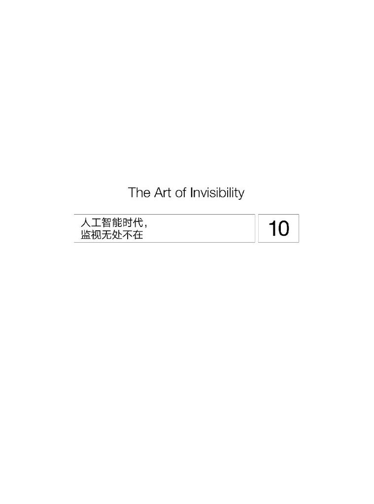

如果你像大多数人一样整天都带着手机，那你就没有隐身，而是处在监控之中——即使你的手机没有启用位置跟踪。比如说，你的系统是iOS 8.2或更早的版本，苹果会在飞行模式中关闭GPS，但如果你像大多数人一样有一个更新的版本，除非你采取了额外的步骤，否则GPS还是会保持开启，即使处于飞行模式中。为了知晓自己的移动运营商对自己的日常活动的了解程度，德国著名政治家马尔特·斯皮茨（Malte Spitz）向这家运营商发起了诉讼，法院命令该公司移交自己的记录。这些记录数量惊人。在短短6个月的时间里，这家公司就记录了85 000次他的位置，同时也记录了他拨打和接听的每个电话、另一方的电话号码以及每次通话的时长。换句话说，这些都是斯皮茨的手机产生的元数据。而且被记录的不只有语音通信，还有短信。

斯皮茨与其他组织合作，对这些数据进行了格式化并将其公之于众。有一个组织得出了如图10-1所示的每日总结。图中，早上的绿党会议是根据这家公司的手机记录中的经纬度确定的。

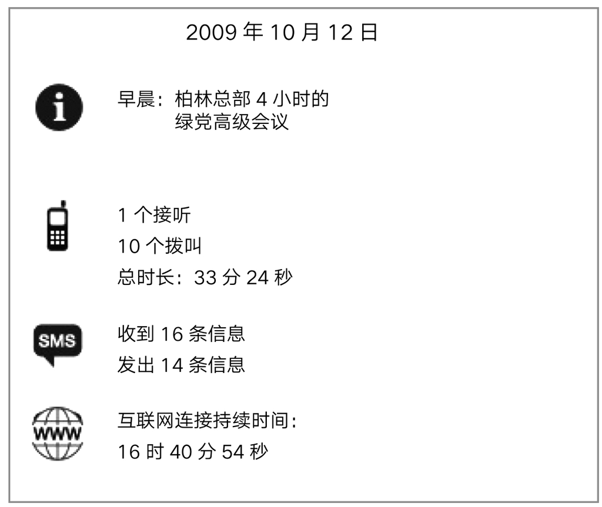

**图10-1 马尔特·斯皮茨在2009年10月12日的活动情况**

同样使用这些数据，另一个组织创建了一个动画地图，展示了斯皮茨在德国各地每分钟的活动情况，并且在他每次拨打电话或收到来电时都会显示一个闪动的符号，短短几天就能得到程度如此惊人的细节。<sup>1</sup>

针对斯皮茨收集的数据不是特例，当然这种情况也不仅限于德国。这只是一个引人注目的案例，说明了你的手机运营商所保留的数据之多。而且只需一纸法令就能使用这些数据。

2015年，美国联邦第四巡回上诉法院的一个案件就涉及了在美国境内使用相似的手机记录。这个案件中有两个在巴尔的摩抢劫了一家银行、一家7-11便利店、几家快餐餐厅和一家珠宝店的劫匪。警方让Sprint交出了主要嫌疑人的手机在此前221天的位置信息，从而将这些人与一系列犯罪联系到了一起，其中既有根据这些犯罪行为之间的接近程度判断的，也有根据这些嫌疑人与犯罪现场本身的接近程度判断的。

另一个由美国加利福尼亚北部地区地方法院听取的案件没有详细说明犯罪细节，但它也是围绕Verizon和AT&T所提供的目标的手机的“历史位置信息”展开的。美国公民自由联盟就该案发布了一份非当事人意见陈述，用他们的话说，这些数据“可以生成某个人的位置和运动的连续记录”。根据官方记录，当一位联邦法官在审理加利福尼亚州这个案件期间提到手机隐私时，该案的联邦检察官建议：“担心自己隐私的手机用户可以不带手机或者关闭手机。”

这似乎违反了保护美国人不受不合理搜查的宪法《第四修正案》。大多数人永远不会认同，只携带一部手机就等同于丧失了自己不被追踪的权利——但现在，携带手机确实意味着这一点。这两个案件都表明Verizon、AT&T和Sprint没有在隐私政策中向消费者说明位置跟踪的范围有多广。AT&T在2011年给国会的一封信中明确表示会将蜂窝数据存储5年，“以防发生计费纠纷”。<sup>2</sup>

会存储位置数据的不仅有运营商，还有供应商。比如你的谷歌账号就会保存你所有的安卓地理位置数据。如果你使用iPhone，苹果也会有你的数据记录。为了防止别人在这些设备上查看这些数据，以及防止数据备份到云上，你应该定期删除你的智能手机上的位置数据。在安卓设备上，进入“谷歌设置>位置信息>删除位置记录”。在iOS设备上，你还需要钻研一些；苹果没有让这个设置简单一点。进入“设置>隐私>定位服务”，然后向下滚动到“系统服务”，再向下滚动到“重要地点”，然后选择“清除最近历史”。

在谷歌这个案例中，除非你已经关闭了该功能，否则网上可用的地理位置数据就可以被用于重建你的活动情况。比如说，你日常大部分时间可能都待在同一个地方，但在你见客户或吃饭的时候可能会突然离开一段时间。更让人忧心的是，如果有人获得了你的谷歌或苹果账号的权限，那个人也许就能根据你花费了大部分时间的地方确定你住在哪里或你有哪些朋友，至少能弄清楚你的日常生活惯例可能是怎样的。

### 反监视，利用智能应用管理自己的隐私

所以很显然，现在就算是出去散个步这样的简单行为，也充满了被别人跟踪的机会。假设知道这一点后，你故意把你的手机留在家里，这样应该就能解决被跟踪的问题了吧？嗯，这要视情况而定。

你是否戴了一个Fitbit、Jawbone的UP智能手环或Nike+FuelBand这样的健康跟踪设备？如果没有，也许你戴了一只来自苹果、索尼或三星的智能手表。只要你戴了其中一种或两种东西，那你仍然会被跟踪。这些设备及其对应的应用是为记录你的活动而设计的，其中往往带有GPS信息，所以不管这些信息是实时广播还是稍后上传的，你都可以被跟踪到。

sousveillance这个词是由隐私倡导者史蒂夫·曼恩（Steve Mann）创造的，是surveillance（监视）一词的反面。sur是“之上”的意思；而sous是“之下”的意思。所以sousveillance所指的监控不是来自上面（比如被其他人或监控摄像头监控），而是来自下面，即那些我们携带的小设备，有的甚至可能佩戴在我们的身体上。

健康跟踪设备和智能手表会记录生物特征数据，比如你的心率、你走的步数甚至你的体温。苹果的应用商店里有大量可以在其手机和手表上跟踪健康状况的独立创造的应用。谷歌的Play商店也是一样。而且这些应用会将数据传回其公司，惊呆了吧！这些公司表面上说收集这些数据只是为了方便持有者在未来进行回顾，但它们也会分享这些数据，有时候甚至不会经过你的明确同意。

比如说，在2015年的环加州赛期间，这场自行车赛的参赛者可以识别出谁超过了他们，并且之后可以通过网络直接发消息给他们。当一个陌生人开始和你谈论你在比赛中的某个特定动作时——甚至可能你自己都不记得有这个动作，就会有点吓人了。

我就遇到过一件类似的事情。那时我在从洛杉矶前往拉斯维加斯的高速公路上，一个开宝马的家伙突然变道超车。他正忙着操作自己的手机，然后突然就变换了车道，在离我几厘米的地方来了个急转弯，把我给吓坏了。他差点就终结了我们两个人的生命。

我抓起我的手机，冒充执法人员拨打了车辆管理局的电话，查了他的车牌，然后车辆管理局把他的姓名、地址和社会保障号码给了我。然后我又假装成AirTouch的员工给AirTouch Cellular打了电话，并让他们搜索了他的社会保障号码所对应的蜂窝通信账号。这样我就得到了他的手机号码。

那个司机突然变道超车后不到5分钟，我就拨打了他的号码，他也接听了。我当时还在颤抖，生气又愤怒。我咆哮道：“嘿，你个白痴，我是5分钟前被你突然超车的那个人，你差点把我们两个都杀了。我可是车辆管理局的人，要是你再做一次刚才那种危险动作，我们就会吊销你的驾照！”

到现在，他肯定还不知道为什么高速公路上的某个人会有他的手机号码。我希望这个电话能够吓到他，让他变成一个更谨慎的驾驶者。但事实如何谁又知道呢。

然而，风水轮流转。我的AT&T移动账号也曾被某几个脚本小子通过社会工程手段入侵过一次。这些黑客假装成一家AT&T店的员工，给中西部的另一家AT&T店打了一个电话。他们说服店员重置了我的AT&T账号的电子邮箱地址，这样他们就可以重置我的网络密码并读取我账号的细节了，其中包含我的全部计费记录！

在环加州赛这个案例中，骑手们使用了Strava应用的Flyby功能来与其他Strava用户共享个人数据，这是默认开启的。在《福布斯》杂志的一篇采访报道中，Strava的国际营销总监加雷思·内特尔顿（Gareth Nettleton）表示：“Strava本质上是一个让运动员连接到全球社区的开放平台。但是，我们非常重视运动员的隐私，而且我们已经采取了一些举措，让运动员可以简单地管理他们的隐私。”

Strava确实提供了增强的隐私设置，让你能控制谁可以看到你的心率。你也可以创建设备隐私区域，这样别人就没法看到你住在哪里或在哪里工作了。在环加州赛上，客户可以选择退出Flyby功能，这样他们的活动在上传时就会被标记为“隐私”。

其他的健康跟踪设备和服务也提供了类似的隐私保护。你可能认为自己并不会骑车，而且在办公楼周围的人行道上跑步时也不会突然挡在别人前面，所以你不需要这些保护。这样想有什么害处呢？你还会做其他一些活动，一些隐私的活动，这些活动仍然会通过应用和网络分享出去，由此产生隐私问题。

就其本身而言，记录睡眠或爬了几层楼梯等行动可能并不会损害你的隐私，尤其是这些行动有特定的医疗保健目的，比如降低你的健康保险费。但是，当这些数据与其他数据结合在一起时，就能产生关于你的全面图景。而且这种情况所能暴露的信息量可能会超出你能接受的范围。

有一位戴了健康跟踪设备的用户在回顾自己的在线数据时发现，他在发生性行为时心率会有明显的增强。<sup>3</sup>事实上，Fitbit这家公司在其在线录入的活动列表中就会简要地报告性行为。尽管这些数据是匿名的，但终究还是可以通过谷歌搜索到；直到这件事被披露出来后，该公司才很快地将这些数据从谷歌搜索结果中移除。

有些人可能会想：“那又怎样？”确实，没什么大不了的。但当心率数据和地理位置等数据结合起来时，就可能会有危险了。*Fusion*记者卡什米尔·希尔（Kashmir Hill）将Fitbit数据用到了伦理上的极限，她想：“如果保险公司将你的活动数据与GPS位置信息结合起来，从而不仅能确定你在什么时候性爱，还能确定你在什么地方性爱，那会怎样呢？健康保险公司能够识别出每周在多个位置都有性爱的客户，然后根据他所谓的滥交行为认定这个人有更高的医疗风险吗？”

另一方面，Fitbit数据已经成功地在法庭案件中被用于证明之前无法验证的声明。在一个极端的案例中，一个女人说自己被强奸了，但Fitbit数据表明这是个谎言。<sup>4</sup>

对警方而言，这个当时正在宾夕法尼亚州兰开斯特出差的女人说她大概在午夜醒来，发现一个陌生人在她身上。她还声称她在挣扎逃脱的过程中丢掉了自己的Fitbit。当警察找到这个Fitbit后，女人同意让他们读取其中的数据，而这个设备却反映了不同的情况。显然这个女人一直醒着，而且整晚都在到处走动。据当地一家电视台报道，这个女人“因为向执法部门提交虚假报告、虚假公共安全报警和损坏证据而遭到起诉——据称她掀翻了家具并且在现场放了一把刀，以便让现场看起来像是她被某个入侵者强奸了一样”。

另一方面，活动跟踪器也可被用于支持残疾索赔。加拿大一家法律公司使用活动跟踪器数据证明了一位客户的工伤所导致的严重后果。这位客户将自己的Fitbit数据提供给了数据公司Vivametrica，该公司将从可穿戴设备中收集到的数据与一般人群的活动和健康数据进行比较，结果表明该客户的活动水平明显下降。卡尔加里市的McLeod Law有限责任公司的西蒙·穆勒（Simon Muller）对《福布斯》杂志说：“到目前为止，我们一直不得不依赖临床上的解读。现在我们将查看贯穿每一天的更长时间期限，而且我们会有实实在在的数据。”

即使你没有健康跟踪器，智能手表（比如三星的Galaxy Gear）也能以相似的方式危害你的隐私。如果你能在你的手腕上接受速览通知（比如短信、电子邮件和电话），那么其他人也有可能看到这些消息。

GoPro是一种可以固定在你的头盔或汽车仪表盘上的小型相机，可用于记录你运动过程的视频，近来GoPro的使用已经出现了极大的增长。但如果你忘记了登录GoPro移动应用的密码，会发生什么呢？以色列的一位研究者借用了他朋友的GoPro以及关联的移动应用，但他没有密码。就像电子邮箱一样，GoPro应用允许你重置密码。但是，其流程存在漏洞——自那以后已经改正了。在重置密码的过程中，GoPro会向你的电子邮箱发送一个链接，但实际上这个链接指向的是一个ZIP文件；你需要将其下载下来并放入该设备的SD卡中。该研究者打开了这个ZIP文件，发现了一个名为“settings”的文本文件，里面有该用户的无线凭证，包括该GoPro用于接入互联网的SSID和密码。该研究者发现，如果他将链接中的数字（8605145）改成另一个数（比如8604144），他就可以取得其他人的GoPro配置数据，其中包含他们的无线密码。

### 个人无人机，增强型的偷窥设备

忽然之间人们不得不面对一个事实：海滩上或公园里有人可能有一台照相机，而且实际上这个人也可能将你纳入某张照片的画框中。你可得仔细瞧好了。你必须负责任地行动。“这不仅改变了你对照相术的态度，也改变了你对自己被拍摄这件事本身的看法。”国际摄影中心前首席策展人布莱恩·沃利斯（Brian Wallis）说，“所以你不得不在晚餐上表演，在生日聚会上表演。”

我相信被人看着时，我们的行为确实会有所不同。当我们知道有一台相机正对着我们时，大部分人都会采取最好的行为，当然，毫不在意的人也总是会有的。

照相术的出现也影响了人们对自己隐私的看法。忽然之间，人们的不当行为可能就有视觉记录了。实际上，现在我们的执法人员都带有车载摄像头和随身摄像头，这样就能记录下人们面对法律时的行为了。而且现在还有人脸识别技术，你可以拍摄某人的一张照片，然后将其与他的Facebook档案匹配。我们现在还有自拍。

但1888年的时候，这种不间断的曝光还是一种让人震惊和不安的新奇事物。《哈特福德新闻报》（*Hartford Courant*）敲响了警钟：“稳重的市民不能以任何狂欢的方式放纵自己，因为有当场被抓并让自己的照片被在主日学校上学的孩子看到的风险。而想要与自己心爱的女孩做些亲密动作的年轻人，在进行过程中也必须一直用伞挡住自己。”

一些人并不喜欢这样的改变。19世纪80年代，美国有一群妇女在火车上砸了一台照相机，因为她们不想让这台照相机的主人拍摄她们的照片。英国也有一群男孩聚集在海滩上巡逻，威胁任何试图拍摄刚游完泳从海里出来的妇女的人。

塞缪尔·沃伦（Samuel Warren）和路易斯·布兰代斯（Louis Brandeis）（后者之后曾在美国最高法院任职）在19世纪90年代的一篇文章写道：“快速照相和报纸企业已经侵入例如隐私和家庭生活的神圣地带。”他们提议美国法律应当正式认定隐私，部分原因是为了遏制偷窥摄影的潮流，为任何侵扰行为追责。有几个州通过了这样的法律。

现在的几代人都伴随着快速照相的威胁而成长起来——宝丽来，有没有？但现在我们仍不得不面对无处不在的摄影。不管你去哪里，不管你允不允许，你都会被拍下视频。而且世界上任何地方的任何人都有可能读取这些影像。

在隐私方面，矛盾一直伴随着我们。一方面，我们非常珍视隐私，将其视为我们的权利，并且认为它与我们的自由和独立息息相关：在财产方面以及关着的门后所做的任何事情不都应该保持隐私吗？另一方面，我们对一些事情有着强烈的好奇。我们现在有办法满足这样的好奇心了，这些方法是之前无法想象的。

你曾经好奇过街对面围栏里你邻居家的后院是什么样子吗？技术也许能帮助几乎任何人找到这个问题的答案。如今，3D Robotics和CyPhy这样的无人机公司让任何普通人都能轻松拥有自己的无人机，比如我就有一架大疆Phantom 4无人机。无人机是远程控制的飞行器，而且比你过去在RadioShack买的那种飞行器要复杂精细得多。几乎所有无人机都带有小型的视频摄像机。它们能为你提供一种观看世界的新方式。某些无人机也可以通过你的手机来控制。

个人无人机是增强型的摄影设备。如果你可以悬浮在地面上空数百米的地方，那么几乎没什么能逃出你的眼睛了。

目前保险行业已经将无人机用于商业目的。想一想，如果你是一位保险理算员，需要了解你打算承保的一处房地产的状况，那你就可以让一架无人机绕着它飞，这样既可以在有权进入之前通过眼睛检查，也可以创造一个永久性记录以备以后查找。你可以让它飞得很高，然后向下看，从而获得之前只能通过直升机得到的那种画面。

个人无人机现在也是监视我们的邻居的选择之一；我们只需要“飞”到别人楼顶上向下看就行了。也许这位邻居有一个游泳池。也许这位邻居喜欢裸泳。情况已经变得很复杂了：我们对自己的家庭和财产有隐私预期，现在却受到了挑战。比如，谷歌会在谷歌街景和谷歌地球中掩盖人脸和车牌号等个人信息，但使用私人无人机的邻居可不会给你任何保证——尽管你可以尝试友好地要求他不要在你的后院上飞。配置有视频摄录功能的无人机帮你将谷歌地球和谷歌街景结合到了一起。

现在已经有一些相关法规了。比如，联邦航空管理局规定无人机不能离开操作者的视线，不能在距机场一定距离的范围内飞行，不能超过特定的飞行高度。<sup>5</sup>有一个名叫B4UFLY的应用可以帮你确定哪里可以飞你的无人机。<sup>6</sup>另外，为了应对无人机的商业应用，几个州已经通过了限制或严格限制使用无人机的法律。在得克萨斯州，普通公民不能使用无人机，尽管也有例外——包括一项针对房地产经纪人的例外。科罗拉多州对无人机的态度可能是最自由的，这里的居民可以合法地射击天上的无人机。

美国政府至少应该要求无人机爱好者注册他们的玩具。在我居住的洛杉矶，某个人用一架无人机撞击了西好莱坞的电线，就在靠近拉拉比街和日落大道交会处的地方。如果这架无人机注册了，当局也许就能知道是谁给700多人造成了断电数小时的不便，又让数十名电力公司员工不得不在夜里工作以恢复该地区的供电。

### 你的隐私无处可逃

零售商店越来越想了解它们的客户。某种手机IMSI捕获器（IMSI catcher）实际上就是一种真正有效的方法。当你走进一家商店时，该IMSI捕获器就能获取你的手机的信息，并通过某种方式得到你的手机号码。根据这个信息，系统就能查询大量数据库，从而建立起一个你的资料档案。实体零售店还在使用人脸识别技术。你可以将其看作是一种超大型的沃尔玛迎宾员。

在不久的将来，“你好，凯文”或许就将成为我从店员那里得到的标准问候，即使我之前可能从没去过那家店。你的零售体验个性化也是另一种形式的监控，尽管非常微妙。我们再也不能匿名购物了。

2015年6月，美国国会通过了《自由法案》，这是《爱国者法案》的一个修订版，增加了一些隐私保护条款。在该法案通过仅仅2周之后，9个消费者隐私团体（其中一些为了支持《自由法案》而进行了大量游说）就对几家大型零售商表达了失望，并退出了关于限制使用人脸识别的协商谈判。

他们协商谈判的问题是：在消费者可被扫描之前，是否应该默认消费者必定给出了许可。这听起来很合理，但参与这一协商谈判的主要零售组织中没有一家愿意在这一点上让步。据它们称，如果你走进了它们的店里，那么扫描和识别你就是合理的。

有些人在走进店里时希望得到那样的个人关注，但很多人都只会觉得这让人不安。这些商店对此有不同的看法。它们不想给消费者退出的权利，因为它们想抓住已知的商店窃贼，如果可以选择，消费者就能直接退出了。如果自动人脸识别得到了应用，已知的商店窃贼在进入商店那一刻就会被识别出来。

消费者怎么看？至少英国有70%的受访者认为，在商店中使用人脸识别技术“太可怕了”。包括伊利诺伊州在内的美国一些州已经自己动手监管生物特征数据的收集和存储了。现在已经出现了基于这些法规的诉讼。比如，芝加哥一名男子起诉了Facebook，因为他没有明确许可该网络服务可使用人脸识别技术识别其他人的照片中的他。

人脸识别可以仅根据一个人的图像就识别出他的身份。但如果你已经知道这个人是谁，而只想确定其是否在应该在的位置，又该如何呢？这是人脸识别的另一个潜在用途。

摩西·格林斯潘（Moshe Greenshpan）是人脸识别公司Face-Six的CEO，该公司在以色列和美国拉斯维加斯都有办公室。该公司的软件Churchix有教堂点名等功能。其想法是帮助教堂识别不常来教堂做礼拜的教友，以便鼓励他们更常来；也要识别经常来教堂做礼拜的教友，以便鼓励他们向教堂捐更多钱。

Face-Six说全世界至少有30家教堂正在使用该公司的技术。所有教堂只需上传教友的高质量照片即可。然后该系统就会在各种服务和公共集会上寻找他们。

当被问及这些教堂是否会告诉它们的教友他们正在被跟踪时，格林斯潘告诉*Fusion*：“我认为教堂没有告诉人们。我们鼓励它们这样做，但我认为它们不会这样做。”<sup>7</sup>

哈佛法学院伯克曼互联网与社会研究中心主任乔纳森·齐特林（Jonathan Zittrain）曾开玩笑说人类需要一个“不要跟踪”标签，就像一些特定的网站所使用的标签那样。这能让想要退出的人不会出现在人脸识别数据库中。为了实现这一目标，日本国立情报学研究所创造了一种商用的“隐私护镜”（privacy visor）。这种售价约240美元的眼镜可以发出仅对摄像机可见的光。这些可被摄像机感知的光在眼睛周围射出，可以阻碍人脸识别系统。据早期测试者说，这种眼镜90%的时间都能成功。唯一的使用警告似乎是不适合在驾驶或骑车时使用。它们或许不够时尚，但它们能帮你在公共场所完美地行使隐私权。

现在你知道在外面时你的隐私可能会受到侵害，你可能感觉在你的车里、家里甚至办公室里会有更安全的隐私。很不幸，事实并非如此。我将在接下来几章中解释原因。

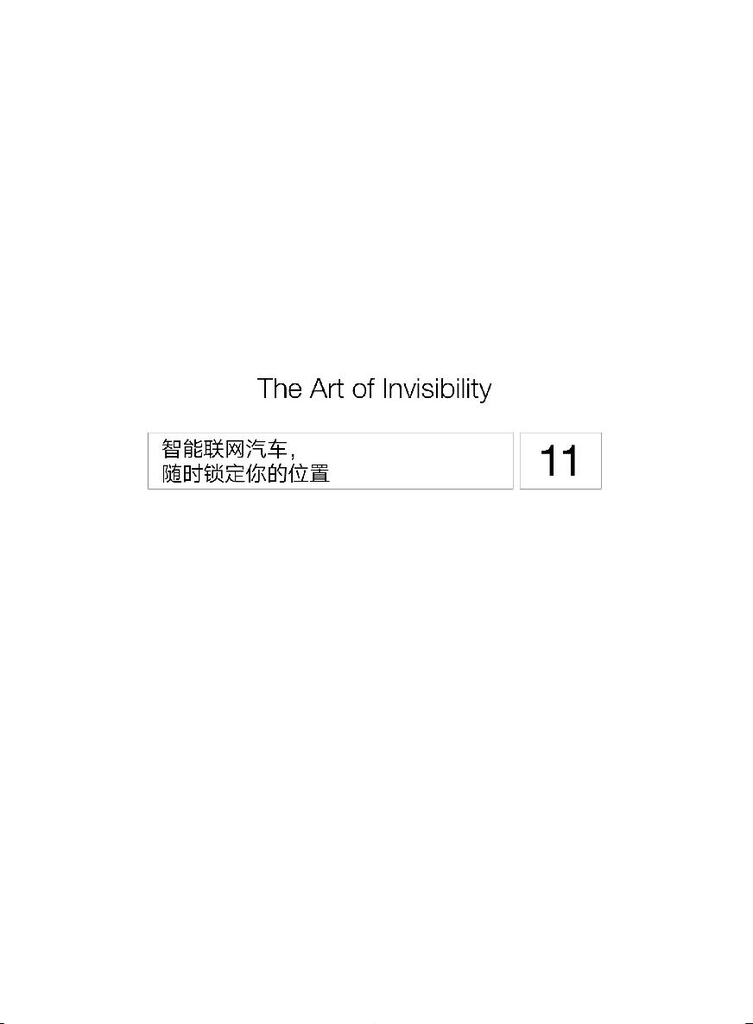

研究者查理·米勒（Charlie Miller）和克里斯·瓦拉塞克（Chris Valasek）是入侵汽车的老手了。之前两人就入侵过一辆丰田普锐斯——但他们是坐在汽车后座上，通过与汽车的实体连接完成的。然后到了2015年夏季，米勒和瓦拉塞克又成功接管了一辆吉普自由光的主要控制权，而当时这辆车正在圣路易斯市的高速公路上，以110公里每小时的速度行驶。他们可以在不靠近车辆的任何地方远程控制一辆车。<sup>1</sup>

这里提到的这辆吉普确实有一位司机——《连线》杂志的记者安迪·格林伯格（Andy Greenberg）。研究者事先告诉过格林伯格：不管发生什么，不要惊慌。事实证明，即使对知道自己的车将被入侵的人来说，这个要求也还是太高了。

格林伯格写下了这段经历：“我的油门突然就停止工作了。我疯狂地踩踏板，看着转速上升，但这辆吉普还是减去了一半的速度，然后就变成了爬行。事情发生的时候我已经进入了一座高架桥，两边没有路肩可以逃跑。这个实验已经不再有趣了。”

这两位研究者之后遭受了一些批评，说他们“鲁莽”和“危险”。格林伯格的吉普当时正在公共道路上行驶，而不是在测试道路上，所以密苏里州的执法部门在本书写作时仍然在考虑起诉米勒和瓦拉塞克——也可能还会起诉格林伯格。

远程入侵联网的汽车已经被谈论了很多年，但米勒和瓦拉塞克的实验才真正让汽车行业对此重视起来。不管这是“炫技的黑客入侵”还是合规的研究，它都让汽车制造商开始认真思考网络安全了——以及思考国会是否应该禁止入侵汽车。<sup>2</sup>

其他研究者已经表明，他们可以通过拦截并分析汽车的车载计算机和汽车制造商系统的GSM或CDMA流量，来对控制汽车的协议进行反向工程。这些研究者可以通过发送短信息来欺骗汽车控制系统，从而锁定和解锁车门。有人甚至还能使用同样的方法劫持远程启动功能。但米勒和瓦拉塞克首次通过远程的方式完全控制了一辆汽车，而且他们宣称也能使用同样的方法接管位于其他州的汽车。

也许米勒和瓦拉塞克的实验最重要的结果是，克莱斯勒因为一个编程问题召回了超过140万辆汽车——这是第一次由于此种原因的召回。在过渡期间，克莱斯勒还暂时中断了受影响的汽车与Sprint网络的连接，这是这些汽车原本用于车载通信（汽车收集的并与制造商实时共享的数据）的网络。米勒和瓦拉塞克在DEF CON 23上告诉一位观众，他们早就意识到可以接管位于其他州的汽车，但他们知道这是不道德的。作为替代，他们在米勒的家乡与格林伯格一起进行了他们的控制实验。

在这一章中，我将讨论我们驾驶的汽车、搭乘的列车和用于支持日常通勤的移动应用在很多方面都很容易遭到网络攻击，更不要说我们的联网汽车在生活中给隐私造成的诸多侵害了。

### 上帝视角，被跟踪的行程

当*BuzzFeed*的记者约翰娜·布伊扬（Johana Bhuiyan）搭乘优步的车到达这个叫车服务公司的纽约办公室时，该公司的总经理乔希·莫勒尔（Josh Mohrer）已经在等着她了。“你来了，”他拿着他的iPhone说道，“我在监视你。”对他们的采访来说，这是一个不祥的开始，毕竟这次采访涉及的内容就包含消费者隐私。

布伊扬的故事在2014年11月被公布，在此之前，优步公司之外很少有人知道存在上帝视角（God View）；这是优步用于跟踪其成千上万名合约司机及他们的客户的位置的工具，而且全部都是实时的。

正如我前面提到的那样，应用通常会向用户请求各种权限，包括读取他们的地理位置数据的权限。优步甚至还更进一步：它要求读取你的大概位置（Wi-Fi）和精确位置（GPS）、你的通讯录访问权，而且还不允许你的移动设备休眠（这样它就能不断标记你的位置）。

据说布伊扬当面就对莫勒尔说了她没有允许该公司在任何时间和任何地点跟踪她。但她确实允许了，尽管可能并没有明确允许。她在将该服务下载到自己的移动设备时，在用户协议中同意了该许可。那次会面之后，莫勒尔通过电子邮件向布伊扬发送了一些她近期优步行程的日志。

优步会为每位用户编写一个个人档案，其中记录了他的每一个行程。如果这个数据库不安全，可就糟糕了。在安全业务中，优步的这种数据库被称为蜜罐（honeypot），会引来各种各样的窥探，从美国政府到外国黑客。<sup>3</sup>

2015年，优步对其隐私政策进行了一些修改——在某些情况下对消费者有害。优步现在会收集所有在美国的用户的地理位置数据——即使该应用仅在后台运行，即使卫星和蜂窝通信都关闭了，也照样会收集。优步说自己会使用Wi-Fi和IP地址“离线地”跟踪用户。这意味着它会在你的移动设备上进行无声的间谍活动。但是，该公司并未说明为什么需要这种功能。<sup>4</sup>

优步也没有完全解释它为什么需要上帝视角。一方面，据该公司的隐私政策称：“优步有严格的政策，禁止所有层级的员工访问乘客或司机的数据。本政策的唯一例外是数量有限的一些合规的业务。”合规的业务可能包括监控涉嫌欺诈的账号和解决司机的问题（比如，丢失连接）。其中可能并没有包含跟踪记者的行程。

你可能认为优步会让其用户有权删除跟踪信息。事实并非如此。而且如果你在阅读完这些内容后从你的手机上删除了该应用，好吧，猜猜会怎么样？这些数据仍然还保存在优步内部。<sup>5</sup>

根据修订后的隐私政策，优步还会收集你的通讯录信息。如果你使用iPhone，你可以进入设置修改你的联系人共享偏好。如果你使用的是安卓设备，就没得选了。

优步的代表声称该公司目前并未收集这种消费者数据。但是，由于现有用户已经同意了优步的隐私政策且新用户也必须同意，所以通过将数据收集纳入隐私政策中，该公司确保了它在任何时候都可以推出这些功能。而用户不会得到任何补偿。

优步的上帝视角也许足以让你怀念起常规的老式出租车。过去的时候，你会钻进一辆出租车，说出你的目的地，到达之后用现金为这段旅程付费。换句话说，你的行程几乎是完全匿名的。

随着21世纪初信用卡普遍被接受的情况出现，大量日常交易都已经变得可被追溯了，所以也许某个地方就有你搭乘出租车的记录——也许并不存在于某个特定司机或公司那里，但肯定在你的信用卡公司手中。我曾在20世纪90年代当过私人调查员，那时我就可以通过获取目标的信用卡交易而搞清楚他们的活动情况。只需要看一看结算单，就能知道上周你在纽约市搭乘过一辆出租车并且为该行程支付了54美元。

出租车在大约2010年前后开始使用GPS数据。现在的出租车公司也会知道你的上车和下车位置、你的车费金额，而且也许还能知道与你的行程相关的信用卡号码。纽约、旧金山和其他支持政府开放数据运动的城市会将这些保密，并向研究人员提供丰富且匿名的数据集。只要里面不包含名字，公开这些匿名的数据又会有什么损害呢？

2013年，美国西北大学当时的一位研究生安东尼·托卡尔（Anthony Tockar）正在一家名叫Neustar的公司实习，他研究了纽约市出租车和轿车委员会公开发布的匿名元数据。这个数据集包含其出租车车队中每辆车在上一年中的每个行程记录，其中包括出租车编号、乘客上下车的时间和位置、车费和小费金额，以及这些出租车的许可证和牌照号码的匿名（经过哈希化<sup>(28)</sup>）版本。这个数据集本身并不会很让人感兴趣。不幸的是，解算这个案例中的哈希值是相当容易的。

但是，当你将这个公开数据集与其他数据集结合起来时，你就会开始全面了解实际发生的情况。在这个案例中，托卡尔可以确定上一年中布莱德利·库珀（Bradley Cooper）和杰西卡·阿尔芭（Jessica Alba）等特定名人在纽约市的什么地方搭乘过出租车。他是如何实现这一飞跃的？

他已经有地理位置数据了，所以他知道这些出租车是在什么地方和什么时候让它们的乘客上下车的，但他必须更进一步确定在某辆出租车中的人是谁。所以他将纽约市出租车和轿车委员会的元数据与普通小报网站的网络照片结合到了一起。这是一个狗仔队的数据库。

想一想，狗仔队常常会在名人坐进或走出出租车时拍摄照片。在这些案例中，我们往往可以在图像中看到出租车独有的牌照号码。就印在每辆出租车的侧面上。所以，比如说与布莱德利·库珀一起被拍下的出租车号码可以用于匹配那个公开提供的数据集，从而得到上下车位置以及车费和小费金额。

幸运的是，并不是我们所有人都有狗仔队跟着。但这并不意味着没有其他用于跟踪我们行程的方式。也许你并不乘坐出租车，那么还有其他可以确定你的位置的方式吗？有。即使你搭乘公共交通工具也一样。

### 准确率高达92%，匿名搭乘时代终结

如果你乘坐公交车、火车或渡船上班，那你就再也没法隐身于芸芸众生之中了。交通运输系统正在实验使用移动应用和近场通信（near field communication，简称NFC）来标记上下公共交通工具的乘客。NFC是一种短距离的无线电信号，往往需要实体接触。Apple Pay、Android Pay和Samsung Pay全都使用NFC，让寻找零钱成了历史。

假设你有一部启用了NFC的手机，并且也安装了当地运输管理机构的应用。这个应用需要连接到你的银行账号或信用卡，这样你就总是可以搭乘任何公交车、火车或渡船了，而不用担心账号余额变成负数。这种与你的信用卡号码之间的连接如果没有使用令牌或占位符数字掩盖，就可能会向该运输管理机构揭示你的身份。使用令牌替代你的信用卡号码是苹果、安卓和三星提供的一个新选择。这样商家（在这个案例中即为运输管理机构）就只能拿到一个令牌，而无法得到你的真实信用卡号码。在不久的将来，使用令牌将能减少数据泄露对信用卡的影响，因为犯罪分子将会需要两个数据库：令牌以及令牌背后的真实信用卡号码。

但假设你没使用启用了NFC的手机，而用的是交通卡，比如波士顿的CharlieCard卡、华盛顿特区的SmarTrip卡和旧金山的Clipper卡。这些卡都使用了令牌来提醒接收设备（不管是旋杆门还是检票箱）你的余额是否足够搭乘该公交车、火车或渡船。但是，交通运输系统并没在后端使用令牌。交通卡本身在其磁条上只有一个账号号码——不是你的信用卡信息。如果该运输管理机构的后端遭遇数据泄露，你的信用卡或银行信息就可能会暴露。另外，有的交通运输系统需要你在网上注册它们的卡，这样它们就可以向你发送电子邮件，也就意味着你的电子邮箱地址可能会在未来的黑客攻击中泄露。不论哪种方式，匿名乘坐公交车的时代在很大程度上已经一去不复返了，除非你购买交通卡时用的是现金，而非信用卡。<sup>6</sup>

对执法机构而言，这样的发展大有裨益。因为这些交通卡公司是第三方私有的，而不归政府所有，所以它们可以设定任何它们想要的数据共享规则，不仅能将其分享给执法部门，还能分享给处理民事案件的律师——如果你的前任想骚扰你。

所以某个正在查看运输管理机构日志的人可能知道某个人在某个时间经过了某个地铁站，但他可能不知道他的目标上了哪辆列车，尤其当这个车站是几条线的中转站时。要是你的移动设备可以解决这个问题，能让人知道你之后搭乘了哪辆列车并借此推断你的目的地呢？

中国南京大学的研究者决定回答这个问题，他们的研究重点是我们的手机里被称为加速度计的东西。每个移动设备里面都有一个。这是一种用于确定你的设备的方向的微型芯片——看你是水平还是竖直地拿着你的设备。这些芯片非常敏感，以至于这些研究者决定在他们的计算中仅使用加速度计数据。计算结果足够确定，表明他们可以准确预测用户正在搭乘的地铁列车。这是因为大多数地铁线都有转弯，这些转弯会对加速度计产生影响。另外，站与站之间的行驶时长也很重要——你只需要看看地图就知道原因了。他们的预测的准确度会随乘客经过的车站数量的增加而提升。这些研究者声称，他们的方法具有92%的准确率。

### 自动车牌识别，新技术正在侵蚀你的匿名性

假设你有一辆旧型号的汽车并且自己开车上班。你可能就认为你是隐身的了——只是每天在路上的100万辆车中的一辆。你可能是对的。但新技术正在侵蚀你的匿名性，即使这些技术并不在汽车本身之中。很可能只要某个人花点功夫，就依然能相当快地识别出高速公路上呼啸而过的你。

在旧金山，市交通局已经开始使用FasTrak收费系统来跟踪使用了FasTrak的汽车在城市里面的活动情况了，该系统能让你轻松通过8座湾区大桥中的任意一座。使用类似收费桥梁用于读取你汽车中的FasTrak（或E-ZPass）设备的技术，该市开始在用户到处寻找停车位置时搜索这些设备。但官员们感兴趣的并不总是你的活动，而是停车位——大多数停车位都配备了电子停车收费器。停车多的车位可能收取更高的费用。该市可以通过无线方式调节特定收费器的价格——包括临近热门活动的收费器。

此外，在2014年，官员们决定金门大桥不再使用人工收费员了，所以每个人（甚至游客）都需要以电子方式进行支付或以邮件的形式接收账单。管理者如何知道该向哪里寄送你的账单呢？他们会在你通过收费站时拍摄你的车牌。常出问题的交叉路口也会使用这种车牌照相来抓闯红灯的车。而且警方也在越来越多地使用相似的策略巡逻停车场和住宅车道。

警方每天都会使用自动车牌识别技术即ALPR来被动跟踪车辆的活动，可以拍摄你的汽车车牌并将数据存储起来。根据警方的政策，有时候数据会保存数年时间。ALPR相机会扫描和读取经过它们眼前的每个车牌，不管这辆车是否与犯罪有关联。

表面上ALPR技术主要用于定位被盗的汽车、寻找通缉犯和协助安珀警报<sup>(29)</sup>。这项技术要用到固定在巡逻车顶上的三台相机，这些相机连接到车内的一个计算机屏幕上。该系统还会进一步连接到一个司法部数据库，其中包含了被盗车辆以及与犯罪相关的车辆的车牌记录。在警官的行驶过程中，ALPR技术每秒可扫描多达60张车牌。如果某张扫描到的车牌与司法部数据库中的某个车牌号匹配，那么该警官就会收到一个警报，而且既有图像又有声音。

《华尔街日报》在2012年首次报道了车牌识别技术。反对或质疑ALPR技术的人关注的问题并不是该系统本身，而是这些数据会被保存多长时间以及为什么有的执法机构不会发布它，甚至不会告诉正被追踪的汽车的主人。这是一种让人不安的工具，警察可以用它来确定你去过的地方。

负责美国公民自由联盟的语音、隐私和技术项目的本内特·斯泰因（Bennett Stein）指出：“自动车牌读取器是一种精妙的跟踪司机位置的方式，而且随着时间的推移、数据的累积，它们就能得到人们生活的详细图景。”

加利福尼亚州一名男子曾经发起了一项公共记录请求，他的车牌被拍摄的照片数量（超过100张）让他感到不安。其中大多数照片都是在大桥上或其他非常公共的地方拍摄的。但是有一张照片上可以看到他和他的女儿正从他们家的汽车里出来，当时这辆车停在自家的车道上。请注意，这个人并不是某项犯罪的嫌疑人。美国公民自由联盟获得的档案表明，甚至FBI的总法律顾问办公室也曾质疑过在缺乏明确的政策的情况下使用ALPR的问题。

不过，要查看一些ALPR数据，并不是必须发起公共记录请求才行。据电子前线基金会称，任何人都可以在网上获取来自超过100台ALPR相机的图像，只要一个浏览器就足够了。电子前线基金会在公开自己的发现之前已经与执法部门合作纠正了这个数据泄露问题。电子前线基金会说不只是这100多个案例有这种错误配置，并敦促全国各地的执法部门撤下或限制发布在互联网上的内容。但在本书写作时，如果你在搜索窗口输入正确的查询，仍然有可能得到许多社区的车牌照片访问权限。一位研究者在一周内就发现了超过64 000张车牌照片和它们对应的位置数据点。<sup>7</sup>

### 内置GPS&无线连接，租用汽车的两大安全陷阱

也许你自己没有车，只是偶尔租一辆。因为你在租车时必须提供所有个人信息和信用卡信息，所以你还是没有隐身。此外，现在大多数租用的汽车都内置了GPS。我知道。我发现这一点的过程很艰辛。

当你的汽车在维修时，你会从经销商那里得到一辆租用的车，你通常会同意不将其开出州界。经销商希望这辆车保持在它被借用的那个州内行驶。这个规则主要关乎他们的保险，而不是你的。

我就遇到过这种事。我将我的车带到了拉斯维加斯一家雷克萨斯经销商那里进行维修，他们让我使用一辆租用车。那时已经过了这家经销商结束营业的时间，我读也没读就签了那些文件，主要是因为当时服务助理一直在催促我。之后，为了一个顾问工作，我开着那辆车去了加利福尼亚州北部的湾区。这时候那个服务助理就给我打电话了，他问：“你在哪里？”我说：“加利福尼亚的圣拉蒙。”他说：“是啊，我们看到了。”然后他针对将车带出州界一事对我发出了严厉的警告。显然我快速签下的那个租车协议规定我不能将这辆车带出内华达州。

现今当你租用或借用汽车时，你可能很想将你的无线设备与车载娱乐系统配对，以便重新创造你在家里的那种音频体验。当然这会产生一些直接的隐私问题，因为这不是你的车。所以当你将汽车归还给租赁商时，你的车载信息娱乐数据又会怎样呢？

在你将你的设备与不属于你的汽车配对之前，先研究看看它的娱乐系统。也许点击手机设置就能看到之前用户的设备和（或）名字列在蓝牙列表中。想一想你是不是也想加入那个列表。

也就是说，当你离开这辆车时，你的数据并不会就此消失。你必须自己删除这些数据。

你可能会想：“将我最喜欢的乐曲分享给其他人能有什么危害呢？”问题是你分享出去的不只有你的音乐。当大多数手机设备连接到车载信息娱乐系统时，它们也会自动将你的联系人链接到该车的系统。厂商假设你可能需要在驾驶时拨打免提电话，所以将你的联系人存储在汽车中会让其简单得多。问题是这不是你的车。

Covisint公司的首席安全官戴维·米勒（David Miller）说：“当我租车时，最不会去做的就是配对我的手机。它会下载我的所有联系人，因为这就是它想做的事。在大多数租用的汽车里，如果之前有人配对过，那么你进入系统就能看到他们的联系人。”

当你最后卖掉你的汽车时，情况也是如此。今天的汽车让你在路上时也能访问你的数字世界。想要查看Twitter吗？想要在Facebook上发帖吗？今天的汽车与你的传统个人电脑和手机有一个越来越相似的地方：它们包含了个人数据，你应该在出售这些机器或设备之前删除这些数据。

在安全领域工作会让你养成三思而后行的习惯，即使那只是普通的交易。米勒说：“这段时间里，我的汽车与我的全部生活一直都连接在一起，然后在第五年我卖掉了它——我该怎样断开它与我的全部生活的连接呢？我不想让买这辆车的人看到我的Facebook好友，所以必须撤销服务。比起提供服务，安全领域的人对撤销服务方面的安全漏洞要感兴趣得多。”

而且正如你在你的移动设备上做的那样，你也需要用密码保护你的汽车。只是在本书写作时，还没有什么可用的机制能让你用密码锁定你的信息娱乐系统。而且要删除你在汽车中设置了多年的账号也不容易——不同的制造商、产品和型号的方法各有不同。也许这种情况会改变，某人可能会发明一种一键删除你的汽车上整个用户档案的方法。但在那之前，在卖掉汽车之后至少要上网修改一下你的社交媒体密码。

### 特斯拉，带轮子的计算机

特斯拉也许是“带轮子的计算机”的最佳范例了，这是当前最先进的全电动汽车。2015年6月，特斯拉完成了一件有里程碑意义的事：特斯拉汽车的全球总行驶里程超过了16亿公里。

我就开了一辆特斯拉。那是很棒的车，但由于它们有复杂的仪表盘和持续不断的蜂窝通信，所以也引出了一些在数据收集方面的问题。

当你拥有一辆特斯拉时，你会收到一份同意书。你可以选择是否让特斯拉公司通过无线通信系统记录关于你的汽车的任何信息。你可以通过仪表盘上的触控屏开启或禁止与特斯拉公司共享你的个人数据。有观点认为用户数据可以帮助特斯拉在未来打造更好的汽车，而且很多人都接受这个看法。

根据特斯拉的隐私政策，该公司可能会收集车辆识别号码、速度信息、里程表读数、电池使用信息、电池充电历史、关于电气系统功能的信息、软件版本信息、信息娱乐系统数据和安全相关数据（包括车辆的SRS系统、制动器、安全和电子制动系统的相关信息）等信息，以协助分析车辆的性能。特斯拉表示，它们可能会面对面（比如在预约服务期间）或通过远程访问的方式收集这些信息。

它们打印出的政策中就是这么说的。

实际上，它们还能随时确定你的汽车的位置和状态。特斯拉一直都没怎么向媒体说过会实时地收集什么数据以及如何使用这些数据。特斯拉就像优步一样，坐在上帝的位置上，知道关于每辆车的一切以及它们在任何时候的位置。

如果这让你感到不安，你可以联系特斯拉公司并选择退出其远程信息服务项目。但是如果这么做了，你就会错过包含安全修复和新功能的自动软件更新。

安全领域自然对特斯拉兴趣浓厚，而且独立安全研究者尼塔什·汉贾尼（Nitesh Dhanjani）已经找到了一些问题。尽管他和我一样，都同意特斯拉Model S是一款很棒的汽车和出色的创新产品，但汉贾尼发现特斯拉使用了一种相对弱的单因素认证系统来远程访问该车的系统。特斯拉的网站和应用都没有限制尝试登录用户账号的次数，这意味着攻击者也许可以暴力破解用户的密码，也就意味着第三方也可以（假设你的密码已被破解）登录并使用特斯拉API来查看你的车的位置。攻击者还可以远程登录到特斯拉应用并控制该车的系统——空调、灯光等，尽管该车必须保持不动。

在本书写作时，汉贾尼的大部分担忧都已经被特斯拉解决，但这个情况只是一个示例，说明为了保护汽车的安全，当今的汽车制造商需要做的事情多了很多。仅仅提供一个用于远程启动和检查汽车状态的应用还不够好，必须得保证安全。最新的更新是一个名叫Summon的功能，让你可以告诉车子自己开出车库或在狭窄的位置停车。Summon未来还能让车子到全国的任何地方去接你，有点像《霹雳游侠》这个老电视节目。

特斯拉在否认《纽约时报》的一篇负面报道时，承认了它们所拥有的数据的力量。《纽约时报》记者约翰·布罗德（John Broder）说他的特斯拉Model S曾经出过故障，将他困在了路上。特斯拉在一篇博客中反驳说它们确认了一些让人质疑布罗德的故事版本的数据点。比如说，特斯拉指出布罗德的驾驶速度范围为104公里／小时到130公里／小时，车内温度被设置为22摄氏度。<sup>8</sup>据《福布斯》杂志报道：“Model S中的数据记录器知道汽车内的温度设置、整个行程中的电池电量、汽车每分钟的速度和驶过的确切路径——详细到知道这位汽车测评人在汽车电量几乎快要耗尽时还在停车场里开着转圈。”

美国在2015年后生产的所有用于销售的汽车中，远程信息服务功能都是车内黑匣子的合乎逻辑的延伸。但车内黑匣子根本不是新东西。它们的出现可以追溯到20世纪70年代首次引入安全气囊的时候。在发生撞车时，那时候的人还会受到来自气囊的威胁生命的伤害，甚至有的人因为气囊撞击他们身体的力量过大而丧命。在一些案例中，如果汽车没有装配这些气囊，里面的乘客可能到今天还活着。为了进行改进，工程师需要撞车发生前后气囊部署的相关数据，这些数据是通过气囊的传感和诊断模块收集的。然而，直到2017年车主们才被告知汽车中的这些传感器会记录有关他们驾驶的数据。

车内黑匣子类似于飞机黑匣子，是由加速度的突然变化触发的，它们只会记录加速度突然改变事件的最近几秒钟，比如突然加速、转弯和急刹车。

但是我们很容易想到，这些黑匣子会收集并通过蜂窝连接实时传输更多种类的数据。想象一下，未来按3～5天时间长度收集的数据既可以存储在汽车上，也可以存储在云中。你不必再尽力描述当你的汽车以56公里／小时或更快的速度行驶时发出的嗡嗡噪声，只需要让修理师读取记录的数据即可。真正的问题是，能读取这些数据的还有谁？即使是特斯拉也承认其收集的数据可能会被第三方使用。

如果这个第三方是你的银行呢？如果该银行与你的汽车制造商有一个协议，那么它就可以跟踪你的驾驶能力并据此评估你未来汽车贷款的资格。你的健康保险公司也可能做同样的事，甚至你的汽车保险公司。美国联邦政府也许有必要对谁拥有来自你的汽车的数据，以及你拥有怎样的保持这些数据私密的权利进行评估。

目前你对此还基本上无能为力，但未来值得关注。

### 如何对抗联网的隐私危机

即使你没有特斯拉汽车，你的汽车制造商可能也提供了一个应用，让你可以开启车门、发动引擎或者在你的汽车上进行某些诊断。一位研究者表明，现在已经有技术可以入侵这些在汽车、云和应用之间传播的信号并将其用于跟踪目标车辆、毫不费力地解锁车辆、触发鸣笛或警报甚至控制引擎。除了将汽车挂挡开走——那仍然需要该驾驶者的钥匙，某个黑客几乎能做到所有事情。不过，我后来找到了禁用特斯拉的遥控钥匙的方法，可以让特斯拉完全禁用。通过使用315 MHz的小型无线电发射器，你可以让遥控钥匙无法被检测到，从而禁用汽车。

因在2005年开发了针对Myspace的Samy蠕虫病毒而广为人知的安全研究者萨米·卡姆卡尔在DEF CON 23上演讲时演示了一个他打造的名叫OwnStar的设备，该设备可以伪装成一个已知的汽车网络。比如说，他可以使用该设备打开你的启用了OnStar的通用汽车。该设备会伪装成汽车的无线接入点，并自动将不知情的驾驶者的移动设备与这个新接入点关联起来（假设该驾驶者之前已经关联了原来的接入点）。无论何时，不管是在iOS还是安卓上，只要该用户启动自己的OnStar移动应用，OwnStar代码就会利用该应用中的一个漏洞来窃取该驾驶者的OnStar凭证。卡姆卡尔说：“只要你在我的网络上并且打开了该应用，我就开始接管了。”

在取得了用户登录RemoteLink（OnStar所用的软件）的凭证并听到了锁定或解锁的哔哔声之后，攻击者可以追踪到停在拥挤停车场中的汽车，打开它，偷走里面任何有价值的东西。然后，攻击者会从保险杠中移除该设备。这种攻击毫不拖泥带水，因为不会有任何暴力侵入的痕迹。想搞清楚究竟发生了什么，车主和保险公司会伤透脑筋。

研究者已经发现，为改善交通流量而设计的互联汽车标准也可以被跟踪。这些标准包括车对车（V2V）通信和车对基础设施（V2I）通信，合称V2X，要求汽车使用被称为802.11p的5.9 GHz段的Wi-Fi频谱每秒广播10次消息。

不幸的是，这些数据是未加密发送的——必须这样。当汽车在公路上疾驰时，解密信号所需的毫秒级延迟可能会导致危险的撞车发生，所以设计者选择了开放的、不加密的通信方式。他们知道这一点，并且坚称这些通信不包含任何个人信息，甚至不包含车牌号。但是，为了防止伪造，这些消息都有数字签名。这些数字签名就像我们的手机发送的IMEI（手机序列号）数据一样；这些数据可用于追溯登记的车主。

乔纳森·佩蒂特（Jonathan Petit）是这项研究背后的研究者之一，他告诉《连线》杂志：“这辆车在说‘我是艾丽斯，这是我的位置，这是我的速度和我的方向’。你周围的每个人都能听到……他们可能会说‘艾丽斯在这里，她声称自己在家里，但她开车经过了药店，去了一家生育诊所’这类的事情……人们可以推断出大量有关该旅客的私密信息。”

佩蒂特使用大约1 000美元设计了一个可以收听V2X通信的系统，而且他认为花费大约100万美元就能使他的传感器覆盖一个小城镇。无需大量警力，这个城镇就可以使用这种传感器来识别驾驶者的身份，以及更重要的——识别他们的习惯。

美国国家公路交通安全管理局和欧洲当局提出了一个提议，即让802.11p信号（汽车的“假名”）每5分钟变化一次。但那阻止不了目的明确的攻击者——他只需要在路边安装更多的传感器就能识别改变前后的车辆。总之，避免车辆被识别的选择似乎非常少。

“假名变化并不能防止跟踪，只能延缓这种攻击。”佩蒂特说，“但是为了改善隐私，仍然需要它……我们希望表明，在任何部署配置中，你都需要这种保护，否则某人就能够追踪到你。”

汽车连接到互联网实际上有益于车主：制造商可以及时推送车辆所需的软件漏洞修复。在本书写作时，大众<sup>9</sup>、路虎<sup>10</sup>和克莱斯勒都曾遇到过备受关注的软件漏洞问题。但是，只有奔驰、特斯拉和福特等少数几家汽车制造商会向它们的所有汽车推送空中更新。大部分人还是必须去店里才能更新他们的汽车软件。

### 智能联网汽车，汽车的未来

如果你认为特斯拉和优步跟踪你每次行程的方式很可怕，那么自动驾驶汽车甚至更加恐怖。就像我们口袋里的个人监控设备（手机）一样，自动驾驶汽车需要跟踪记录我们想去的地方，甚至需要知道我们在特定时间的位置，以便随时做好使用准备。谷歌和其他公司提出的场景是城市不再需要停车场或车库——你的汽车会自己到处开，直到它需要被使用的时候。城市或许会采用按需使用的模式；在这种模式中，私人拥有汽车将成为过去，每个人都共享使用附近的汽车。

比起用铜线连接的电话，手机更像是传统个人电脑；和手机一样，自动驾驶汽车也是一种新形式的计算机。它们将会是自给自足的计算设备，可以在行驶时进行瞬时的自动决策，以防其网络通信中断。它们也可以使用蜂窝连接访问各种各样的云服务，从而接收实时交通信息、道路施工情况更新和来自国家气象局的气象报告。

目前已经有一些传统汽车也能获取这些更新了。但据预测，在2025年之前，道路上行驶的大多数汽车都将连接到其他汽车和道路旁的辅助服务，而且很可能其中相当大的比例都是自动驾驶的。想象一下如果自动驾驶汽车出现了一个软件漏洞，会造成怎样的后果。

与此同时，你的每个行程都会被记录在某个地方。你会需要一个应用，像优步一样的应用，这个应用会登记你和你的移动设备并记录你的行程；如果这些行程要通过绑定的信用卡收费，那么记录中可能还有与你的行程相关的费用。这些记录可以被传唤使用，不管是从优步公司还是从你的信用卡公司。而且鉴于参与设计这些自动驾驶汽车运行软件的很可能是私营公司，所以在是否向执法部门分享任何或所有你的个人信息方面，你只能任这些公司和它们的决策摆布。

欢迎进入未来世界。

我希望当你读到这里时，互联汽车的生产和通信协议方面已经有更加严格的监管了——至少有预兆说不久的将来会有更加严格的监管。汽车行业和医疗设备等行业一样，不会使用当今被广泛接受的标准的软件和硬件安全实践，而正在尝试重新发明轮子<sup>(30)</sup>——就像过去40年来我们对网络安全的了解并不多一样。我们已经了解很多了，如果这些行业开始遵循已有的最佳实践，而不是坚持认为它们正在做的事情与过去做过的事情完全不同，就能得到最佳的结果。事实并非如此。不幸的是，比起单纯的软件崩溃导致的蓝屏死机，汽车中的安全代码出错会导致严重得多的后果。这样的故障可能导致人类受伤或死亡。在本书写作时，至少已经有一个人在特斯拉处于测试版自动驾驶模式时死亡了——这个结果究竟是由错误刹车导致的还是由汽车软件判断错误导致的，还有待查明。

读完这些，你可能就不想离开你的家了。在下一章中，我将讨论我们家里的哪些小装置在倾听和记录我们在关闭的门后所做的事情。在这种情况下，我们需要害怕的不是某些机构。

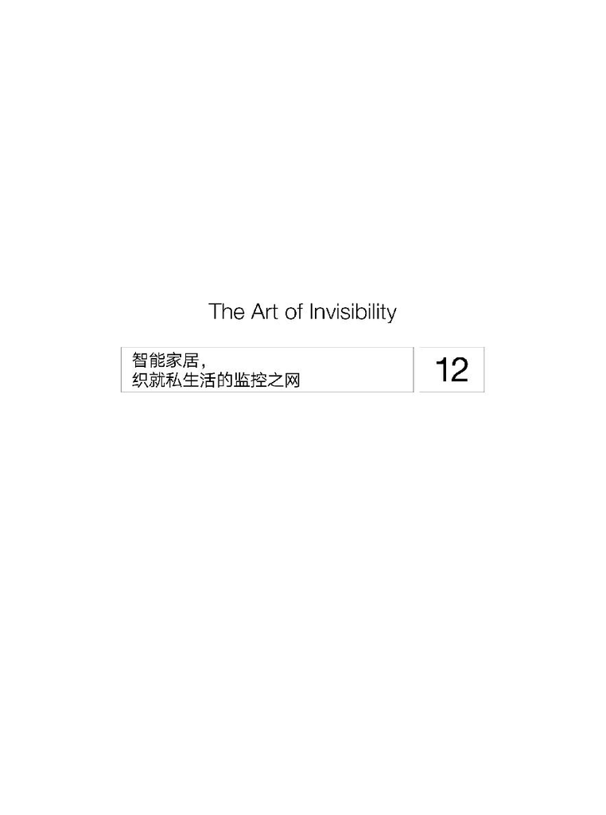

几年前，没人会关心你家里的恒温器。那时候，这种将你家保持在舒适温度的恒温器还是简单的手动控制的。然后，恒温器可以编程了。再然后，一家名叫Nest的公司让你能够使用基于互联网的应用控制你的可编程恒温器。你感觉得到我要说什么了，对吧？

在霍尼韦尔Wi-Fi智能触屏恒温器的一条报复性产品评论中，某个自称General（将军）的人在亚马逊上写到他的前妻夺走了房子、狗和401（k）<sup>(31)</sup>，但他保留了霍尼韦尔恒温器的密码。当前妻和她的男友出门时，这个General声称他会升高房间里的温度，然后在他们回来之前又将其降回来：“我只能想象他们的电费可能会有多高。我不禁笑了。”<sup>1</sup>

在信息安全行业会议Black Hat USA 2014上，研究者揭示了几种可能会给Nest恒温器的固件造成危害的方式。需要重点强调一下，其中许多危害方式都需要物理访问该设备，也就是说，得有人进入你的家里并且在恒温器上安装一个USB接口才行。独立安全研究者丹尼尔·布恩特洛（Daniel Buentello）是谈论入侵该设备的四位演讲者之一。他说：“这是一种用户无法在上面安装反病毒软件的计算机。更糟糕的是，里面还有坏人可以使用并且永远待在那里的一个秘密后门。这是真正的墙上之蝇<sup>(32)</sup>。”

这个研究团队展示了一段视频，其中他们修改了Nest恒温器的接口并且上传了多种其他新功能。有意思的是，他们无法关闭该设备内部的自动报告功能——因此为了做到这一点，该团队创建了他们自己的工具。这个工具会切断流回Nest的母公司谷歌的数据流。

之后，Nest的佐兹·库齐亚斯（Zoz Cuccias）对该演讲进行了评论，她告诉*VentureBeat*：“从笔记本电脑到智能手机，所有的硬件设备都是可以被破解的；这不是一个独有的问题。这种物理破解需要实际接触到Nest Learning恒温器。如果某人成功进入了你家并决定做些坏事，那么他很可能会安装自己的设备或拿走你的珠宝。这种破解不会危害我们的服务器或与服务器的连接的安全性，而且就我们所知，还没有任何设备可被远程访问并受到危害。客户的安全对我们来说非常重要，而且远程漏洞是我们的最高优先项。你的最佳防范措施之一是购买一套Dropcam Pro，这样你就可以在不在家时监控家里的状况了。”

### 将密码改得难以被猜到，部署物联网设备的第一步

随着物联网的出现，像谷歌这样的公司急于在其中占据一席之地，拥有其他产品可以使用的平台。换句话说，这些公司希望其他公司开发的设备能够连接到它们的服务而不是其他公司的服务。谷歌拥有Dropcam和Nest，但还想让其他物联网设备（比如智能灯泡和婴儿监视器）也连接到你的谷歌账号。至少对谷歌而言，这么做的好处是可以收集到更多有关你的个人习惯的原始数据（任何大公司都是这样，包括苹果、三星和霍尼韦尔）。

谈到物联网，计算机安全专家布鲁斯·施奈尔（Bruce Schneier）在一次受访时总结说：“这非常像20世纪90年代的计算机领域。没人关心安全性，没人做更新，没人知道任何事——这些事全都非常非常糟糕，并且将会带来崩溃……漏洞肯定会有，它们会被坏人利用，而且没有给它们打上补丁的方法。”

为了证明这一点，记者卡什米尔·希尔在2013年夏天做了一些调查并自己动手进行了一些计算机入侵。通过使用谷歌搜索，她发现，一个简单的短语就可以让她控制一些用于家庭的Insteon集线器设备。集线器是指为移动应用或直接为互联网提供接入的中心设备。通过这个应用，人们可以控制客厅的照明、锁上房子的门或者调节家里的温度。通过互联网，房子的主人还可以在出差的时候远程调节这些东西。

调查表明，攻击者也可以使用互联网远程接入该集线器。为了进一步验证，希尔联系了俄勒冈州一个完全陌生的人——托马斯·哈特利（Thomas Hatley），问哈特利能否使用他家作为测试案例。

希尔在自己位于旧金山的家中可以开关哈特利家里的灯，而他们在太平洋海岸上相距大约1 000公里之遥。如果哈特利的热水浴缸、风扇、电视机、水泵、车库门和视频监控相机都联网了，那希尔也都可以控制。

其中的问题（现已修复）在于，Insteon让谷歌可以搜到哈特利的所有信息。更糟糕的是，那时候对这些信息的访问还没有使用密码保护——任何知道这个情况的人都能控制任何可在网上找到的Insteon集线器。哈特利的路由器确实有一个密码，但通过寻找Insteon所使用的端口就可以绕过这个密码，希尔也正是这么做的。

“托马斯·哈特利的家是我可以访问的8个家庭中的一个。”希尔写道，“敏感信息暴露出来了——不只是人们有什么家电和设备，还有他们的时区（以及离他们家最近的主要城市）、IP地址，甚至一个孩子的名字；显然，他的父母希望能远距离地关掉他的电视机。在至少3个案例中，得到的信息都足以将这些互联网上的家庭与他们在真实世界中的实际位置对应起来。大多数系统的名字都很普通，但在其中一个案例中，系统的名字包含了一个街道地址，让我可以追踪到康涅狄格州的一处房屋。”

大约在同一时间，安全研究者尼塔什·汉贾尼也发现了一个相似的问题。他当时正在专门研究飞利浦Hue照明系统，该系统可以让主人使用移动应用来调节灯泡的颜色和亮度。该灯泡的颜色范围为1 600万色。

汉贾尼发现，只需在家庭网络中的家庭计算机上植入一个简单脚本，就足以在该照明系统中引发分布式拒绝服务攻击（distributed denial-of-service attack，简称DDoS攻击）。<sup>2</sup>换句话说，他可以按自己的想法让任何使用Hue灯泡的房间陷入黑暗。他写的脚本是一段简单的代码，这样当用户重启该灯泡时，它很快又会熄灭——而且只要那段代码在那里，它就会一直不断地熄灭。

汉贾尼说，这可以给办公楼或公寓楼带来严重的麻烦。该代码会让所有灯都不能工作，即使受到影响的人给当地公共事业公司打电话，也只能发现他们那片地区并没有停电。

尽管可通过互联网访问的家庭自动化设备可以成为DDoS攻击的直接目标，但它们也可以遭到侵入，从而成为某个僵尸网络（botnet）的一部分。僵尸网络是由一个控制器控制的受感染设备大军，可用于针对互联网的其他系统发动DDoS攻击。2016年10月，为Twitter、Reddit和Spotify等主要互联网品牌提供DNS基础设施服务的公司Dyn就遭受了这种攻击的一次重创。美国东部的数百万用户无法访问很多主要网站，因为他们的浏览器无法接入Dyn的DNS服务。

这一事件的罪魁祸首是一个名叫Mirai的恶意软件，这个恶意程序可以在互联网中到处搜索，寻找不安全的物联网设备，以便在未来的攻击中劫持和利用。这些设备包括闭路电视监控系统相机、路由器、数字视频录像机和婴儿监控器等。Mirai会通过简单的密码猜测并尝试接管该设备。如果攻击成功，该设备就会被加入一个僵尸网络中，并等待指令下达。现在只需简单的一行指令，该僵尸网络的运作者就可以指示每个设备（总共有数十万乃至数百万个）向目标网站发送数据，从而将其淹没在信息洪流之中，迫使其离线。

尽管你没法阻止黑客对其他人发动DDoS攻击，但你可以避免他们的僵尸网络看到你。部署物联网设备的第一件事就是，将密码改得难以被猜到。如果你已经部署了设备，重新启动应该就能移除任何已有的恶意代码。

### 任何一个设备都能成为泄露隐私的途径

计算机脚本可以影响其他智能家居系统。

如果你家有个新生儿，你可能也有一个婴儿监视器。这种设备要么是一个麦克风，要么是一台相机，要么就是两者的组合，使父母远离婴儿床也能一直关注他们的宝贝。然而，这些设备也可能会“邀请”其他人来观察这个孩子。

模拟婴儿监视器使用的是已经退休的43～50 MHz范围的无线频率。这些频率最早是20世纪90年代的无绳电话使用的，任何拥有便宜的无线电扫描仪的人都可以轻松拦截无绳电话的通话，被拦截的目标也无法知道发生了这种事。

即使在今天，黑客也可以使用频谱分析器来发现特定模拟婴儿监视器所使用的频率，然后使用各种解调方案将这些电信号转换成音频。从电子设备商店购买的警用扫描仪就足够了。有人还使用设置在同一个信道的同一个品牌的婴儿监视器来偷听邻居，这类法律案件已经有很多了。2009年，芝加哥的韦斯·登科夫（Wes Denkov）起诉了Summer Infant Day & Night婴儿视频监视器的生产商，声称他的邻居可以听到他家里的私人谈话。<sup>3</sup>

作为应对措施，你可能会想使用一个数字婴儿监视器。它们仍然很容易被窃听，但它们更加安全，而且有更多配置选择。比如说，你可以在购买之后立即更新监视器的固件（芯片上的软件）。另外，一定要修改默认的用户名和密码。

在这里，你可能同样会遇到不受你控制的设计选择。尼塔什·汉贾尼发现，贝尔金WeMo无线婴儿监视器在应用中使用了一种令牌；一旦你将该应用安装到了你的移动设备上并在你的家庭网络上使用过，那么该令牌将一直保持活动——在世界任何地方。假设你同意看护你的新生侄女，而且你哥哥邀请你通过他的本地家庭网络，将这个贝尔金应用下载到你的手机上（很幸运，该网络使用了WPA2密码进行保护）。那么现在，你从全国各地乃至全球各地都能够访问你哥哥的婴儿监视器了。

汉贾尼指出，很多互连的物联网设备中都有这样的设计缺陷，这些设备假设在本地网络上的所有事物都是可信的。一些人相信，不久之后我们的家里都会有二三十个这样的设备；如果真是如此，那么安全模式也必须改变。如果网络上的一切都是可信的，那么任何一个设备（婴儿监视器、灯泡、恒温器）中的漏洞都能让远程攻击者进入你的智能家居网络，并让他有机会对你的个人习惯有更多的了解。

### 关闭语音激活，别让电视与手机出卖你

在移动应用出现之前很久，就有手持式遥控器了。我们大多数人都太年轻，不记得电视机有遥控器之前的日子——那时候，人们必须离开沙发，亲自转动一个旋钮来更换频道或开大音量。今天，我们舒服地坐在沙发上就能给电视下达指令。这可能非常方便，但也意味着电视一直在聆听——可能只是为了听到打开自己的命令。

在早期的时候，电视机的遥控器需要在直线视野内，使用光工作——确切地说是使用红外技术。电池供电的遥控器会发出一连串的闪光，人眼几乎看不见，但电视机的接收器能够看见（同样要在直线视野内）。当电视关机时，它如何知道你是否想打开它？很简单：电视机中的红外传感器一直开启着，处于待机模式，等待着来自手持遥控器的特定红外光脉冲序列将其唤醒。

遥控电视发展了很多年之后才纳入了无线信号，这意味着你无须直接站在电视机前面；你可以在侧面，有时甚至可以在另一个房间。同样，关机时电视机处于待机模式，等待着合适的信号唤醒它。

后来发展出了语音激活的电视。这些电视不再需要拿在手里的遥控器了——而且你可能也像我一样，在需要遥控器的时候到处找也找不到。你只需说一句“电视打开”或“你好电视”这样蠢蠢的话，电视就会神奇地打开。

2015年春季，安全研究者肯·蒙罗（Ken Munro）和戴维·洛奇（David Lodge）想知道使用声音激活的三星电视是否一直在听房间内的交谈，即使该电视未被使用。他们发现，数字电视确实会在关闭后保持闲置（这是让人放心的），但在你给了它们一个简单的命令（比如“你好电视”）之后，电视就会录下你所说的一切（它们会录下一切声音，直到再次得到“关闭”的命令）。有多少人会记得在电视开着时保持绝对的安静？

我们不会保持安静，而更让人不安的是，我们在“你好电视”命令之后所说的（和被录下的）话都没有加密。如果我能进入你的家庭网络，就可以在这台电视开着时偷听你在自己家里的任何谈话。支持让电视处在监听模式的观点认为，该设备需要听到你可能给出的任何额外命令，比如“调高音量”“换台”“静音”。这可能没什么问题，只是被捕获到的语音命令需要先上传到卫星，然后再返回来。而且因为整个数据流都没有加密，我就可以对你的电视发动中间人攻击：插入我自己的命令来切换频道、将音量开得很大或在任何我想的时候直接关闭这台电视。

让我们想一想这个情况。这就意味着，如果你与一台具有语音激活功能的电视共处一室，并且你正在和某个人谈话，然后你决定打开这台电视，那么接下来的谈话流可能就会被你的数字电视记录下来。此外，这段关于小学即将进行的面包糕饼售卖活动的谈话录音可能会被传输回远离你家客厅的某个服务器。事实上，三星不仅会将这些数据传输给自己，还会传输给另一家名叫Nuance的语音识别软件公司。所以有两个公司都获得了关于即将到来的面包糕饼售卖活动的关键信息。

让我们认清现实吧：你在你家中电视前的谈话可能一般都不是关于面包糕饼售卖活动的。也许你在谈论什么非法的、执法部门可能希望知道的事情。这些公司完全有可能会通知执法部门；假如执法部门已经盯上你了，那么官员们可能会用一张搜查令迫使这些公司提供完整的转录。“抱歉啦，但出卖你的是你的智能电视……”

三星在自我辩护时声称隐私协议中提到过这种窃听场景，而且所有用户在打开电视时都默认同意了该协议。但你什么时候在打开一个设备之前会先阅读一下隐私协议？三星表明，公司会在不久的将来加密其所有的电视通信。但截至2015年，市面上的大多数型号都还未加保护。

幸运的是，对于你的三星电视，以及可能的其他制造商的电视上这种HAL 9000<sup>(33)</sup>一样的功能，也有一些可以禁用的方法。在三星PN60F8500和类似的产品上，进入设置菜单，选择“智能功能”，然后在“语音识别”下选择“关闭”。但如果想阻止你的电视记录你家里的敏感对话，就不得不牺牲用语音命令打开电视的能力。你仍然可以用手里的遥控器选择麦克风按钮并说出你的命令。或者你可以从沙发上起身，自己去换台。我明白，这很艰难。

三星不是唯一一家没有加密数据流的公司。一位研究者在测试LG智能电视时发现：每次观看者换台时，电视都会通过互联网向LG返回数据。这款电视也有一个被称为“收集观看信息”的设置选项，默认是开启的。你的“观看信息”包括存储在连接到你的LG电视上的任何USB驱动器上的文件的名字——比如一个包含了你的家庭度假照片的驱动器。研究者还进行了另一项实验，他们制作了一个模拟<sup>(34)</sup>视频文件并将其载入了一个USB驱动器，然后将驱动器插到他们的电视上。分析网络流量时，他们发现这个视频的文件名以http的方式未加密地发送到了GB.smartshare.lgtvsdp.com这个地址。

为智能产品生产嵌入式语音识别解决方案的公司Sensory认为自己还能做到更多。“我们认为智能电视的魔力是让它一直开启，一直倾听。”Sensory公司的CEO托德·莫泽尔（Todd Mozer）说，“目前监听还会消耗太多能量。三星已经做出了一种真正智能的东西并且创造了一种监听模式。我们希望走得更远，让它能一直开启和一直倾听，不管你在哪里。”<sup>4</sup>

现在你知道你的数字电视有怎样的能力了，你可能会想：你的手机会在关机后偷听吗？答案有三大阵营：会、不会和看情况。

隐私社区里有人言之凿凿地说，你必须把关闭后的智能手机的电池取出来，才能确保不被监听。这个观点似乎并没有太多证据支持；大都只是些传闻。还有人宣称只要关闭你的手机就足够好了；结案。但我认为实际上在有些案例（比如说手机被植入了恶意软件）中，手机并没有完全关闭，仍然能记录附近的交谈。所以这取决于多种因素。

有些手机可以在你说出一个神奇的短语时被唤醒，就像是声音激活的电视那样。这意味着这些手机一直都在监听，等待这个神奇的短语。这也意味着，人们所说的话会以某种方式被记录下来或传输出去。在某些感染了恶意软件的手机中，会发生这种事：在没有进行通话时，手机的相机或麦克风也会激活。我认为这种情况很少见。

回到主要的问题上。隐私社区里有人说，你可以在手机关机后激活它。有的恶意软件会让手机看起来像是关机了一样，但实际上却没有关机。但是，我认为人们不可能激活关机后的手机（没有供电）。基本上任何使用电池供电、使其软件保持运行状态的设备都可以被利用。做一个能让开机的设备看起来像是关机了一样的固件后门并不难。没有电的设备做不了任何事。还是说可以？有些人认为NSA在我们的手机中放入了供电的芯片，使它们在手机物理断电（甚至拔出了真正的电池）时也能继续跟踪。

不管你的手机是否能够监听，你在手机上使用的浏览器肯定可以。大约在2013年，谷歌启动了一个名叫“热词”（hotwording）的功能，让你可以使用一个简单的命令来激活Chrome的监听模式。其他公司紧随其后，包括苹果的Siri、微软的Cortana和亚马逊的Alexa。所以你的手机、传统个人电脑和你咖啡桌上的独立设备全都包含后端的云服务，可以响应“Siri，离我最近的加油站有多远？”这样的语音命令。这意味着它们一直在听。而如果你不担心这个，你也要知道，使用这些服务进行的搜索是会被无限期地记录和保存的。

是的，无限期。

所以这些设备会听到多少东西？实际上，当这些设备没有回答问题或开关你的电视时，它们究竟在做什么还不是很清楚。比如说，研究者使用Chrome浏览器的传统个人电脑版本发现，某人（谷歌？）启用了麦克风，似乎一直在监听。Chrome的这个功能源自其对应的开源版本——名叫Chromium的浏览器。2015年时，研究者发现某人（谷歌？）似乎一直在监听。经过进一步调查，他们发现这是因为这款浏览器默认开启了麦克风。尽管这些代码包含在开源软件中，却不提供审查。

这种做法有些问题。首先，“开源”就意味着人们应该可以看到代码，但在这个案例中，这些代码是一个黑箱，没人审查过。其次，这些代码是通过谷歌的自动更新进入这款流行的浏览器的，没有给用户提供拒绝的机会。而且截至2015年，谷歌还没有移除它。谷歌确实为人们提供了退出的方式，但这种退出需要复杂的编程技能，普通用户靠自己是无法办到的。

要移除Chrome和其他程序中这种恐怖的窃听功能，还有一些技术含量更低的方法。对于网络摄像头，直接在上面贴一张胶带就行。对于麦克风，最好的防御措施之一是，在你的传统个人电脑的麦克风插口插入一个聋子话筒。要做到这一点，找一副坏掉的旧耳机或耳塞，然后在麦克风插头处把线剪掉，再把这个麦克风插头插入插口。你的计算机会以为那里有个麦克风，但实际上并没有。当然，如果你想使用Skype或其他网络服务进行通话，就需要先移除这个插头。另外，非常重要的一点是：要确保这个麦克风插头上的两根线没有接触在一起，防止其烧掉你的麦克风端口。

家里的另一种连接设备是亚马逊Echo，这是一种互联网枢纽，可以让用户仅靠语音就能按需点播电影或在亚马逊上订购其他产品。Echo是一直开机的，处于待机模式，监听着每个词，等待着它的“唤醒词”。因为Echo能做的事情比智能电视多，所以用户需要首先向该设备说多达25次某个特定的短语，之后才能对它发出命令。如果你要求，Echo可以告诉你外面的天气，提供最新的体育比赛得分以及订购或再次订购收藏夹里面的商品。鉴于Echo识别的一些短语（比如“明天会下雨吗？”）的一般性本质，你有理由相信，你的Echo可能会比你的智能电视听到更多的内容。

幸运的是，亚马逊提供了删除你在Echo中的语音数据的方法。<sup>5</sup>如果你想删除所有内容（比如你计划把你的Echo卖给另一个人），那么你需要在网上操作才行。<sup>6</sup>

尽管所有这些语音激活的设备都需要一个特定的短语来唤醒，但我们还不清楚这些设备在停工期间（没人命令它做任何事的时间）究竟在做什么。如果可能，要在配置设置中关掉语音激活功能。你总是可以在你需要的时候重新开启它。

### 你的电冰箱也可能出卖你

在你的电视和恒温器之外，与亚马逊Echo一起加入物联网的还有你的电冰箱。

电冰箱？

三星已经推出了一款可与你的谷歌日历连接的电冰箱，这款家电的门上镶嵌了一块平板屏幕，可以显示即将到来的活动——有点像你曾经用来记事的白板。只是现在，这款电冰箱通过你的谷歌账号连接到了互联网。

三星在设计这款智能电冰箱时有几件事做对了。它们使用了SSL/https连接，所以该电冰箱和谷歌日历服务器之间的流量是加密的。而且它们将这款未来电冰箱提交给了DEF CON 23进行测试，这可是世界上最紧张激烈的黑客会议之一。

但据入侵过数字电视通信的安全研究者肯·蒙罗和戴维·洛奇说，三星无法检查与谷歌服务器通信和获取Gmail日历信息的证书。证书可以验证电冰箱与谷歌服务器之间的通信是安全的。但如果没有证书，有恶意企图的人就可能出现并创造他自己的证书，用来窃听你的电冰箱与谷歌之间的连接。

那又如何？

好吧，在这种情况下，某个进入你家庭网络的人不仅能获得你的电冰箱的访问权限，让你的牛奶和鸡蛋变质，还能通过在电冰箱日历客户端上执行中间人攻击而窃取你的谷歌登录凭证，进而取得你的谷歌账号信息——这让他能够读取你的Gmail，甚至还可能造成更大的损失。

智能电冰箱还尚未实现普及。但毫无疑问，随着我们不断连接到互联网甚至我们的家庭网络的设备越来越多，安全性也将随之下降。这非常可怕，尤其是当受到损害的东西对你而言非常宝贵和私密时——比如你的家庭。

物联网公司正在研发可以将任何设备都变成家庭安全系统的一部分的应用。比如，你的电视某天可能会带上一个照相机。这样，在智能手机或平板电脑上的应用能让你从任何远程位置看见你家里或办公室里的任何房间。灯光也可以感知到房子内外的信号从而开启。

有时候，你可能会开车回你的房子，而当你这样做时，你手机上或汽车里的报警系统会使用其内置的定位功能感知你的到达。当你离家15米远时，这个应用就会发出信号，通知家庭报警系统打开前门或车库门（你手机上的应用已经连接到了房子并获得了授权）。然后，这个报警系统会进一步联系室内照明系统，要求其点亮门廊、入口，也许还有客厅或厨房。另外，你可能也想在走进家中时，就能听到立体声音响正在播放来自Spotify等服务的柔和室内乐或最新的排行榜上前40名的音乐。当然，还有房子会根据季节和你的偏好升温或降温，这样你就可以直接享受舒适的家庭环境了。

家庭报警系统在20世纪末21世纪初的时候开始流行起来。那时候的家庭报警系统还需要技术人员在房子的门窗上安装有线的传感器。这些有线传感器会连接到一个中央集线器上，该集线器又会使用固定电话线与监控服务交换信息。设置了这种报警系统之后，如果有人破坏了锁好的门窗，这个监控服务就会联系你，通常是通过电话。这个系统通常带有电池，以防断电。注意，固定电话通常不会断电，除非接入房子的线被切断了。

当很多人摆脱了铜线连接的固定电话并开始仅依靠移动通信服务时，报警监控公司也开始提供基于蜂窝通信的连接。最近它们又转向了基于互联网的应用服务。

现在这些门窗上的传感器本身就是无线的。为丑陋的线缆做的钻孔和穿线肯定少了很多，但风险也更大了。研究者已经多次发现，来自这些无线传感器的信号并未加密。想要破坏该系统的潜在攻击者只需要窃听这些设备之间的通信就行了。比如说，我可以潜入你的本地网络，那么我就可以窃听你的警报公司服务器与你的室内设备（假设它在同一个本地网络中并且没有加密）之间的通信，然后我可以通过操纵这些通信来控制你的智能家居，伪造命令来控制报警系统。

现在也有公司提供“自己动手安装”的家庭监控服务。如果有任何传感器受到了干扰，你的手机就会被一条短信点亮，通知你出现了什么状况。该应用也可能会提供一个房子内部的网络摄像头图像。不管以哪种方式，你都能自己控制和监控你的房子。这当然很好，除非你的互联网中断了。

即使当互联网工作时，坏人也可以破坏或抑制这些手动安装的无线报警系统。比如，攻击者可以触发虚假报警（在某些城市，房主必须为此付费）。在你家门前的街道上或200多米的范围内都可以让你的设备发出虚假报警。虚假报警太多会让该系统不值得信任（而且高昂的费用也会掏空房主的钱包）。

攻击者也可以发送无线电噪声干扰房主手动安装的无线传感器的信号，从而阻止它与主集线器或控制面板的通信。这会抑制警报发出并防止其发出声音，能有效地使保护无效并让犯罪分子长驱直入。

### 网络摄像头，被监控的私生活

很多人在家中安装了网络摄像头——不管是出于安全考虑，还是用来监视清洁工或保姆，或者是用来关注有特殊需求的居家老人和所爱之人。不幸的是，这些互联网上的相机中有很多都容易遭到远程攻击。

有一个叫Shodan的公开可用的网络搜索引擎，它会公开配置连接到互联网的非传统设备。<sup>7</sup> Shodan不仅会给出你家里的物联网设备的结果，还会给出因服务器错误配置而连接到公共网络的市政公用设施内部网络和工业控制系统的物联网设备结果。它还能提供全世界数不胜数的错误配置的商业网络摄像头的数据流。据估计，任何一天都可能有多达10万的网络摄像头在互联网上进行只有一点保护或完全没有保护的传输。

这些摄像头之中有来自友讯（D-Link）公司的默认无须认证的互联网相机，可被用于偷窥别人的私生活（取决于这些相机被用来捕捉什么画面）。攻击者可以使用谷歌筛选器搜索“友讯互联网相机”，查找默认无身份认证的型号，然后进入Shodan这样的网站，点击一个链接，就可以悠闲地查看这些视频流了。

为了防止这种事发生，当你不使用可通过互联网访问的网络摄像头时，就将其关闭，并在物理上断开它们的连接以确保离线了。当使用这些摄像头时，要确保它们有正确的身份认证并且设置了一个自定义的强密码，不要使用默认密码。

如果你认为你的家庭隐私是一个噩梦，那再看看你的工作场所吧。我将在下一章中解释。

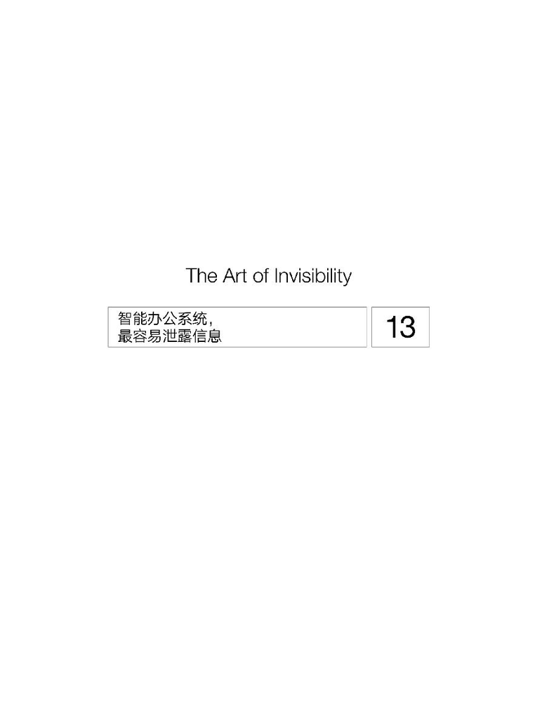

如果你已经读了这么多，那你一定很关心隐私，但对大多数人来说，问题不在于躲过美国联邦政府的眼睛。不过，我们知道上班的时候，我们的雇主可以完全看到我们在他们的网络上所做的一切（比如购物、玩游戏、偷懒）。很多人只希望别被抓到！

而做到这一点的难度正变得越来越大，一部分是由于我们携带的手机。简·罗杰斯（Jane Rodgers）是芝加哥一家景观美化公司的财务经理。无论何时，只要她想知道她的雇员是否在他们应该在的现场，罗杰斯都可以在她的笔记本电脑上调出他们的准确位置。与许多管理者和公司所有者一样，罗杰斯使用了“‘企业所有’且‘员工使用’”<sup>(35)</sup>的带有GPS设备的智能手机和服务卡车上的跟踪软件来监视她的雇员。有一天，一位客户问罗杰斯，她的一位园艺师是否已经外出服务了。敲了几次键盘之后，罗杰斯证实该雇员已经在上午10:00到10:30之间到达了指定地点。

罗杰斯所使用的这类远程信息服务提供的功能可不只有地理位置定位。比如说，她还可以看到公司拥有的9部手机上的照片、短信和园艺师们发送的电子邮件。她还能读取他们的通话记录和网站访问情况。但罗杰斯说她只使用了GPS功能。

GPS跟踪在服务行业已经使用很长一段时间了。GPS跟踪加上联合包裹服务公司（United Parcel Service，简称UPS）自己的使用算法选择路径的ORION系统，UPS可以监控自家的司机并向他们建议优化的路径，从而节省燃油开支。这种方式还能帮助UPS监控懒惰的司机。结果是，UPS每天递送包裹的数量增长了140万，而司机却少了1 000个。<sup>1</sup>

所有这些都对雇主有益，他们辩称通过榨取更高的利润，反过来就可以支付更高的工资。但雇员们会怎么想？所有这些监视都有一个缺点。在一项分析中，*Harper's*杂志给出了在工作中被监控的一位司机的个人档案。这位司机说这个软件会设定下一个递送的时间，并且会在他提前或超过最优时间时提醒他。他还补充说，通常在一天结束时，他可能会超出4小时之多。

因为偷懒？这位司机指出单个站点可能会包含多个包裹，而ORION并不总是会考虑这个情况。他描述道，他在纽约配送中心的同事们为了跟上这个软件的进度，想一次性携带过多的包裹，进而让自己遭受着腰部和膝盖的慢性疼痛之苦——尽管公司一直在提醒要妥善处理重物。所以这种员工监控也要付出人力成本。

食品服务行业是另一个常用工作监控的领域。从餐厅天花板上的摄像头到桌面上的立式机器，有多种软件系统可以对服务员进行监视和评估。华盛顿大学、杨百翰大学和麻省理工学院的研究者在2013年的一项研究中发现，392家餐厅在安装了防盗监控软件之后，与服务员有关的财物盗窃下降了22%。<sup>2</sup>正如我提到过的，活跃频繁的监控确实会改变人们的行为。

美国目前还没有联邦法规禁止公司跟踪其雇员。只有特拉华州和康涅狄格州要求雇主在监控自己的员工时要告知他们。在大多数州，雇员们根本不知道他们在工作时是否会受到监控。

坐在办公室里的雇员又如何呢？美国管理协会发现，66%的雇主会监控他们雇员的互联网使用情况，45%的雇主会监控雇员在计算机上的键盘操作（将空闲时间看作是可能在“休息”），43%的雇主会监控雇员的电子邮件内容。<sup>3</sup>有的公司还会监控雇员的Outlook日历输入、电子邮件标题和即时消息日志。表面上看，这些数据的使用目的是帮助公司了解其雇员花费时间的方式——从销售人员花了多少时间陪客户，到公司的哪些部门在通过电子邮件联系，再到雇员开会或离开了自己的办公桌多长时间。

当然，这也有积极的一面：有了这些指标意味着公司可以更加高效地安排会议或鼓励团队之间进行更多联系。但最重要的是，有人在收集所有这些企业数据。而且这些数据可能有一天会被转交给执法部门，至少在业绩考评时，它们会对你不利。

### 锁定你的计算机，直到你回到屏幕前

你在工作时并没有隐身。任何经由企业网络传输的东西都属于该公司——而不属于你。你可能使用的是公司发放的手机、笔记本电脑或VPN，这样即使你查看的是你的个人电子邮箱账号、你在亚马逊上的最新订单或你的休假规划，你也能预料到有人会监控你所做的一切。

有一个简单的方法，可以让你的管理者甚至同事无法偷窥：当你离开自己的办公桌去参加会议或去洗手间时，锁定你的计算机屏幕。这是认真的。不要把你的电子邮件或关于你耗时数周的项目的细节公开给别人——放在那里让别人乱来。要锁定你的计算机，直到你回到屏幕前。这会多花几秒钟时间，但能让你免受很多苦恼。在操作系统中设置一个定时器，让它在一定时间后就锁定屏幕。或者使用一个蓝牙应用，这样当你的手机不在计算机旁边时，计算机就会自动锁定。话虽如此，现在还有一种使用武器化的USB设备的新型攻击手段。很多办公室封闭了它们的笔记本电脑和台式机上的USB端口，但如果你的设备没有封闭，那么武器化的U盘仍然能不使用密码就解锁你的计算机。<sup>4</sup>

### 如果你关心隐私，就不要在工作时做任何私事

除了企业机密，在上班的时候还会有大量的个人电子邮件经由我们的计算机进行传输，而且有时候，我们还会趁在办公室时为自己打印出来。如果你关心隐私问题，那就不要在工作时做任何私事。在你的工作生活和家庭生活之间树一道严格的防火墙。如果你觉得需要在工作间隙做点私事，你可以带一台私人设备，比如笔记本电脑或iPad。而且如果你的移动设备启用了蜂窝通信，那就永远不要使用公司的Wi-Fi；更进一步，如果你在使用便携式热点，还要关闭你的SSID广播。在工作时做个人事务，应该只使用蜂窝数据。

说实在的，一旦你走进办公室，你的公共面具就需要上线。就像你不会和你临时的办公室伙伴聊真正的私事一样，你也需要让自己的个人事务远离公司的计算机系统（尤其是在你搜索与健康相关的主题或寻找新工作时）。

实际上做起来比听起来更难。其中一个原因是，我们已经习惯了无处不在的信息以及几乎到处都能使用的互联网。但如果要捍卫隐私，你就必须阻止自己公开地做私事。

假设你输入你的办公室计算机的一切都是公开的。那也并不意味着公司的IT部门会积极监控你的特定设备，或就你使用5楼的昂贵彩色打印机打印你孩子的科学展项目一事采取任何行动——尽管他们也可能会这么做。关键是你做的这些事情都会有记录，如果将来你被怀疑了，他们可以读取你在该机器上所做过的一切的记录。这是他们的机器，不是你的。而且网络也是他们的。也就是说，他们可以扫描进出该公司的流量。

用亚当举个例子，假设他在他的工作计算机上下载了自己的免费信用报告。他使用公司的计算机通过公司的网络登录了征信机构的网站。假设你像亚当一样，也在工作时下载了你的信用报告。你想把它打印出来，对吧？所以为什么不将其发送给角落里的公司打印机呢？因为如果你这样做了，该打印机的硬盘中就会有一份包含你的信用历史的PDF文件副本。这台打印机不受你控制。而且当这台打印机退休并被移出办公室之后，你也不能控制其硬盘被处理的方式。现在，有的打印机会加密它们的硬盘，但你确定你办公室那台打印机加密了吗？

你不能确定。

不只如此。你使用Microsoft Office创建的每个Word或Excel文档都包含描述该文档的元数据。文档元数据通常包含作者的名字、创建日期、修改次数和文件大小，还可以选择添加更多细节。默认情况下，微软并没有启用这个功能；你必须经过一些工序才能看到它。<sup>5</sup>但是，微软已经包含了一个文档检查器，让你可以在将文档导出到其他地方之前删除这些细节。<sup>6</sup>

2012年，由施乐和迈克菲公司赞助的一项研究发现，54%的雇员说他们并不总是遵守公司的IT安全政策。那些在工作场所配备了打印机、复印机或多功能打印机的公司的雇员中，有51%说他们在工作时复印、扫描或打印过机密的个人信息。而且不只是工作场所：当地复印店和图书馆里的打印机也是一样。它们全都有可以永久保存自己打印过的一切的硬盘。如果你需要打印一些个人的东西，也许你应该在家打印，或者使用你可以控制的网络和打印机。

### 激光打印机，最容易被攻破的办公设备

间谍活动一直都很有创意，即使对员工也是一样。一些公司会使用一些我们可能会认为理所当然的非传统办公室设备，我们也永远不会想到这些设备可以被用于窥探。看看哥伦比亚大学一位名叫崔昂（Ang Cui）的研究生的故事吧。崔昂想知道他是否可以入侵企业办公室并通过非传统的方式盗走敏感数据，于是他决定首先攻击当今大多数办公室都有的一种基础设备——激光打印机。

崔昂注意到打印机已经远远落后于时代了。我也在几次渗透测试中注意到了这一点。我能够利用打印机来获取进入企业网络的进一步权限。这是因为工作人员在内部部署时很少修改打印机的管理员密码。

打印机（尤其是用于家庭办公室的商业打印机）所用的软件和固件中有大量基本的安全漏洞。问题是，很少有人认为办公室打印机容易被人攻破。人们认为他们在享受有时候被称为“通过隐匿来实现安全”（security by obscurity）的便利——如果没人注意到这个漏洞，那你就是安全的。

但正如我说过的那样，根据型号的不同，打印机和复印机都有一个重要的共同点——它们可能带有硬盘。除非该硬盘加密了（很多仍然还没有加密），否则在之后的某个时间读取打印过的内容仍然是可能的。人们已经知道这一点很多年了。崔昂想知道他能否让公司打印机背叛它的主人，并将打印过的各种东西传出去。

为了更有意思，崔昂想攻击打印机的固件代码，这是嵌入在打印机里的一块芯片中的程序。与我们的传统个人电脑和移动设备不同，数字电视和其他“智能”电子设备并不具有运行安卓、Windows和iOS等全功能操作系统的能力，也不能处理资源。相反，这些设备使用的是所谓的实时操作系统（real-time operating system，简称RTOS），这种系统存储在设备中的单块芯片内（通常被称为固件）。这些芯片仅保存了运行系统所需的命令，而没有其他的。制造商或供应商偶尔也需要通过重刷或替换芯片的方式更新这些简单的命令。这种事发生得非常不频繁，显然很多制造商并不会在其中构建适当的安全措施。所以这种更新的缺乏使崔昂决定实现他的攻击。

崔昂想知道，如果他侵入了惠普用于其固件更新的文件格式会怎样，而且他发现惠普并不会检查每次更新的有效性。所以他创建了他自己的打印机固件——而这台打印机接受了它。就这么简单。打印机并不会验证这个更新是否来自惠普，只关心这些代码是不是预期的格式。

崔昂现在可以自由地探索了。

在一个著名的实验中，崔昂报告说他可以打开定影棒，这是打印机用来在施加油墨后加热纸张的部件；他可以让它一直开启，这会导致打印机起火。其供应商（不是惠普）马上就回应说，定影棒内有一个热故障保护，意味着这种打印机不会过热。但那就是崔昂想要证明的——他成功关闭了这种故障保护功能，因此这台机器可就真的会起火了。

作为实验的结果，崔昂和他的导师萨尔瓦多·斯托弗（Salvatore Stolfo）认为，打印机在任何组织或家庭中都是薄弱环节。比如说，一家财富500强公司的人力资源部门可能会通过互联网收到带有恶意代码的简历文件。当招聘经理打印这个文档时，处理这个文档的打印机可能会被安装上一个恶意的固件，从而被完全接管。

拉印（pull printing）是指防止别人从打印机抓取你的文档，会让打印安全，它能确保文档只会根据用户在该打印机上的授权而发放（通常在打印文档之前必须输入密码）。这可以通过使用PIN码、智能卡或生物识别指纹来实现。拉印也能杜绝未声明的文档，可以防止敏感信息放在那里任人查看。

### 互联网电话，也可以被伪造

在攻击打印机的基础上，崔昂开始在典型的办公室中寻找其他可能易受攻击的常见目标，然后他找到了VoIP电话。和对待打印机一样，没有人充分意识到这些设备在收集信息方面的隐藏价值——你可能想到了。而且和打印机一样，VoIP电话的系统更新也可以被伪造和接受。

大多数VoIP电话都有一个免提选项，让你可以在你的隔间或办公室中将某人的通话用扬声器播放。这意味着在电话听筒之外不仅有一个扬声器，还有一个麦克风。另外，上面还有一个“听筒提起”开关，这会告诉电话某人何时已经拿起了听筒想要拨打或接听电话，以及何时放回了听筒并启用了扬声器。崔昂意识到如果能破坏这个“听筒提起”开关，他就可以让电话通过扬声器麦克风听到附近的谈话——即使听筒挂在电话上也一样！

附加说明：和可以通过互联网接收恶意代码的打印机不一样，VoIP电话需要单独地通过手动方式“更新”。这些代码需要使用一个USB驱动器来传递。崔昂觉得这不是问题。只要价钱够高，一位值夜班的清洁工就可以在他打扫办公室时使用一个U盘，将这些代码安装到每台电话上。

崔昂已经在一些大会上展示了这项研究，每次都使用了不同的VoIP电话，每次都会事先通知其供应商，而且每次供应商都确定会提供一个修复。但崔昂指出，补丁只是存在，并不意味着会被使用。现在，办公室、酒店和医院里可能仍有一些未打补丁的电话。

那崔昂又该如何将这些数据从电话里提取出来呢？因为办公室计算机网络会监控异常活动，所以他需要用其他方式来提取这些数据。他决定“脱离网络”，而选择使用无线电波。

在此之前，来自斯坦福大学和以色列的一些研究者曾发现，将你的手机放在你的计算机旁边能让远程的第三方窃听你的谈话。这需要在你的移动设备上植入恶意软件才能办到。但在流氓应用商店提供带有恶意代码的应用下载是很简单的，不是吗？

当你的手机被装上了恶意软件之后，手机中的陀螺仪就会敏感到足以感知轻微的振动了。研究者表示，在这种情况下，该恶意软件可以收集细微的空气振动，包括由人类说话引起的振动。谷歌的安卓操作系统可以读取传感器在200 Hz频率下的运动情况。大多数人类语音的频率范围是80～250 Hz。这意味着该传感器可以拾取这些声音中的很大一部分。研究者甚至还为进一步拦截80～250 Hz的信号而设计构建了一个定制语音识别程序。<sup>7</sup>

崔昂在VoIP电话和打印机中发现了类似的东西。他发现，现在任何嵌入式设备中都有的任意微芯片上伸出的精细引脚都可以被控制，以特定的序列振动，从而通过射频传出数据。他称之为funtenna<sup>(36)</sup>，这基本上就是潜在攻击者的游乐场。根据官方的说法，安全研究者迈克尔·奥斯曼（Michael Ossmann）表示：“funtenna是指系统的设计者并未打算用作天线的天线，尤其是当它被攻击者用作天线时。”

除了funtenna，还能使用什么方法来窥探你在工作中所做的事情呢？

以色列的研究者发现，安装了恶意软件的普通手机可以被用于接收来自计算机的二进制数据。在此之前，斯坦福大学的研究者发现，手机传感器可以截听无线键盘电信号发射的声音。这个发现基于麻省理工学院和佐治亚理工学院的科学家进行的类似研究。可以说，你在办公室中输入、查看或使用的一切都能被某个远程第三方以这样或那样的方式窃听。

假设你使用的是一个无线键盘。那么该键盘发送给笔记本电脑或台式电脑的无线电信号可能会被截听。安全研究者萨米·卡姆卡尔就开发了一个用于做这种事的KeySweeper。这是一种伪装的USB充电器，可以以无线和被动的方式寻找、解密、记录和报告（通过GSM）附近任何微软无线键盘的所有按键情况。<sup>8</sup>

### 蜂窝热点，窃听你的通话、拦截你的短信

我们已经讨论过使用咖啡馆和机场里的假冒热点的危险。这在办公室里可能也成立。你办公室里的某个人可能会设置一个热点，而你的设备可能会自动与之连接。IT部门通常会扫描这样的设备，但有时候也不会。

现在这个时代，带自己的热点上班就等于是带上你自己的蜂窝连接。你的移动运营商就会提供飞蜂窝这种小型设备。它们是为增强蜂窝连接而设计的，可用在家庭或办公室等信号可能很弱的地方。它们也不是没有隐私风险的。因为飞蜂窝是蜂窝通信的基站，所以你的移动设备常常会连接到它们，而不会通知你。想想这个情况。

在美国，执法部门会使用一种叫作StingRay的设备，这也被称为IMSI捕获器，是一种手机基站模拟器。此外还有TriggerFish、Wolfpack、Gossamer和swamp box。尽管技术各不相同，但这些设备基本上都像没有蜂窝连接的飞蜂窝一样。它们的目的是收集你的蜂窝电话的国际移动用户识别码，即IMSI。它们在美国的使用情况要明显落后于欧洲——目前是这样。比如，IMSI捕获器可以在大型社会抗议活动上使用，从而帮助执法部门识别参加集会的人的身份。可以想见，活动组织者的手机会一直开启，以便协调活动。

经过长时间的法律战，加利福尼亚州北部的美国公民自由联盟从政府那里拿到了详细论述其使用StingRay的方式的文件。比如说，执法人员被告知要获取笔式记录器（pen register）或诱捕和追踪（trap-and-trace）法庭命令。笔式记录器一直都被用于获取手机号码，即手机的拨号记录。诱捕和追踪技术则被用于收集关于接听的电话的信息。此外，有搜查令的执法部门还能合法地取得通话的语音记录或电子邮件的文本。据《连线》杂志报道，美国公民自由联盟得到的这些文件声明这些设备“也许能够截听通信的内容，因此这样的设备必须配置成禁用截听功能，除非截听行动已经得到了Title III法令的授权”。Title III法令允许对通信进行实时截听。

让我们假设你正受到执法部门的监视。假设你在一间受到了高度监控的办公室里，比如某个公用事业公司的办公室。某人可能会安装一个飞蜂窝，来实现在该公司的正常呼叫记录系统之外的个人通信。其危险之处在于，桌子上放着修改过的飞蜂窝的同事可能会执行中间人攻击，他还可能会窃听你的通话或拦截你的短信。

在2013年的美国黑帽大会（Black Hat USA 2013）上，研究者演示了他们能够在Verizon飞蜂窝上获取观众志愿者的语音通话、短信甚至网络流量。Verizon推出的飞蜂窝的这个漏洞已经得到了修补，但研究者希望向公司表明，无论怎样都应该避免使用这种设备。

有的版本的安卓会在你切换蜂窝网络时通知你，但iPhone不会。研究者道格·德佩里（Doug DePerry）解释说：“你的手机会在你不知情的情况下连接到一个飞蜂窝。这和Wi-Fi不一样，你没有选择。”

Pwnie Express公司生产了一种名叫Pwn Pulse的能够识别飞蜂窝的设备，该设备甚至还能识别StingRay等IMSI捕获器。它让公司能监控其周围的蜂窝网络。这种类型的工具可以检测存在潜在蜂窝威胁的整个频谱，曾经的主顾大多是执法部门，但现在可不是了。

### 会议系统，隐藏着巨大的风险

Skype使用起来对用户很友好，但当涉及隐私时，就没那么友好了。据爱德华·斯诺登发表在《卫报》上的最早的揭露文章称，微软与NSA进行了合作，以确保Skype交谈可以被拦截和监控。一份文件称，一个名叫棱镜（Prism）的计划会监控Skype视频以及其他通信服务。《卫报》引述道：“这些会话中的音频部分一直都会被正确地处理，但视频没有。现在，分析师将会有完整的‘画面’。”

2013年3月，新墨西哥大学的一位计算机科学研究生发现，TOM-Skype会向Skype用户的每台机器上传关键词列表。TOM-Skype是微软与中国公司TOM集团合作创建的中国版Skype。TOM-Skype还会向执法部门发送账号持有人的用户名、传输的时间和日期，以及用户是否发送或接收了消息的相关信息。<sup>9</sup>

研究者发现，甚至非常高端的视频会议系统也可能会被中间人攻击攻陷。中间人攻击是指信号在到达你的终端之前先被引导通过了另一个地方。对音频会议而言也是一样。除非会议主持人有已经拨入连接的号码的列表，并且除非他已经要求验证了任何可疑的号码（比如美国之外的区号），否则就没法证明或确定是否有未受邀请的一方加入了会议。会议主持人应该指出，任何新加入者如果无法证明自己的身份，就挂断这次通话并使用另一个电话会议号码。

假设你的办公室已经花了一大笔钱购买了一套非常昂贵的视频会议系统。你肯定认为这会比日常消费级的系统更加安全。那你可就错了。

研究者H. D.穆尔（H. D. Moore）在研究这些高端系统时发现，它们几乎全都默认自动接听呼入的视频通话。这种做法是有道理的。你安排了上午10点开会，那你就会希望参与者打进来。但是，这也意味着在一天中的其他某些时候，任何知道号码的人都可以拨入，然后真真切切地偷看一眼你的办公室。

穆尔写道：“视频会议系统在风险投资和金融行业的普及程度为以任何意图进行商业间谍活动或获取不公平商业优势的攻击者带来了一小部分非常高价值的目标。”

入侵这样的系统能让攻击者得到什么？会议系统的摄像头处在用户的控制之下，所以远程攻击者可以向上、向下、向左或向右地调整它。在大多数案例中，这些摄像头并没有显示其已经开启的红灯，所以除非你一直看着摄像头，否则你可能就不知道某人动过它。摄像头也可以放大。穆尔说，他的研究团队可以读取贴在离摄像头6米远的墙上的6位数字密码，甚至还能跨过整个房间读取用户屏幕上的电子邮件。

下次你在办公室里的时候，考虑一下视频会议的摄像头能看到什么。也许部门的组织结构图就贴在墙上。也许你的台式机屏幕就正对着会议室摄像头。也许你的孩子和配偶的照片也能被看见。那就是远程攻击者可以看到的内容，而且可能会被用于对付你的公司甚至你个人。

有的系统供应商知道这个问题。比如，宝利通提供了很多页的强化（安全增强）指南，甚至限制了其摄像头的位置调整。但是，IT人员通常没有时间遵守这样的指导原则，甚至都不关心安全。互联网上有成千上万的会议系统都只启用了默认设置。

这些研究者还发现，企业防火墙不知道如何处理H.323协议。他们建议给该设备提供一个公共互联网地址，然后在企业防火墙内为其设置一个规则。

最大的风险是，很多会议系统的管理控制台都只有很少的内置的安全功能，也可能完全没有。在一个案例中，穆尔及其团队进入了一家法律公司的系统，里面有一家著名投资银行的董事会议室地址簿条目。事情的起因是，这些研究者在eBay上购买了一台二手的视频会议设备，设备到货时，它的硬盘上仍然有之前的数据——包括一个地址簿，上面列出了数十个私人号码，其中很多都设置成会自动接听来自广大互联网的呼叫。和对旧打印机和复印机的操作一样，如果你的设备里有硬盘，你需要在将其卖掉或捐赠出去之前安全地清空里面的数据。

在工作中，有时候我们的任务是与一位同事合作完成一个项目，而这位同事可能身在这个星球另一边。你们之间的文件可以通过企业电子邮箱共享，但有时候文件非常大，以至于电子邮件系统会直接拒绝，不接受它们作为附件。因此，人们已经越来越多地使用文件共享服务来互相发送大文件了。

这些基于云的服务有多安全？情况各有不同。

苹果的iCloud、谷歌的Drive、微软的OneDrive（之前的SkyDrive）和Dropbox这四大玩家全都提供了两步验证。这意味着为了确认你的身份，你会在你的移动设备上收到包含一个访问代码的带外短信<sup>(37)</sup>。而且尽管这4个服务在传输数据时都会加密，但如果你不希望这些公司或NSA读取你的数据，就必须在发送之前加密这些数据。<sup>10</sup>

它们的相似之处就止于此了。

2FA很重要，但我还是可以通过劫持未被使用的账号来绕过它。举个例子，我最近做了一次渗透测试，其中，客户使用公开可用的工具为他们的VPN网站添加了谷歌的2FA。我渗透其中的方法是，获取一位没有注册使用该VPN入口的用户的活动目录（active directory）登录凭证。因为我先登录了该VPN服务，它就会提示我使用谷歌身份验证器设置2FA。如果该用户自己从不访问这个服务，那么攻击者就将继续保留访问权限。

对于静态数据，Dropbox使用的是256位AES加密（这是相当强大的）。但是，该公司保留了这些密钥，这可能会让Dropbox或执法部门未经授权访问你的文件。Drive和iCloud为静态数据使用了相当弱的128位加密。这里的担忧是，这些数据可能会被强大的计算能力解密。OneDrive则根本没使用加密，不禁让人怀疑这是不是有意为之，也许是因为某些执法部门的要求。

Drive已经引入了一种新的信息版权管理功能。除了使用谷歌Docs创建的文档、表格和幻灯片，Drive现在也接受PDF和其他文件格式。其中有用的功能包括禁用评论者和查阅者的下载、打印和复制功能。你也可以阻止任何人向一个共享文件添加其他人。当然，这些管理功能仅向文件的所有者提供。这意味着如果有人邀请你共享了一个文件，那么设置隐私限制的只能是那个人，而不是你。

微软也引入了一种为文件加密的功能，听起来就像一个使用自己的密钥单独为每个文件加密的功能。如果一个密钥泄露，也只有一个文件会受到影响，而不会影响到整个存档。但这不是默认设置，所以用户必须养成自己加密每一个文件的习惯。

总体而言，这似乎是个好的推荐。雇员和用户应该在将数据发送到云之前将其加密。这样你就保留了对密钥的控制。如果某个机构向苹果、谷歌、Dropbox或微软提出要求，那么这些公司也没法提供帮助，因为你有个人的密钥。

你也可以选择一个与众不同的云服务提供商——SpiderOak。它提供了云存储的全部优势和同步能力，同时还有百分之百的数据隐私。SpiderOak使用了双因素密码认证和256位AES加密来保护敏感的用户数据，这样可以保证这些文件和密码一直都是私密的。用户可以完全私密地存储和同步敏感信息，因为这个云服务对密码和数据绝对一无所知。

但大多数用户还将继续冒着风险使用其他服务。人们喜欢轻松便捷地从云上取用数据，执法部门也是如此。如果你的数据存储在某个桌子的抽屉里或者你的台式计算机上，它们就有《第四修正案》的保护；而使用云时你的数据就没有这样的保护，这是关于使用云的一个重大问题。令人不安的是，执法部门在越来越频繁地请求基于云的数据。而且它们也能相对轻松地获得访问权限，因为你上传到（不管是基于网络的电子邮件服务，还是Drive或Shutterfly）网上的所有内容都会进入一个服务器，而这个服务器属于云服务提供商，而不是你。真正的保护措施是，了解某个人可以访问你放在上面的一切并据此采取行动——先加密一切。

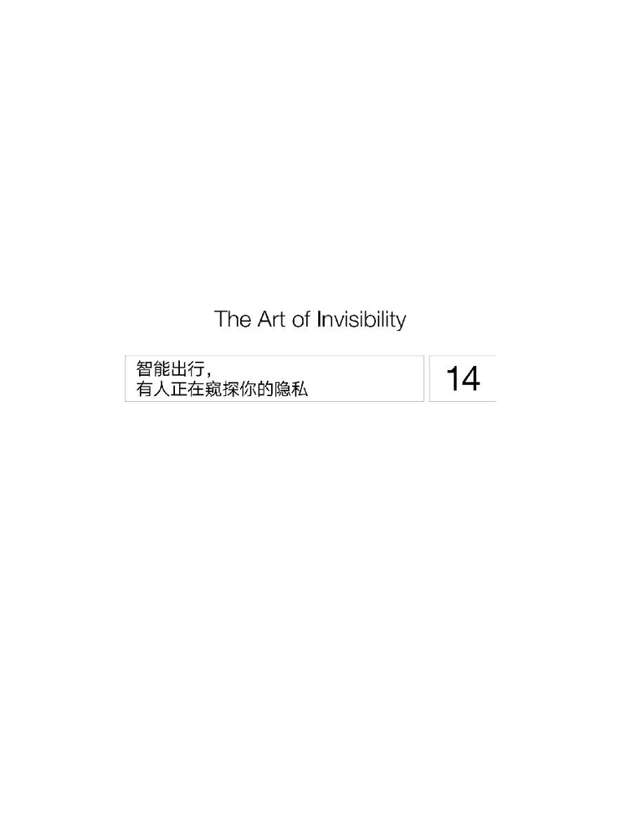

几年前，我有一次去哥伦比亚波哥大旅行后返回美国，抵达亚特兰大之后，我很快被两位美国海关特工带到了一个隐秘的房间。因为我之前被逮捕过，还在监狱里服刑过一段时间，所以比起一般人，我的慌张可能会稍微少一点。但这仍然让人不安。因为我没做任何坏事。我在那个房间里待了4个小时——比我未被逮捕而遭拘留的最大时限短5个小时。

当一位美国海关特工翻看我的护照，然后盯着屏幕时，麻烦开始了。“凯文，”这位特工露出一个灿烂的微笑说，“你猜怎么着？楼下有些人有话对你说。但不要担心。一切都很好。”

我当时去波哥大做了一次由《时代报》（*El Tiempo*）赞助的演讲。我也是去见一位当时是我女朋友的女人。当我在那个楼下的房间里等待时，我打给了我在波哥大的女朋友。她说哥伦比亚警方给她打过电话，要她允许搜查一个我放在联邦快递（FedEx）箱里的寄往美国的包裹。她说：“他们发现了可卡因的痕迹。”但我知道，这不可能。

那个包裹里面有一个2.5英寸内部硬盘。显然，哥伦比亚或者美国当局想检查一下这个硬盘中的内容，而这个硬盘加密了。可卡因只是一个用来打开包裹的毫无说服力的借口。我再也没能拿回我的那个硬盘。

之后，我了解到警方撕开了那个箱子，拆开了那台电子设备，然后为了检查可卡因而试图通过在上面钻孔的方式打开它，结果毁掉了我的硬盘。他们本可以使用一种特殊的螺丝刀来打开这个硬盘。他们没有找到任何毒品。

与此同时，在亚特兰大，官员们打开了我的行李并找到了我的MacBook Pro、一台戴尔XPS M1210笔记本、一台华硕900笔记本、三四个硬盘、一些USB存储设备、一些蓝牙适配器、3部iPhone和4部诺基亚手机（每一部都有自己的SIM卡，这样我就可以在不同国家演讲时避免漫游费了）。这些都是我工作中的标准工具。

另外，行李中还有我的开锁工具套件和一个可以读取和重放任何HID近傍型卡<sup>(38)</sup>的克隆设备。后者可以放在存储卡的旁边，用来检索存储在这些卡上的凭证。比如说，我可以伪造某人的卡凭证并打开上锁的门，而不必制作出一张卡。我带着这些东西的原因是，我在波哥大做了一次关于安全的主题演讲。当然，海关特工们看到这些东西时眼睛就放光了，他们以为我干了其他什么事——比如扫描信用卡，而使用这些设备是不可能办到的。

最后，美国移民与海关执法局（ICE）的特工来了，并问我来亚特兰大的原因。我来这里是为了在一个由美国工业安全协会赞助的安全会议上主持一场小组讨论会。之后，参与这场小组讨论会的一位FBI特工确认了我这趟旅程的原因。

当我打开我的笔记本电脑并登录，向他们展示了确认我出席该小组讨论会的电子邮件之后，情况似乎变得更加糟糕了。

我的浏览器被设置成在启动时自动清空我的历史记录，所以当我启用它时，我被提醒清空我的历史记录。当我点击“确定”按钮清空了我的历史记录时，这些特工抓狂了。然后我就直接按下了电源按钮，关闭了我的MacBook，这样的话，没有我的PGP密码短语就无法访问我的硬盘了。

除非我遭到逮捕（但我被反复告知并未被逮捕），否则我应该就不必给出我的密码。就算我已经被捕，根据美国法律，从技术上讲我也不必给出我的密码，但这项权利是否得到保护取决于一个人愿意抗争多久。<sup>1</sup>而且不同的国家对此有不同的法律。比如，在英国和加拿大，当局可以强制你交出你的密码。

我在这里待了4小时后，ICE和海关特工就让我走了。但是，如果NSA这样的机构将我当成了目标，它们就很有可能成功搞清楚我硬盘中的内容。某些机构可以侵入你的计算机或手机中的固件，破坏你用来连接互联网的网络，并利用在你的设备中找到的各种漏洞。

我甚至可以去有更加严格规定的外国，都永远不会有在美国这样的问题——因为我在美国有犯罪记录。所以，你该如何带着敏感信息穿越国境呢？

如果你不想让你的硬盘提供任何敏感信息，你可以选择：

• 在旅行之前清空任何敏感数据，并且执行完整的备份。

• 将数据留在那里，但使用一个强密码进行加密（尽管有些国家可能会强制你交出密钥或密码）。不要把这个密码短语带在身上，也许可以将一半的密码短语交给一位美国之外的无法被强迫的朋友。

• 将加密后的数据上传到某个云服务，然后根据需要下载和上传。

• 使用VeraCrypt等免费产品在你的硬盘上创建一个隐藏的加密文件夹。同样，如果某个外国政府发现了这个隐藏文件夹，可能还是会强迫你交出密码。

• 不管什么时候，当你在你的设备上输入密码时，都要把自己和你的计算机遮盖起来以防止摄像头的监视，也许可以使用一件夹克或其他衣物。

• 在联邦快递或其他特卫强<sup>(39)</sup>包装中的笔记本电脑和其他设备都要密封并且在上面签字，然后将其放在酒店房间的保险箱中。如果包装被人动过，你应该就能注意到。也要注意，酒店保险箱并不真正保险。你应该考虑买一个可以放在该保险箱中的照相设备。当某人打开这个保险箱时，它就会拍摄一张照片，并通过蜂窝网络实时发送给你。

• 最好的做法是不要冒任何风险。随时、随身携带你的设备，不要让它脱离你的视线。

根据美国公民自由联盟通过《信息自由法案》获得的档案，在2008年10月到2010年6月之间，有超过6 500个进入和离开美国的人在边境被搜查了电子设备。平均下来，每个月都有超过300次边境电子设备搜查。而且其中一半的旅行者都是美国公民。

很少有人知道这个事实：在离美国边境100航空里程的范围内（其中很可能包含圣迭戈），无需搜查令或合理的怀疑就可以搜查任何人的电子设备。不是说穿过了边境线就意味着你绝对安全了！

主要负责检查进入美国的旅行者和物品的两个政府机构是：美国国土安全部的海关和边境保护局（CBP）以及移民与海关执法局。2008年，国土安全部宣布它们可以搜查进入美国的任何电子设备，还引入了自己专有的自动目标核查系统（Automated Targeting System，简称ATS）。它可以在你进行跨国旅行时创建一个关于你的即时个人档案——非常详细的档案。CBP特工会根据你的ATS文件决定是否对重新进入美国的你进行一次更严格的搜查，这样的搜查有时候是侵入性的。

无须任何可能联想到不法之事的原因，美国政府就可以扣留你的电子设备、搜查所有文件并将其保留下来，以待进一步审查。CBP特工可能会搜查你的设备、备份它的内容并尝试找回删掉的图像和视频。

所以我是这样做的。

为了保护我和我客户的隐私，我加密了我的笔记本电脑上的机密数据。当我身在外国时，我会通过互联网传输加密文件，这些文件保存在可能位于世界任何地方的安全服务器上。然后，在我回家之前，我会从计算机上真正清空它们，以防政府官员搜查或扣留我的设备。

清空（wipe）数据和删除（delete）数据不一样。删除数据只会改变文件的主引导记录条目（用于寻找文件在硬盘上各个部分的索引）；这个文件（或它的一些部分）仍然会留在硬盘上，直到硬盘的这部分写入了新的数据。这就是数字取证专家可以重建被删除的数据的方式。

清空数据则是使用随机数据安全地覆写这个文件的数据。在固态硬盘上，清空数据是非常困难的，所以我带了一台具有标准硬盘的笔记本电脑，并且至少要执行35次清空流程。在每一个流程中，文件粉碎软件都会在被删除的文件上覆写数百次随机数据，从而让任何人都难以恢复那些数据。

我过去常常在外接硬盘上创建我的设备的完全镜像备份并将其加密。然后我会将这个备份硬盘寄到美国。在某个同事收到该硬盘并且确认其仍然可读之前，我都不会清空我的终端上的数据。确认后我会安全地清空所有的个人和客户文件。我不会格式化整个硬盘，我会保持操作系统完整。这样的话，我被搜查过后，就可以更加容易地使用远程的方式恢复我的文件，而无须重新安装整个操作系统。

有了亚特兰大这段经历之后，我已经或多或少地改变了我的方案。我开始与一位业务同事保持我的所有旅行计算机的最新“克隆”。如有需要，我的同事就可以向在美国任何地方的我发送克隆的系统。

我的iPhone则是另外一回事。如果你曾经将你的iPhone连接到你的笔记本电脑上充电，而且当屏幕上显示关于“信任这台计算机”的问题时你点击了“信任”，那么该计算机上就会保存一个配对证书，使其无须知道密码就可以访问这部iPhone中的全部内容。只要同一台iPhone连接到该计算机，就会用到这个配对证书。

比如说，你将你的iPhone插入了另一个人的计算机并且“信任”了它，那么在该计算机和iOS设备之间就会创建一种信任关系，这允许该计算机无需密码就能读取iPhone中的照片、视频、短信、通话记录、WhatsApp信息以及几乎其他所有内容。甚至更让人担忧的是，这个人可以直接制作一个你的整部手机的iTunes备份，除非你之前设置了一个加密iTunes备份的密码（这是个好主意）。如果你没设置这样的密码，攻击者就可以为你设置一个，并且在你不知情的情况下直接将你的移动设备备份到他的计算机上。

这意味着，如果执法部门想查看你用密码保护的iPhone上有什么内容，只需将你的手机连接到你的笔记本电脑上就能轻松实现，因为你的电脑里很可能有与该手机有效配对的证书。应该遵循的规则是：永远不要“信任这台计算机”，除非它是你的个人系统。如果你想撤销你的整个苹果设备配对证书，该怎么做呢？好在你可以重置你的苹果设备上的配对证书。<sup>2</sup>如果你需要共享文件，而且你在使用苹果产品，那就使用AirDrop。如果你需要给你的手机充电，那就将闪电（lightning）数据线插入你的系统或电源插座，不要插入别人的计算机。或者你也可以在syncstop.com上购买一个USB安全套（USB condom），这能让你安全地接入任何USB充电器或计算机。

要是你在旅行时只带着你的iPhone，而没有带你的计算机呢？

我已经启用了我的iPhone上的Touch ID，这样它就能识别我的指纹了。在进入任何国家的入境检查处之前，我都会重启我的iPhone。而当它启动时，我故意不输入我的密码。即使我已经启用了Touch ID，但在开机后第一次输入密码之前，这个功能都默认是禁用的。美国法院清楚地表明，执法部门不能要求你给出密码。在美国，传统意义上你不能被强迫给出言词证据（testimonial evidence），但是你可以被强迫交出保险箱的实体钥匙。也就是说，法院可以强制你提供解锁该设备的指纹。一个简单的解决方案是，重启你的手机。这样你的指纹就不会被启用，而且你也不必交出你的密码。

但在加拿大，有法律规定：如果你是加拿大公民，在有要求的情况下，你就必须提供你的密码。来自魁北克省圣安妮平原市（Sainte-Annedes-Plaines）的阿兰·菲利蓬（Alain Philippon）就遇到过这种事。他当时正从多米尼加共和国的普拉塔港回家，在新斯科舍省，他拒绝向边境工作人员提供他手机的密码。根据加拿大《海关法》第153.1(b)条，他被指控妨碍边防官员办公。如果你被认定有罪，你将被处罚1 000美元，并面临最高25 000美元罚款和监禁一年的风险。

我亲身体验过加拿大的这条密码法律。2015年时，我使用了一个类似优步的汽车服务将我从芝加哥带到多伦多（我不想在恶劣的雷暴天气中搭乘飞机）。从密歇根州越过边境线进入加拿大时，我们立即被送到了一个二级检查站。也许这是因为一个只有一张绿卡的中东男人在驾驶吧。我们一到达这个二级检查点，就进入了一个CSI<sup>(40)</sup>中出现过的场景。

一队海关特工确保我们将所有的东西都留在了车上，包括我们的手机。司机和我被分开了。一位特工走到车上司机那一边，并从手机支架上拿走了他的手机。这位特工要求司机给出了密码并开始检查他的手机。

我之前已经下定决心，决不给出我的密码。我当时认为自己必须在给出密码和被允许进入加拿大做我的工作之间做出选择。所以我决定使用一点社会工程。

我对那位正在搜查司机的手机的海关特工喊道：“嘿，你不会搜查我的行李箱，对吧？它上锁了，所以你不能搜查。”这马上就引起了她的注意。她说她完全有权搜查我的行李箱。

我回答说：“我把它锁上了，所以它不能被搜查。”

接下来，两位特工走向了我，要求我交出钥匙。我问他们为什么要搜查我的行李箱，然后他们再次解释，他们有权搜查一切。我拿出了我的钱包，并将我的行李箱钥匙交给了特工。

这就够了。他们完全忘记了手机，转而把注意力放在我的行李箱上。我通过误导实现了目标。我被放行了，而且幸好也没被要求给出我的手机密码。

当处在被审查的混乱中时，我们很容易分心。不要让自己成为受环境支配的受害者。当你通过任何安全检查点时，要确保你的笔记本电脑和电子设备放在传送带的最后。你一定不希望在某人挡在你前面插队时，你的笔记本电脑却待在传送带的另一端。另外，如果你需要离开排着的队，要确保带上你的笔记本电脑和电子设备。

不管我们在家享受着怎样的隐私保护，那都不一定适用于在美国边境的旅行者。对医生、律师和许多行业的专业人士而言，侵入式的边境搜查可能会损害敏感职业信息的隐私。这些信息可能包括商业秘密、律师－客户与医生－病人之间的通信、研究成果和业务战略，其中有些信息是旅行者有法律义务和合同义务去保护的。

对我们其他人而言，搜查我们的硬盘和移动设备可能会暴露电子邮件、健康信息甚至财务记录。如果你最近去过被认为对美国利益不友好的某些特定国家，就要注意，这可能会导致海关人员执行更多额外的审查。

很多公司在员工出国出差时，都会提供一次性手机和借用的笔记本电脑。在他们返回美国时，这些设备要么会被丢弃，要么就会被清空。但对我们大多数人来说，将加密的文件上传到云或购买新设备并在返回时丢弃并不是实际可行的选择。

一般而言，不要带着存有敏感信息的电子设备一起走，除非你不得不这么做。如果你这样做了，就只带最少的量。而如果你需要带上你的手机，就考虑在你出国期间使用一次性手机，尤其是因为在国外的语音和数据漫游费高得吓人。最好带上一部无锁的一次性手机，并在你访问的国家购买一张SIM卡。

你可能认为进出海关就是每次旅行中最大的噩梦了。但可能并非如此。你的酒店房间也可能会被搜查。

2008年时，我去过哥伦比亚几次——不只是我被拦在亚特兰大那一次。在那一年年末的一次旅行过程中，我在波哥大的酒店房间遇到了一些怪事。而且这并不是一家有问题的酒店，这是哥伦比亚的官员经常住的酒店之一。

也许这就是问题所在。

当时我已经和我的女朋友外出吃晚餐去了，当我们回来，我插入我的房间钥匙时，门锁上显示出了黄灯——不是绿灯或红灯，而是黄灯，这通常说明门是从里面锁上的。

我下楼去前台，让店员给了我一张新钥匙卡。门锁再一次显示黄灯。我又换了一张卡，结果还是一样。第三次之后，我要求酒店派一个人和我一起上楼。门打开了。

房间内部乍一看没什么问题。实际上，那时候我认为整件事都是因为这个锁太差劲了。直到回到美国后，我才意识到当时发生了什么。

在离开美国之前，我曾给我的前女友达西·伍德（Darci Wood）打过电话，她曾经是TechTV的首席技术员。我让她来我这里更换我的MacBook Pro笔记本电脑的硬盘。那时候，MacBook Pro的硬盘还很难移除，但她还是做到了。她在旧硬盘的位置放上了一个全新的硬盘，然后我将其格式化，并在上面安装了OSX操作系统。

几周之后，我结束了那次哥伦比亚之旅并返回，我又叫达西到我位于拉斯维加斯的住处将硬盘换回来。

她立刻就注意到有些东西不一样了。她说有人紧固过硬盘的螺丝，而且比她拧的紧得多。显然，某个人曾在波哥大动过这个硬盘，也许是为了在我离开房间时制作一个该硬盘的镜像副本。

斯特凡·埃瑟（Stefan Esser）最近也遇到了这种事，他是一位越狱iOS产品的著名研究者。他在Twitter上发了一张照片，显示他的硬盘被人拙劣地重新安装过。

即使是存有非常少量数据的硬盘，也会带有一些数据。幸好我使用了赛门铁克的PGP全磁盘加密（PGP Whole Disk Encryption）加密了我硬盘中的所有内容。（你也可以为Windows使用WinMagic，或为OSX使用FileVault 2。）所以除非那个窃贼得到密钥并解锁，否则我的硬盘的那个副本就毫无价值。正是因为我认为在波哥大发生了这种事，所以现在，我在旅行时都随身带着我的笔记本电脑，即使当我外出吃晚餐时，也是如此。如果必须将我的笔记本电脑放在一边，那我也永远不会让它处于休眠模式。相反，我会将其关机。如果我没有这样做，攻击者就可能会转存内存并获得我的PGP全磁盘加密密钥。所以我会将其完全关闭。

### 所有的软件都有漏洞

在本书开始时我谈到过，爱德华·斯诺登为了保证自己与劳拉·珀特阿斯的通信私密而采取了很多预防措施。然而，一旦斯诺登的秘密数据缓存准备好向公众发布时，他和珀特阿斯就需要一个保存这些数据的地方。最常见的操作系统（Windows、iOS、安卓以及Linux）都带有漏洞。所有的软件都有漏洞。所以他们需要一个安全的操作系统，一个从一开始就加密并且需要密钥来解锁的操作系统。

硬盘加密的工作方式是这样的：当你启动你的计算机时，你要输入一个安全密码或“We don’t need no education”<sup>(41)</sup>这样的密码短语。然后操作系统启动，你就可以存取你的文件并执行你的任务了，你不会注意到任何时间延迟，因为驱动器是以透明和即时的方式执行加密任务的。但是，如果你起身离开你的设备——即使只有一小会儿，某人也确实有可能会访问你的文件，因为它们已经解锁了。当你的加密硬盘解锁时，你需要采取预防措施保证它的安全，要记住，这很重要。一旦你关机，操作系统就不再具有该加密密钥了。也就是说，它直接从内存中移除了密钥，这样就无法再访问硬盘上的数据了。

Tails是一款可以在任何现代计算机上启动的操作系统，能避免在硬盘上留下任何可以通过取证方式恢复的数据，这个硬盘最好还能设置写保护。<sup>3</sup>

将Tails下载到DVD或U盘上，然后为该DVD或U盘设置你的BIOS固件或EFI（OSX）初始引导顺序，以便启动Tails发行版。当你启动时，它将会启动这个操作系统，其中带有多种隐私工具，包括Tor浏览器。这些隐私工具让你可以使用PGP加密电子邮件，加密你的U盘和硬盘，并使用OTR<sup>(42)</sup>加密你的消息。

如果你想加密单个文件，而不是你的整个硬盘，你有几个选择。其中之一是选择使用免费的TrueCrypt，这个软件虽然还能用，但不提供全磁盘加密。因为它已经没人维护了，所以新漏洞可能不会得到解决。如果你继续使用TrueCrypt，就要当心这种风险。VeraCrypt是TrueCrypt 7.1a的一种替代，它是TrueCrypt项目的延续。

另外，也有一些收费的程序。Windows BitLocker显然就是其中之一，它通常不包含在家庭版的Windows操作系统中。如果安装了BitLocker，启动的方法是打开文件资源管理器，右键点击C盘，然后滚动到“启用BitLocker”选项。BitLocker会使用你主板上的一块特殊芯片，这块芯片被称为可信平台模块（trusted platform module，简称TPM）。它的功能是，在确认你的引导加载程序未被修改之后，解锁你的加密密钥。这是针对“邪恶女仆”（evil maid）攻击的完美防御手段，我稍后会介绍这种攻击。你可以将BitLocker设置为在你开机的时候解锁，也可设置为只有当你提供了PIN码或特定的USB设备之后才会解锁。后面这个选择要安全得多。你可以选择将这个密钥保存到你的微软账号中。但不要这么做，因为这样几乎就相当于将你的密钥交给了微软（而你将会看到，它可能已经有你的密钥了）。

BitLocker存在一些问题。首先，它使用的是名为Dual_EC_DRBG的伪随机数生成器，这是“dual elliptic curve deterministic random bit generator”（双椭圆曲线确定性随机比特生成器）的缩写，其中可能包含了NSA的一个后门。<sup>4</sup>另外，它也是私有的，这就意味着“它是有效的且没有给NSA提供任何后门”的说法只是微软的一家之言——开源软件可能就不会出现这种情况。BitLocker的另一个问题是，除非你用250美元购买了密钥，否则你就必须与微软共享密钥。不花钱购买的话，执法部门可能就会让微软交出密钥。

实际上，尽管有这些问题，电子前线基金会仍然推荐一般消费者使用BitLocker来保护自己的文件。然而，你也要知道，还存在一种绕过BitLocker的方法。

另一个商业选择是来自赛门铁克的PGP全磁盘加密。很多大学在使用这个方案，许多企业也在用。我过去也用过。PGP全磁盘加密是由菲尔·齐默尔曼创造的，就是那个为电子邮件创造了PGP加密的男人。和BitLocker一样，PGP现在也支持TPM芯片，以便在你启动你的个人电脑时提供额外的身份验证。一个永久许可的售价约为200美元。

另外还有WinMagic，这是少有的几个需要双因素认证而不只是一个密码的选择之一。WinMagic也不依赖于某个主密码。相反，用它加密的文件是分组的，而且每一组都有一个密码。这会让密码恢复更加困难，所以它可能并不适合每个人使用。

苹果则有FileVault 2。在安装之后，你可以打开系统偏好设置，点击“安全和隐私”图表，然后切换FileVault选项卡来启用FileVault 2。同样，不要将你的加密密钥保存到你的苹果账号中。这可能会让苹果公司读取到它，而苹果公司反过来又可能会将其交给执法部门。你应该选择“创建恢复密钥并且不要使用我的iCloud账号”，然后再将这个包含24个字符的密钥打印出来或抄写下来。保护好这个密钥，因为任何找到它的人都可以解锁你的硬盘。

如果你的iPhone或iPad上有iOS 8或更新版的操作系统，那么它的内容就是自动加密的。更进一步，苹果表示其密钥保存在设备上，在用户手里。这就意味着美国政府无法向苹果索要这个密钥：任何一台设备的密钥都是独特的。FBI局长詹姆斯·科米（James Comey）声称，不可破解的加密最终不是件好事。他在一场演讲中说：“经验丰富的罪犯将会依靠这些方式来逃避侦查。而我的问题是：这会有什么代价？”他们害怕加密会将坏事掩盖起来。

在20世纪90年代，同样的恐惧曾让我的案子拖延了几个月，我则被关在监狱里憔悴不已。我的法律辩护团队希望获取执法部门计划在审判时使用的对我不利的发现。但执法部门拒绝转交任何加密的文件，除非我提供加密密钥。我拒绝了。而因为我不愿向他们提供密钥，法院反过来又拒绝命令他们提供这些发现。

安卓设备从3.0版（蜂巢）开始也可以加密了。但我们大多数人都选择了不加密。从5.0版（棒棒糖）开始，加密存储器成了Nexus安卓手机产品线的默认设置，但在LG、三星和其他制造商的手机上，它是可选项。如果你选择加密你的安卓手机，那要注意，这可能会花费长达一个小时的时间，而且你应该在这个过程中将设备插上电。据报道，加密你的移动设备并不会显著妨碍其性能，但一旦做了加密的决定，你就不能撤销了。

在所有这些全磁盘加密程序中，总有存在后门的可能性。曾经有一家公司聘请我测试一款USB产品，这款产品让用户可以将文件保存在一个加密的存储器中。在分析代码期间，我们发现，开发者在里面放入了一个秘密的后门——用来打开这个加密存储器的密钥被藏在该USB驱动器上的某个随机位置。这意味着任何知道这个密钥的位置的人都可以解锁这些被用户加密的数据。

更糟糕的是，公司并不总是知道如何应对这种信息。当我完成了对该加密USB设备的安全分析时，那家公司的CEO打电话问我，他是否应该留下这个后门。他担心执法部门或NSA可能会需要读取用户的数据。他竟然会这么问，这就能说明很多问题。

美国政府在其2014年的监听报告中说，在执法部门搜查过证据的3 554台设备中，仅有25台加密了存储器。而且他们仍然可以解密这25台设备中的21台。所以尽管加密往往足以防止一般的窃贼访问你的数据，但对目的明确的执法部门来说，这可能算不上什么大难题。

### 邪恶女仆

几年前，研究者乔安娜·鲁特科夫斯卡（Joanna Rutkowska）描写了她称之为“邪恶女仆”的攻击方法。假设某个人将一台已经关机的笔记本电脑留在了酒店房间里，而且这台电脑的硬盘已经使用了TrueCrypt或PGP全磁盘加密进行加密。（当时我在波哥大用的就是PGP全磁盘加密，我也将笔记本电脑关机了。）之后，某人进入这个房间，并在电脑上插入一个包含恶意引导加载程序的U盘。然后目标笔记本电脑必须从该U盘启动，以安装这个会窃取用户的密码短语的恶意引导加载程序。现在，陷阱已经设置好了。

女仆是做这种事的最佳候选人，因为她们可以频繁出入酒店房间而不会引起太多怀疑——这种攻击方式也由此得名。女仆可以在第二天再次进入几乎任何酒店房间，然后输入一段秘密的密钥组合，提取出秘密存储在其磁盘上的密码短语。现在，攻击者可以输入这个密码短语，然后取得你的所有文件的访问权限。

我不知道是否有人曾在波哥大对我的笔记本电脑做过这种事。我的硬盘被移除后又重新装回了原位，而且螺丝还拧得太紧了。不管怎样，幸运的是，那个硬盘里没有什么真正重要的信息。

把你的电子设备放进酒店保险箱又如何呢？这是不是就比将它们敞开放着或放在行李箱里更好呢？是更好，但好不了多少。在参加最近一次黑帽大会时，我住在拉斯维加斯的四季酒店。我在保险箱里放了4 000美元现金以及多张信用卡和支票。几天后，我尝试打开这个保险箱，但密码错误。我给保安打了电话，然后他们打开了它。我立刻注意到那沓100美元的钞票薄了很多。还剩下2 000美元。所以另外2 000美元哪儿去了？酒店保安不知道。我的一位专业从事物理渗透测试的朋友试图侵入这个保险箱，但没能成功。如今这仍然是一个谜。讽刺的是，这个保险箱的牌子是Safe Place<sup>(43)</sup>。

德国反病毒软件公司G DATA发现在其研究人员所住的酒店房间里，保险箱多半配置有默认密码（0000）。在这种情况下，不管你选择了什么个人密码，任何知道该默认密码的人都可以取得你放在保险箱里的贵重物品。G DATA确实也说过，这个信息并不是系统性地发现的，而是根据多年来的传闻发现的。

如果攻击者不知道一个给定酒店房间保险箱的默认密码，他的另一个选择是直接暴力解锁。尽管酒店经理被托付了一个紧急电子设备，可以插入保险箱的USB接口并打开它，但有经验的小偷可以直接拧下保险箱前面板的螺丝，然后使用某个数字设备来开启下面的锁。或者他可以使该保险箱短路并启动重置，然后输入一个新密码。

如果你不担心上面的问题，再看看这个。G DATA还发现，房间保险箱上的信用卡读卡器（通常就是你为了使用它们而付款的方式）可以被第三方读取，它们可以浏览这些信用卡数据，然后在互联网上使用或销售这些信息。

### 保留你的房卡或者销毁它们！

现今的酒店都使用NFC或磁条刷卡来关闭和打开你房间的锁。这种做法的好处是，酒店可以在前台快速且轻松地修改这些访问码。如果你弄丢了你的卡，可以要求拿一张新的。然后会有一段简单的代码被发送到你房间的锁上，当你到达你的房间时，新的钥匙卡就生效了。萨米·卡姆卡尔的MagSpoof工具可以被用于伪造正确的序列，并打开使用磁条卡的酒店房间锁。电视剧《黑客军团》（*Mr. Robot*）中有一集就使用了这个工具。

磁条或NFC芯片的存在给人们带来了一种想法：个人信息也有可能被存储在了酒店钥匙卡上。实际上并没有。但都市传说还在继续，甚至还有一个源自圣迭戈县的著名故事。据说那里的一位县警发出了一个警告，说在一张酒店钥匙卡上发现了一位客人的姓名、家庭地址和信用卡信息。也许你已经看过这封电子邮件了。它的内容大概是：

加利福尼亚州南部被指派调查个人安全问题新威胁的执法人员最近发现，在酒店行业内广泛使用的信用卡形式的房间钥匙中嵌入了多种类型的信息。

尽管不同酒店的房间钥匙不一样，但从逸林连锁酒店取得的一个用于区域身份盗用演示的钥匙被发现包含以下信息：

● 客户姓名；

● 客户的部分家庭地址；

● 酒店房间号；

● 入住日期和离店日期；

● 客户的信用卡号码和卡片有效期。

当你将它们交到前台时，你的个人信息就在那里，任何酒店员工都能直接通过在酒店扫描器上扫描这张卡而读取到。某个员工可以带几张卡回家，使用一个扫描设备将其中的信息存储到一台笔记本电脑上，然后再用你的钱购物。

简而言之，在某位员工将这张卡发给下一位酒店顾客之前，酒店都不会擦除卡上的数据。它通常被保管在前台的柜子里，上面还有你的信息！！！

至少要做到：保留这些卡或者销毁它们！当你结账离开房间时，永远不要将它们抛在脑后，永远不要将它们交给前台。他们不会为一张卡而向你收费。<sup>5</sup>

这封电子邮件的真实性已经引起了广泛的争议。<sup>6</sup>老实说，在我看来，这像是胡说八道。

上面列出的信息当然可以存储在钥匙卡上，但那似乎太极端了，甚至连我都这么觉得。酒店为每位顾客都使用了一个可以被看作令牌的东西，也就是一个占位符号码。只有访问执行计费的后端计算机，才能将这个令牌与个人信息关联到一起。

我认为你不需要收集和销毁你的旧钥匙卡，但是，嘿——你可能还是会想这么做。

### 小心机票里的常旅客号码

另一个关于旅行和你的数据的常见问题是：你的飞机票底部的条形码中有什么信息？如果有，它又可能会暴露什么？实际情况是，里面只有相对很少的个人信息，除非你有一个常旅客号码（frequent flyer number）。

从2005年开始，国际航空运输协会决定使用条形码登机牌，原因很简单：磁条登机牌的维护费用要高得多。据估计，这种做法已经节省了15亿美元。更进一步，在机票上使用条形码可以让旅客从网上下载他们的机票并在家打印，或者他们也可以在检票入闸处使用手机。

超市、药店、加油站和其他商店提供的会员卡是一个更大的隐私问题。和必须使用真实姓名的航空公司机票不同，会员卡可以使用虚假的姓名、地址和电话号码（一个你可以记住的假号码）进行注册，这样你的购买习惯就不会关联到你。

### 不透露个人信息连接酒店Wi-Fi

当你住进酒店并打开了你的电脑时，你可能会看到一个可用Wi-Fi网络的列表，比如上面有“Hotel Guest”“tmobile123”“Kimberley’s iPhone”“attwifi”“Steve’s Android”“Chuck’s Hotspot”。应该连接哪一个呢？我希望你现在知道答案了！

大多数酒店Wi-Fi都没使用加密，但需要顾客的姓氏和房间号进行身份验证。当然，也有一些绕过付费墙<sup>(44)</sup>的技巧。

一个在任何酒店都能获取免费网络的技巧是，假装成客房服务给任何其他房间打电话——比如打给过道对面那间。如果该酒店使用了来电显示，那就使用大厅里面的内线电话。告诉接听电话的人，她的两个汉堡正在路上。当这位房客说她没有下订单时，你就礼貌地询问她的姓氏以便解决这个问题。现在，房间号和姓氏都有了，这就是将你（非付费顾客）认证为该酒店的一位合规顾客的全部所需。

### 恶意“更新”的假冒网站

假设你住在一家带有互联网接入的五星级酒店，不管是否免费。在你登录时，你可能会看到一条信息——提醒你Adobe（或其他一些软件制造商）有一个更新可用。作为一个互联网的好公民，你可能会试图下载这个更新，然后再继续。只是你仍然应该将这个酒店网络看作是有敌意的——即使它有一个密码。这不是你的家庭网络，所以这个更新可能并不是真的，而如果你继续点击并下载了它，可能就会疏忽大意地将恶意代码安装到你的个人电脑上。

如果你像我一样经常在路上，要不要更新是一个艰难的选择。除了验证确实有一个可用更新，你能做的事情很少。问题是，如果你使用酒店的网络来下载这个更新，你可能就会被引导至一个提供恶意“更新”的假冒网站。如果可以，应该使用你的移动设备从该供应商的网站上确定这个更新的存在；而如果这个更新不是非常重要，就等你回到安全环境（比如办公室或家里）中再下载它。<sup>8</sup>

软件安全公司卡巴斯基实验室（Kaspersky Lab）的研究者曾经发现，一个被他们称为DarkHotel（也被称为Tapaoux）的黑客犯罪团伙使用了这种技术。他们的运作方式是，先识别可能住在某家特定豪华酒店的企业高管，然后在其到达之前向该酒店的服务器植入恶意软件。当这些高管入住并连接上酒店的Wi-Fi时，这个恶意软件就会被下载到他们的设备上并执行任务。完成感染之后，这个恶意软件就会从该酒店服务器上被移除。这些研究者指出，显然这种事已经持续发生了近十年。

尽管它主要影响的是住在亚洲的豪华酒店中的高管，但在其他地方。可能也很常见。DarkHotel一般针对大众目标使用低级的鱼叉式网络钓鱼攻击，这种酒店攻击则留给了身份显赫的特定目标——比如核电和国防工业的高管。

一份早期的分析认为，DarkHotel的基地在韩国。因为这些攻击使用的一个键盘记录器的代码中包含韩语字符。而且零日漏洞（zero-day）<sup>(45)</sup>也是之前未知的非常先进的漏洞。此外，在该键盘记录器内被识别出的一个韩国人名也已经追溯到了韩国过去曾经用过的其他复杂键盘记录器。

但应该指出的是，这还不足以确定来源。软件可以剪切和粘贴自不同的来源。另外，软件也可以做得像是在某个国家创造的，实际上却是在另一个国家创造的。

为了将恶意软件装到那些笔记本电脑上，DarkHotel使用了伪造的证书，它们看起来就像是由马来西亚政府和德国电信发行的。还记得第5章的内容吗？证书的作用是验证软件或网络服务器的来源。为了进一步掩盖他们做的事情，黑客们会进行一些安排，让这些恶意软件在开始活动之前可以保持长达6个月的休眠。这是为了避开那些可能会将一次访问和感染情况关联起来的IT部门。

当卡巴斯基的一些客户在亚洲某些特定豪华酒店住过并受到了感染之后，卡巴斯基才知道这种攻击。研究者向一家第三方Wi-Fi业主寻求帮助，然后这家Wi-Fi业主和卡巴斯基进行了合作，了解到酒店网络上发生过的事情。尽管用于感染那些顾客的文件已经消失很久了，但文件删除记录还留存着，这些记录与那些顾客的住店日期对应到了一起。

保护自己免受这种攻击的最简单方法是：只要你在酒店连接互联网，就立即连接一个VPN服务。我使用的VPN很便宜，每月仅需6美元。但如果你想隐身，这就不是一个好选择，因为它不允许匿名设置。

如果你想要隐身，就不要将你的真实信息交给VPN提供商。这需要事先设置一个假的电子邮箱地址，并且使用一个公开的无线网络。一旦你有了假电子邮箱地址，就使用Tor设置一个比特币钱包，找一个比特币ATM给这个钱包充值，然后使用混桶对这些比特币进行本质上是洗钱的操作，这样它就不能通过区块链追溯到你。这个洗币过程需要使用不同的Tor环路设置两个比特币钱包。第一个钱包用于将比特币发送给混桶服务，第二个则设置用来接收洗过之后的比特币。

一旦你在摄像头视野之外使用公开Wi-Fi加Tor实现了真正的匿名，就去寻找一个接受比特币作为付款方式的VPN服务吧。使用洗过的比特币进行付款。包括WiTopia在内的一些VPN提供商会屏蔽Tor，所以你需要找一个不会屏蔽的——最好找一个不会记录连接日志的提供商。

在这种情况下，我们不要“信任”这个提供商，不要将真实的IP地址或姓名提供给它。但是，当使用一个新设置的VPN时，你必须当心，不要使用任何与你的真实姓名有关联的服务，也不要使用可以追溯到你的IP地址来连接该VPN。你也许可以考虑连接一部匿名获取的一次性电话。

最好是购买一个便携式热点，并且要以一种非常难以确定你身份的方式购买。比如说，你可以雇某个人帮你买，这样你的脸就不会出现在商店的监控录像中。使用匿名热点时，你应该关闭所有使用蜂窝信号的你的个人设备，以防止出现你的个人设备与匿名设备在同一个地方注册的模式。

总结一下，为了在旅行时隐秘地使用互联网，你需要做到这些：

• 匿名地购买预付费礼品卡。在欧盟国家，你可以用viabuy.com匿名地购买预付费礼品卡。

• 在修改你的MAC地址之后使用开放Wi-Fi。

• 寻找一家无需短信验证就能注册的电子邮箱提供商。或者你可以使用Tor和预付费礼品卡注册一个Skype-in号码，并使用Skype-in接收语音呼叫来验证你的身份。要确保你在摄像头的视野之外（不要在星巴克或其他带有监控摄像头的地方）。当你注册电子邮件服务时，要使用Tor来掩盖你的位置。

• 继续通过Tor使用你的新匿名电子邮箱地址在paxful.com等网站上注册，以便注册一个比特币钱包并购买比特币。使用预付费礼品卡为它们付费。

• 在关闭并建立了一个新的Tor环路之后，设置另一个匿名电子邮箱地址和另一个新的比特币钱包，以防止与第一个电子邮箱账号和钱包有任何关联。

• 使用bitlaunder.com等比特币洗币服务，使货币来源难以被追溯。将洗过的比特币发送到第二个比特币地址。

• 使用洗过的比特币注册一个不会记录流量或IP连接的VPN服务。你通常可以通过查阅VPN提供商（比如TorGuard）的隐私政策来了解被记录的内容。

• 让一个中间人代替你去获取一个便携式热点设备。给这个中间人现金，让他去购买。

• 要访问互联网，就在远离你家、工作场所和你的其他蜂窝设备的地方使用这个便携式热点设备。

• 一旦开机，就通过该便携式热点设备连接到VPN。

• 使用Tor浏览互联网。

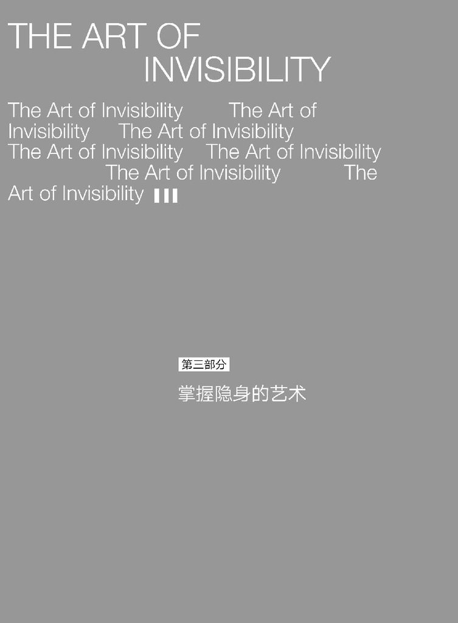

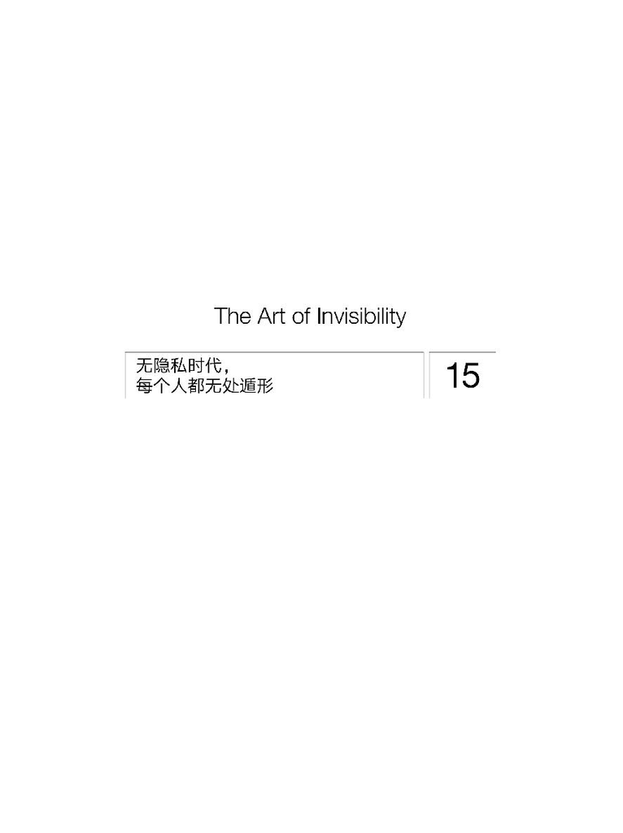

旧金山公共图书馆格伦公园分馆的科幻小说区离罗斯·威廉·乌布利希（Ross William Ulbricht）的公寓不远，他当时正在这里为他所拥有的公司进行在线客户支持聊天。那是2013年10月，这场互联网聊天另一端的人当时认为自己在和该网站的管理员交谈；这位管理员使用了网名“恐怖海盗罗伯茨”（Dread Pirate Roberts），这个名字来自电影《公主新娘》（*The Princess Bride*）。罗伯茨也被称为DPR，实际上就是罗斯·乌布利希——他不仅是Silk Road的管理员，也是其所有者。Silk Road是一个网上毒品商场，因此也是FBI搜捕的对象。乌布利希经常使用图书馆等有公共Wi-Fi的地方进行他的工作，也许错误地认为FBI（应该已经认定他就是DPR）永远不会在公共场所执行抓捕行动。但在那一天，与乌布利希聊天的那个人正好是一位FBI卧底特工。

运营一家网上毒品商场需要一定的胆量，客户可以在这里匿名订购可卡因、海洛因以及各种各样的策划药<sup>(46)</sup>。这个网站托管在暗网上，只能通过Tor访问，而且只接受比特币支付。Silk Road的创造者一直都很谨慎，但还不够谨慎。

在乌布利希坐在旧金山公共图书馆里、被FBI耍得团团转的几个月之前，与这次抓捕行动有关的一位不太可能的英雄出现了，他提供了将乌布利希与DPR关联到一起的证据。这位英雄是一位名叫加里·阿尔福德（Gary Alford）的美国国税局特工，他一直在阅读Silk Road及其来源的相关信息，而且在晚上的时候一直在做高级的谷歌搜索，以便看看他可以发现什么。他发现，提及Silk Road的最早线索之一出现在2011年。某个化名“altoid”的人在一个聊天组中谈到了它。因为那时候Silk Road还尚未推出，所以阿尔福德认为altoid很可能有关于其运营情况的内部信息。阿尔福德很自然地就开始搜索其他参考信息。

他撞了大运。

显然altoid还在另一个聊天组贴了一个问题——但已经删除了原始消息。阿尔福德翻到了一个对这个现已删除的问询的回应，其中就包含了那条原始消息。在那条消息中，altoid说如果有人可以回答他的问题，那个人就可以通过rossulbricht@gmail.com联系他。

这不是altoid最后一次犯错。他还贴出了其他一些问题，其中之一出现在一家名叫Stack Overflow的网站上：这个原始问题是从rossulbricht@gmail.com发送的，但是之后发送者的名称被改成了DPR，这非常引人注意。

关于隐身的规则1：你永远不能将你的匿名网络身份与你的真实世界身份关联到一起。千万不要这么做。

在那之后，还有其他关联。乌布利希和DPR一样都支持罗恩·保罗（Ron Paul）的自由市场和自由主义哲学。乌布利希甚至还在某个时候订购了一些虚假的身份证件——来自各个州的使用不同名字的驾照。2013年7月，美国联邦当局来到了他家门口，但那时候当局还不知道他们正在和DPR说话。

慢慢地，积累的证据已经不可辩驳了，然后在2013年10月的一个早上，DPR的客户支持聊天刚一开始，联邦特工就悄悄地进入格伦公园的这个图书馆。然后，在一次外科手术式的精准突袭中，特工们在他可以关闭他的笔记本电脑前逮捕了他。如果他成功关机，某些关键证据就会被销毁。按照当时的情况，他们在逮捕行动之后立刻拍摄了名为Silk Road的网站的系统管理界面照片，并由此将乌布利希、恐怖海盗罗伯茨和Silk Road确凿无疑地关联在了一起，因此也就终结了匿名的任何未来希望。

在那个早上，乌布利希以管理员的身份登录了Silk Road。而且FBI知道这一点，因为他们已经观察到他的机器登录了互联网。但如果他伪造了自己的位置呢？要是他根本不在那家图书馆，而是使用了一个代理服务器，又会怎样呢？

### 一旦一个想法出现，任何人都可以去实践

2015年夏季，Rhino Security公司的研究者本·考迪尔（Ben Caudill）宣布，他不仅会在DEF CON 23上发表关于他的新设备ProxyHam的演讲，还将在DEF CON供应商房间内以大约200美元的售价出售它。然后，大约一周之后，考迪尔宣布他的演讲被取消了，而且所有已有的ProxyHam装置都会被销毁。他没有提供进一步的解释。

在重要安全会议上的演讲被撤下的原因有很多。产品正被讨论的公司或联邦政府都有可能给研究者施压，让他们不要公开。在这个案例中，考迪尔并不是找到了某个特定的漏洞，而是造了一些新东西。

关于互联网的一件有趣的事情是：一旦一个想法出现，它往往会留在那里。所以就算联邦官员或其他什么人说服了考迪尔，让他相信他的演讲不符合国家安全的利益，似乎其他人也很可能会创造出一种新设备。而且发生的事情也正是如此。

如果你生活在一个受压迫的国家，那么你就会需要这样的设备。通过Tor联系外部世界需要冒很多风险。这种类型的设备可以通过掩盖请求者的地理位置来增加另一个安全层。

只是有人不想让考迪尔在DEF CON上谈论它。

考迪尔在接受采访时否认联邦通信委员会阻止了他。《连线》杂志猜测其原因是，根据美国严酷又模糊的《计算机欺诈和滥用法案》，在其他人的网络上秘密植入一个ProxyHam可能会被解读成未经授权的访问。考迪尔拒绝评论任何猜测。

正如我说过的那样，一旦一个思想出现，任何人都可以去实践它。所以安全研究者萨米·卡姆卡尔创造出了ProxyGambit，这本质上就是一种替代ProxyHam的设备。<sup>1</sup>只是它使用了反向蜂窝流量，也就意味着在使用它的时候，你不再只能待在该设备几公里的范围之内，而是可以在世界的另一边。太酷了！

当然，当攻击者决定使用ProxyGambit及类似的设备时，执法部门肯定会头疼。

### 真实身份无处隐藏

乌布利希的Silk Road是一个网上毒品商场。这不是你在谷歌上就能搜索到的东西；这不是可以轻易地进行索引和搜索的所谓的表层网络（Surface Web）上的东西。表层网络中包含了亚马逊和YouTube等我们熟悉的网站，但也只占到整个互联网的5%。相比于实际存在的网站的数量，大多数人曾经访问过或知道的所有网站的数量其实微不足道。绝大部分互联网网站实际上都隐藏在大多数搜索引擎之外。

在表层网络之后，接下来是占互联网比例最大的一块，这被称为深网（Deep Web）。这是网络中被隐藏在密码权限之后的部分——比如旧金山公共图书馆格伦公园分馆的卡片目录的内容。深网也包含大多数仅限订阅的网站和企业内网网站，比如奈飞、Pandora等。

最后，还有一部分小得多的互联网，被称为暗网（Dark Web）。这部分互联网不能通过普通的浏览器访问，也无法在谷歌、必应和雅虎等网站上搜索到。

暗网就是Silk Road的所在之处。类似这样的网站存在于暗网之中，因为那几乎是匿名的。我说“几乎是”是因为从来没有什么是真正匿名的。

访问暗网只能通过Tor浏览器实现。事实上，带有复杂的字母数字URL的暗网网站都是以.onion结尾的。正如我之前提到过的，由美国海军研究实验室创造的洋葱路由器给受压迫的人们提供了一种联系彼此和外部世界的方式。我也已经解释过，Tor并不会将你的浏览器直接连接到网站；相反，它会建立一个到另一个服务器的链路，然后又会连接到另一个服务器，最后再到达目标站点。这种多跳会使得追溯操作的难度更大。而Silk Road这样的网站是Tor网络内部的隐藏服务（hidden service）的产物。它们的URL是由一个算法生成的，而且暗网网站列表会频繁地改变。Tor既能访问表层网络，也能访问暗网。另一款暗网浏览器I2P也可以访问表层网络和暗网。

甚至在Silk Road关停之前，人们都在猜测NSA或其他机构有办法识别暗网上的用户的身份。NSA可以采用的一种方法是，设立和控制所谓的出口节点，互联网请求会在这里被传递给某个隐藏服务，尽管这仍然无法识别出初始请求者的身份。

为了能够成功识别，某些机构的观察员就必须看到存在某个访问网站X的请求，而且几秒钟之前，某个在新罕布什尔州的人启动了Tor浏览器。这位观察员可能会猜测这两个事件是有关联的。随着时间推移，对该网站的访问和对Tor反复访问都差不多在同一时间出现，这种情况会形成一个模式。避免创造这种模式的一个方法是，始终保持你的Tor浏览器处于连接状态。

在乌布利希的案例中，他大意了。乌布利希显然在早期阶段没有制订计划。在他最早谈及Silk Road的讨论中，他交替地使用了他的真实电子邮箱地址和一个假名。

正如你所见，在当今世界，要在行动时不在互联网上某个地方留下你的真实身份是非常艰难的。但正如我在一开始就说过的那样，只要谨慎一点，你也可以捍卫隐私。接下来，我会告诉你该怎么做。

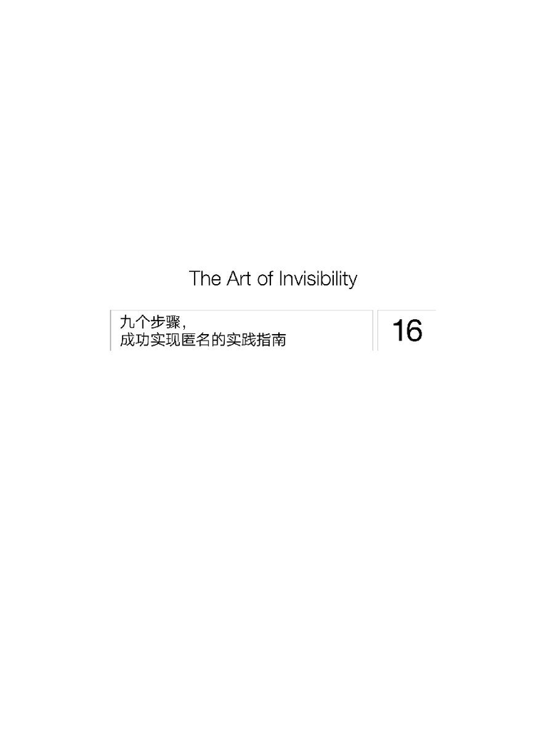

读完这些之后，你可能会思考以你的经验水平让自己在网上隐身会有多简单或多困难。或者你可能会问自己，你应该做到哪种程度，发布内容才是安全的。毕竟，你可能并没有什么国家机密要分享。但是，你可能正在一场法律纠纷中与你的前任做斗争。或者你可能和你的老板之间有分歧。你可能正在联系一个朋友，而他仍与有虐待倾向的家庭成员保持着联系。或者你可能想保持一些活动的私密，让某个律师无法看到。你有许多合理的理由，你需要匿名地与网上其他人通信或使用网络和其他技术，所以……

全面隐身实际需要采取什么步骤？这会用去多少时间？又会花掉多少钱？

如果到目前为止，我还没有非常直白地说清楚，那么为了在网上隐身，你或多或少需要创建一个单独的身份，一个与你完全没有关联的身份。这就是匿名的含义。当你没有匿名时，你必须严格地将你的生活和那个匿名身份分隔开。我的意思是，你需要购买一些仅在你匿名的时候使用的单独的设备。而这可能会很费钱。

比如，你可以使用你当前的笔记本电脑，并在你的桌面上创建一个所谓的虚拟机（virtual machine，简称VM）。虚拟机是一种软件计算机。它被包含在VMware Fusion等虚拟机应用中。你可以在虚拟机中加载一个授权的Windows 10副本，并告诉它你想要多少RAM，以及你需要多少磁盘空间等。对在互联网的另一边观察你的某个人来说，这看起来就像是你在使用一台Windows 10电脑，即便实际上你使用的是一台Mac。

专业的安全研究者一直使用虚拟机，并可以轻松地创建和销毁它们。但即使是专业人士，也面临着隐私泄露的风险。比如说，你可能在你的虚拟机版本的Windows 10中，因为某种原因登录了你的个人电子邮箱账号。现在，这个虚拟机就与你关联起来了。

### 匿名第一步：购买一台单独的笔记本电脑

所以匿名的第一步是，购买一台单独的笔记本电脑，并且你只会将其用于你的匿名网络活动。正如我们已经看到的，在你疏忽大意的纳秒之间（比如在这台机器上查阅你的个人电子邮箱账号），你的匿名性就终结了。所以我推荐获取一台低价位的Windows笔记本电脑（Linux更好，但你要知道怎么使用）。我不推荐MacBook Pro的原因是它比Windows笔记本电脑贵太多了。

之前我曾推荐你购买另一台专门用于网上银行业务的笔记本电脑（具体而言是Chromebook）。办理网上银行业务的另一个选择是使用iPad。你必须使用你的电子邮箱地址、一张信用卡或购买iTunes礼品卡来注册一个Apple ID。但因为这台设备仅用于你的安全的个人银行业务，所以隐身并不是它的目标。

如果你在这方面的目标是隐身，Chromebook就不是最好的选择，因为你不能得到像使用Windows或Ubuntu等基于Linux的操作系统一样的灵活性。只要你跳过让你注册Windows账号的选项，Windows 10就挺好的。无论如何，不要在你的电脑和微软之间创建任何关联。

你应该亲自使用现金购买新的笔记本电脑，而不是在网上买，这样才不会让购买事件轻易地追溯到你。记住，你的新笔记本电脑里面有一个带有独特MAC地址的无线网卡。你不希望任何人利用这个设备追溯到你——你的真实MAC地址可能在某个事件中以某种方式泄露了。比如说，你在一家星巴克店里打开了笔记本电脑，系统就会探测任何之前“连接过的”无线网络。如果这一区域有记录探测请求的监控设备，就可能会导致你的真实MAC地址暴露。一个问题是，如果你的网卡的MAC地址和你的电脑的序列号之间存在任何联系，某些机构就可能有办法追溯到你的笔记本电脑的购买事件。如果是这样，联邦官员只需要找到购买这台特定计算机的人是谁，就能确定你的身份，这可能没有那么困难。

你应该同时安装Tails和Tor并使用它们，而不是使用自带的操作系统和浏览器。

不要用你的真实身份登录任何网站或应用。你已经了解了在互联网上追踪人和计算机是多么容易，所以你知道其中的风险。正如我们讨论过的，用你的真实身份登录网站或账号是非常糟糕的——银行和其他网站经常使用设备指纹来尽可能地减少欺诈，而如果你曾经匿名地访问过同样的网站，那就会留下大量可以识别出你的计算机的痕迹。

事实上，你在家启动你的匿名笔记本电脑之前，最好关闭你的无线路由器。如果你连接到你的家庭路由器（假设你的服务提供商拥有并且管理着你家里的路由器），那么该提供商就能得到你的匿名笔记本电脑的MAC地址。最好的方法一直都是，购买你自己拥有完全控制权的家庭路由器，这样服务提供商才无法得到分配给你的本地网络上的计算机的MAC地址。服务提供商就只能看见你的路由器的MAC地址，这对你来说没什么风险。

你需要的是貌似合理的可否认性<sup>(47)</sup>。你需要为你的连接设置很多层代理，从而让调查者难以将它们与单个人关联在一起，更别说是你了。当我还是一个逃犯的时候，我犯了一个错误，在使用一个蜂窝手机调制解调器来掩盖我的实际位置时，我多次向Netcom的调制解调器拨号。因为我待在一个固定位置，所以一旦调查者知道了我的手机的数据连接正在使用哪个蜂窝塔，使用无线电测向技术找到我就是小菜一碟了。这让我的对手下村努（Tsutomu Shimomura）能够找到我的大概位置，并将其交给FBI。<sup>1</sup>

这就意味着你永远不能在你的家里或工作场所使用你的匿名笔记本电脑。永远不要这么做。所以，获取一台笔记本电脑，并且保证永远不使用它来查阅你的个人电子邮件、社交网络，甚至当地的天气情况。<sup>2</sup>

### 匿名第二步：匿名购买一些礼品卡

另一个可以在网上追踪到你的方法是跟踪资金流动，这是一种经过证明的有效方法。你需要为一些东西付费，所以在将你的匿名笔记本电脑带出去并找到一个公开的无线网络之前，第一步是匿名地购买一些礼品卡。因为每家销售礼品卡的店里的柜员机或柜台处都很可能有监控摄像头，因此你必须格外小心谨慎。你不应该亲自去购买这些卡。你应该在街上雇一个随机选择的人去购买，你则在安全距离之外等候。

但如何能做到这种事？就像我那样做，你可以在停车场里走向某人，然后说你的前任在那边那家店里工作而你不想面对她，或者提供一些其他的听起来貌似可信的借口。也许你可以补充说，她有一个针对你的禁令。为了100美元现金，某些人会觉得帮你买一次东西可能听上去非常合理。

现在我们已经找到了走进店里帮我们购买一些预付费卡的中间人，那么他应该购买什么卡呢？我推荐购买一些预付费的、预设置的100美元卡。不要购买任何可重复充值的信用卡，因为根据《爱国者法案》，你在激活它们的时候必须提供你的真实身份信息。这些购买需要你的真实姓名、地址、出生日期和社会保障号码，这些信息要和征信机构关于你的文件上的信息匹配。提供伪造的姓名或其他人的社会保障号码是违法的，而且可能也不值得冒这个险。我们是要尽力在网上隐身，而不是违法。

我推荐让中间人从连锁药店、7-11、沃尔玛或大卖场购买Vanilla Visa或Vanilla MasterCard 100美元礼品卡。它们往往作为礼品推出，可以像普通信用卡一样使用。你不必为这些卡提供任何身份信息。而且你可以使用现金匿名地购买它们。如果你住在欧盟国家，你应该可以使用viabuy.com匿名地购买一张实体信用卡。在欧洲，商家可以将这些卡通过邮局递送，取货则不需要ID。我的理解是，他们会给你发送一个PIN码，而你可以使用这个PIN码匿名地打开取货箱并取走这些卡（假设那里没有摄像头）。

### 匿名第三步：连接Wi-Fi时修改你的MAC地址

所以，你可以在哪里使用你的新笔记本电脑和匿名购买的预付费礼品卡呢？

随着便宜的光存储设备出现，提供免费无线访问的企业可以将监控摄像头录像存储数年之久。调查者可以相对轻松地获取这些录像，并寻找潜在的嫌疑人。这些调查者可以分析在你访问期间的日志——搜索在其无线网络上验证过的与你的MAC地址匹配的MAC地址。所以，在你每次连接到一个免费的无线网络时，修改你的MAC地址很重要。你需要找一个靠近提供免费Wi-Fi的地方的位置，比如星巴克或其他提供免费无线接入的机构旁边的一家中式餐馆。要坐在靠近该服务提供商的墙的旁边。你可能会体验到连接速度稍微慢了一些，但你会有相对较好的匿名性（至少在这些调查者开始查看周围区域的所有监控录像之前）。

一旦你在该免费无线网络上进行了认证，你的MAC地址就很可能会被记录并保存下来。还记得大卫·彼得雷乌斯将军的情妇吗？记得她在酒店登记的时间和日期与她的MAC地址在这家酒店的网络上出现的时间和日期匹配吗？你可不想犯这样的错，从而危害你的匿名性。所以要记住，每次接入公共Wi-Fi时，都要修改你的MAC地址。

到目前为止，这看起来都很简单。你需要购买一台单独的笔记本电脑，并且只在上面进行你的匿名活动。你需要匿名地购买一些礼品卡。你需要找到一个可以从附近或邻近的地方接入的Wi-Fi网络，以避免被摄像头拍到。另外，你还需要在每次连接免费无线网络时修改你的MAC地址。

当然，要做的事情还有更多，远远更多。我们才刚刚开始。

### 匿名第四步：匿名购买一个个人热点

你可能还需要雇另一个中间人，这一次是为了购买一个更重要的东西：个人热点。正如我之前提到的那样，FBI抓到我的原因是，我使用我的蜂窝手机和调制解调器拨号连接世界各地的系统，而因为我的手机连接的是同一座蜂窝塔，随着时间推移，我的固定位置就暴露了。因此，对方就可以轻松地使用无线电测向技术来确定收发器（我的手机）的位置。通过雇用某个人去一家Verizon（或AT&T、T-Mobile）店里购买一个让你可以使用蜂窝数据连接互联网的个人热点，你可以避免这种事发生。也就是说，你有自己的本地互联网接入，这样你就不必经由某个公共Wi-Fi网络连接互联网。最重要的是，当你需要维持你的匿名性时，永远不要在一个固定地点使用一个个人热点太长时间。

完美的情况是，你雇的那个人不会看到你的车牌号或任何可以识别你身份的方式。给那个人200美元现金购买热点，当他带着热点回来时，再给他另外100美元。移动运营商会向那个中间人出售一个不带身份识别信息的个人热点。而既然你已经在做这件事了，为什么不同时购买一些充值卡，以便增加更多数据呢？希望这个中间人不会带着你的钱逃跑，但为了匿名，冒这个险是值得的。之后，你可以使用比特币给这个一次性设备充值。

在你匿名地购买了一个便携式热点后，和那台笔记本电脑一样，你永远不要在家里开启这个设备，这是非常重要的。每次开启这个热点的时候，它都会在最近的蜂窝塔上注册。你一定不希望你的家、办公室或你常去的任何位置出现在该移动运营商的日志文件中。

也永远不要在你打开你的匿名笔记本电脑、一次性手机或匿名热点的地方打开你的个人手机或个人笔记本电脑。这种隔离是相当重要的。在之后的某个日期和时间，能将你和你的匿名身份关联到一起的任何记录都会让所有操作毁于一旦。

现在，有了预付费卡和带有预付费数据套餐的个人热点（这两者是由两个非常不同的人匿名购买的，这两个人没有任何关于你的信息，不能向警方说明你的身份），我们几乎就设置妥当了。是的，几乎。

### 匿名第五步：匿名创建电子邮箱

从现在起，使用Tor浏览器来创建和访问所有的网站账号，因为这会不断地改变你的IP地址。

初始步骤之一是，使用Tor设置几个匿名电子邮箱账号。这是罗斯·乌布利希疏忽大意、没有做的事情。正如我们在前一章看到的那样，他在暗网上进行他的Silk Road业务时，不止一次地使用了他的个人电子邮箱账号。恐怖海盗罗伯茨和罗斯·乌布利希之间无意中出现的这些交集，再次帮助调查者确认了这两个名字是与一个人有关联的。

为了防止滥用，大多数电子邮箱提供商（比如Gmail、Hotmail、Outlook和雅虎）都要求进行手机认证。这就意味着你必须提供你的手机号码，而且在注册过程中，有一条短信会立即发送到你的设备，以确认你的身份。

如果你用的是一次性手机，你仍然可以使用上面提到的那些商业服务。但是，你必须安全地获取一次性手机和任何充值卡——使用现金，通过一个无法追溯到你的第三方购买。另外，一旦你取得了一次性手机，就不能在靠近你拥有的其他任何蜂窝设备的地方使用它。再说一次：将你的个人手机放在家里。

为了在网上购买比特币，你至少需要两个匿名创建的电子邮箱地址和比特币钱包。所以，你该如何创建像爱德华·斯诺登和劳拉·珀特阿斯创建的那些电子邮箱地址一样的匿名电子邮箱地址呢？

在我的研究中，我发现可以使用Tor在protonmail.com和tutanota.com上创建电子邮箱账号，这两者都不会请求验证我的任何身份信息，也都不会要求我在设置时进行验证。你可以通过搜索电子邮箱提供商，并看它们在注册过程中是否需要你的手机号码来进行自己的研究，你也可以看它们需要多少信息才能创建新账号。fastmail.com是另一个电子邮箱选择，它的功能没有Gmail那么丰富，但因为它是一个付费服务，所以不会挖掘用户的数据或展示广告。

所以现在，我们已经有了一台装载了Tor和Tails的笔记本电脑、一部一次性手机、一些匿名的预付费礼品卡，以及一个带有匿名购买的数据套餐的匿名热点。但我们仍然没有万事俱备。为了维持这种匿名性，我们需要将匿名购买的预付费礼品卡变成比特币。

### 匿名第六步：将礼品卡换成比特币，并进行清洗

我在第6章中谈论了比特币，这是一种虚拟货币。比特币本身并不是匿名的。它们可以通过所谓的区块链而追溯到购买源；而后续的所有购买行为也都可以被追溯。所以，比特币本身并不能掩盖你的身份。我们必须让资金通过一个匿名机制：将预付费礼品卡换成比特币，然后让这些比特币经过一个洗币服务。这个过程会让你得到经过匿名化的比特币，用于未来的支付。比如说，我们需要洗过的比特币来为我们的VPN服务付费，并为我们的便携式热点或一次性手机购买未来的数据流量。

你可以使用Tor在paxful.com或其他比特币钱包网站上设置一个初始比特币钱包。一些网站中间商交易允许你使用预付费礼品卡购买比特币，比如我之前提到的那些预设置的Vanilla Visa和Vanilla MasterCard礼品卡。这种做法的缺点是，你需要为该服务支付至少50%的高额溢价。paxful.com就像一个可以寻找比特币卖家的eBay拍卖网站，只连接你与买家和卖家。

匿名的成本显然很高。你在交易中提供的身份信息越少，你要付出的就越多。这是合情合理的：不验证你的身份就向你出售比特币的人冒着巨大的风险。我曾经用匿名购买的Vanilla Visa礼品卡，以每1.7美元换1美元的比例购买过比特币，价格实在高得吓人，但对确保匿名性而言是必要的。

我提到过比特币本身并不是匿名的。比如说，会存在一个我使用特定的预付费礼品卡交换比特币的记录。调查人员可以通过我的比特币追溯到这些礼品卡。

但我们有办法清洗比特币，从而阻断它与我的任何关联。

洗钱一直以来都是罪犯做的事，最常见于贩毒活动中，但它也在白领金融犯罪中发挥作用。洗钱意味着掩盖资金的原始所有权，通常的做法是将钱转移出国，转到其他有严格隐私法律的国家的多家银行。事实证明，你也可以对虚拟货币做类似的事。

有一种被称为混桶的服务，可以将来自多个不同来源的比特币混合（tumble）在一起，这样得到的比特币保留了它的价值，却携带了许多所有者的痕迹。这会使得之后人们难以确定，某个特定的购买活动是由哪个所有者做出的。但你必须非常小心谨慎，因为这方面的骗局多如牛毛。

我碰过运气。我在网上发现了一个洗币服务，会从交易中收取额外的费用。我实际上已经得到了我需要的等值比特币。但想想看这个情况：这个洗币服务现在知道我的一个匿名电子邮箱地址和在该交易中使用的两个比特币地址。所以为了进一步混淆，我将这些比特币又发送到了另一个比特币钱包，这个钱包是通过一个新的Tor环路设置的，在我和我想访问的网站之间建立了新的跳。现在，这个交易已经彻底模糊不清了，让人非常难以顺藤摸瓜地发现这两个比特币地址是同一个人所有。当然，这个比特币洗币服务可以提供这两个比特币地址，从而与第三方合作。这就是安全地购买预付费礼品卡如此重要的原因。

在使用礼品卡购买了比特币之后，记得要安全地处理这些塑料卡片，不要丢在你家的垃圾桶里。我推荐使用可用于塑料卡片的粉碎型碎纸机，然后将这些碎屑丢到远离你家或办公室的某个随机的垃圾桶里。一旦你收到了洗过的比特币，你就可以注册一个以你的隐私优先的VPN服务。当你试图匿名的时候，最好的策略就是，不要相信任何VPN提供商，尤其是那些宣称不会保留任何日志的提供商。如果执法部门或NSA与它们联系，它们仍有可能会供出关于你的细节。

比如说，我无法想象任何不会排查自己网络中的故障的VPN提供商。而故障排查需要保留一些日志，比如可用于将客户与其原始IP地址匹配起来的连接日志。

所以，即使是最好的提供商也不能信任，因此我们要用洗过的比特币通过Tor浏览器来购买VPN服务。我建议查阅一下各家提供商的服务条款和隐私政策，并找到其中看起来最好的那个。你没法找到完美匹配你的需求的VPN，只能找一个相对好的。要记住，为了维护你的匿名性，你不能信任任何提供商。你必须自己维护自己的匿名性，并且要明白，单单一个错误就足以让你的真实身份暴露。

现在，你有了一台单独的笔记本电脑，上面同时运行着Tor和Tails，并且连接到了一个匿名购买的热点，用着洗过的比特币购买的VPN服务，此外，你还有甚至更多洗过的比特币供应，那么你就已经完成了最简单的部分——设置。这会花掉你几百美元，也许是500美元，但其中所有部分都已经随机化了，所以他人无法轻易将其和你关联起来。现在，进入困难的部分——维持匿名。

### 匿名第七步：如果匿名性受损，那就再匿名一次

如果你在家使用了匿名热点，或者在使用你的匿名身份的实际位置打开了你的个人手机、平板电脑或其他任何与你的真实身份相关联的蜂窝设备，那么我们刚刚完成的所有设置和过程都会在一瞬间失去价值。你只要失误一次，取证调查者就可以通过分析蜂窝提供商的日志，知道你曾出现在某个位置。如果你的蜂窝设备总是在同一时间注册到同一手机基站，那么这种匿名接入就会呈现出某种模式，可能会导致你的真实身份被揭露出来。

我已经给出过一些这种情况的例子了。

现在，如果你的匿名性已经受损，而你决定进行另一个匿名活动，那么你可能就需要再一次完成这个流程——在你的匿名笔记本电脑上清空数据并重新安装操作系统，创建另一套匿名电子邮箱账号和比特币钱包，以及购买另一个匿名热点。爱德华·斯诺登和劳拉·珀特阿斯两人原本都已经有匿名的电子邮箱账号了，但他们还是设置了另外的账号，以专门用于彼此之间的通信。只有当你怀疑你原本已经建立的匿名性受损时，这种做法才有必要。如果没必要，那你可以通过匿名的热点和VPN来使用Tor浏览器（在建立了一个新的Tor环路之后），用一个不同的身份访问互联网。

当然，在这些建议中，选择遵循多少由你自己决定。

### 匿名第八步：随机改变你的正常打字节奏

即使你遵循了我的建议，另一端的某个人仍然有可能识别出你。他是如何办到的？通过你打字的方式。

人们在写电子邮件或评论社交媒体帖子时会选择特定的词，关注这方面的研究相当多。通过检查这些词，研究者往往可以识别出你的性别和种族。但除此之外，他们不能做到更加具体了。

或者他们可以？

在第二次世界大战期间，英国政府在全国各地设立了一些监听站，来截听来自德国军方的信号。让盟军解码这些消息的进展来得迟了一点——在政府密码学校（Government Code and Cypher School）所在的布莱切利园，德国的恩尼格玛（Enigma）密码被成功破解。早些时候，在布莱切利园截听德国电报消息的人可以根据点和画之间的距离，识别出一个发送者的某些特征。比如，他们可以识别出何时出现了一个新的电报操作员，甚至还开始给这些操作员起名字。

简简单单的点和画如何揭示出了它们背后的人？

是这样的，发送者按下一个键和再次按下这个键的时间间隔是可以测量出来的。这种区分方法之后被称为“发报人之拳”（Fist of the Sender）。不同的莫尔斯电码按键操作员可以根据他们独特的“拳头”而被识别出来。电报本身并不是为这个目的设计的（谁关心发送消息的人是谁；消息是什么才重要），但在这个案例中，独特的按键方式是一个有趣的副产品。

今天，随着数字技术的发展，电子设备可以测量出每个人在计算机键盘上的按键方式的纳米级差异——不仅是给定一个键被按下的时间长度，还有接下来一个键按下的速度。它可以区分普通打字的人和看着键盘打字的人。将其与人们的词汇选择结合到一起，就可以揭示出很多有关一场匿名通信的信息。

如果你已经完成了匿名化你的IP地址的麻烦的步骤，那么问题就会出现在这里。网络另一边的网站仍然可以识别你——不是因为某些技术上的东西，而是因为某些人类独有的东西。这也被称为行为分析（behavioral analysis）。

假设某个使用Tor匿名化的网站决定追踪你的按键档案。也许它背后的人是恶意的，目的就是了解更多有关你的信息。或者他们也许正在与执法部门合作。

很多金融机构已经在使用按键分析来进一步验证账号持有人的身份了。这样就算某个人确实拿到了你的用户名和密码，他也没法伪造你的打字节奏。当你需要在网上进行身份验证时，这是很可靠的。但如果你不想呢？

因为部署按键分析非常简单，这很让人不安，所以研究者佩尔·索尔谢姆（Per Thorsheim）和保罗·穆尔（Paul Moore）创造了一个名叫Keyboard Privacy的Chrome浏览器插件。这个插件会缓存你的个人按键，然后以不同的时间间隔将它们放出来。其中的思想是，为你的正常按键节奏加入随机性，从而在网络上实现匿名。这个插件也许能进一步掩盖你的匿名互联网活动。

### 匿名第九步：时刻保持警惕

我们已经看到了，让你的真实生活和你在网上的匿名生活之间保持隔离是可能的，但这需要时刻保持警惕。我在上一章中谈论了一些隐身失败的显著案例。那都是一些亮眼的，但持续时间很短的隐身尝试。

在罗斯·乌布利希的案例中，他没有真正谨慎地计划自己的替代身份，还偶尔使用他的真实电子邮箱地址，而不是匿名的电子邮箱地址，尤其是在开始的时候。通过使用谷歌高级搜索，一位调查者成功地将足够多的碎片信息组合到一起，从而揭露出Silk Road的神秘所有者。

那么爱德华·斯诺登和其他像他一样担心自己被一个或更多机构监视的人呢？比如说，斯诺登有一个Twitter账号。和其他相当多从事隐私工作的人一样——我还可以怎样让他们参与到网上进行的这轮大信息量的对话呢？有几种可能的情况，或许可以解释这些人是如何保持“隐身”的。

**他们并未受到主动监控。**也许执法部门或其他机构确切地知道它的目标在哪里却并不关心。在这种情况下，如果这些目标不违法，谁又能说他们没在某些时候放松自己的警惕呢？他们可能宣称仅使用Tor处理他们的匿名电子邮件，但也可能会使用这个账号在奈飞上购买节目。

**他们正遭受监视，但无法被逮捕。**我认为这可能就正好描述了斯诺登的情况。他有可能在某个时候、在他的匿名性上犯了个小错误，现在，他不管去哪里都被密切地跟踪着——只是他住在俄罗斯。俄罗斯没什么真正的理由去逮捕他，并将他遣返回美国。

你注意到我说了“犯了个小错误”：除非你对细节有惊人的关注，否则真的很难过两种生活。我知道。我就经历过。当通过一个蜂窝手机网络访问计算机时，我放松了警惕，使用了一个固定位置。

安全行业有一个真理：只要时间和资源足够，一个坚持不懈的攻击者终会成功。当我在测试我的客户的安全控制时，我就总能成功。你为试图实现自己的匿名而做的所有事情，实际上是在设置很多障碍，从而让攻击者放弃，并转向另外的目标。

我们大多数人只需要隐藏一小段时间。为了避免外出的老板将你解雇；为了避免前任的律师找到某些或任何可以利用的对你不利的东西；为了避开那些在社交网络上看到你的照片后决定骚扰你的可怕的跟踪狂。不管你隐身的原因是什么，我已经列出的步骤将在相当长的时间内帮助你摆脱困境。

在当今的数字世界中，匿名需要大量工作和持续不断的警惕。每个人对匿名的需求都不一样——你需要保护你的密码，让私密文件不被你的同事看到吗？你需要躲避一个正在跟踪你的粉丝吗？如果你是一位举报人，你需要躲避执法部门吗？

你的个人需求决定了你需要采取的必要步骤，以便维持你想要的匿名水平——从设置强密码和意识到你的办公室打印机可能对你不利，一直到完成这里给出的详细步骤，从而让取证调查者极难发现你的真实身份。

但总体而言，我们全都可以了解到一些东西，从而帮助我们最小化我们在数字世界中的痕迹。在将背景中可以看到家庭地址的照片发布出去之前，在我们的社交媒体资料上提供真实的生日和其他个人信息之前，在不使用HTTPS Everywhere扩展浏览互联网之前，在没使用Signal这样的端到端加密工具拨打机密电话或发送短信之前，在不使用OTR而通过AOL、MSN Messenger或Google Talk向一位医生发送消息之前，在不使用PGP或GPG发送机密电子邮件之前，我们都要考虑一下。

我们可以积极主动地思考我们的信息，并且认识到，即使我们对正在做的事情感觉良好——分享照片、忘记修改默认登录名和密码、使用工作手机处理个人消息或为我们的孩子设立Facebook账号，我们所做的决定实际上也将影响终身。所以我们需要行动起来。

这本书的内容关于如何在保持在线的同时，维护我们珍贵的隐私。每个人（从对技术束手无策的人到专业的安全专家）都应该采取实际行动，掌握这门每天都在变得更为重要的技艺：隐身的艺术。

# 致谢

这本书献给我慈爱的母亲谢莉·贾菲和我的外婆里芭·瓦塔尼安，她们在我的一生中为我牺牲了很多。不管我的境况如何，我的母亲和外婆总是支持着我，尤其是在我需要帮助的时候。如果没有我的美好家庭，这本书将不可能写成。在我的一生中，我的家人给了我非常多无条件的爱和支持。

2013年4月15日，我的母亲在与肺癌进行了长时间的斗争后去世。在那之前，她经历了多年的艰辛，付出了很大的努力来应对化疗的影响。现代医学使用了这些糟糕的治疗方法来对抗这些类型的癌症之后，她就没过过几天好日子。通常病人只有非常短的时间——在他们被疾病击败之前只有几个月。尽管她在打这场可怕的战争，但能够在这段时间里陪伴着她让我感到非常幸运。我很高兴由这样一位慈爱且甘于奉献的母亲抚养长大，我也认为她是我最好的朋友。我的母亲是一位出色的女性，我非常想念她。

2012年3月7日，我的外婆在拉斯维加斯的旭日医院（Sunrise Hospital）接受治疗时意外去世。我们一家当时都正期待着她回家，但这永远不会发生了。在外婆去世前的几年，因为我的母亲与癌症的斗争，外婆的内心一直处在悲伤之中。我非常想念她，我多么希望她能看到我的成就。

我希望这本书能慰藉母亲和外婆的心，并且让她们为我正在帮助保护人们的隐私权而感到骄傲自豪。

真希望我的父亲艾伦·米特尼克（AlanMitnick）和我的兄弟亚当·米特尼克（AdamMitnick）仍然健在，能在这个间谍和监视活动已成常态的时代和我一起庆祝这本关于隐身的重要的书的出版。

我有幸能与安全和隐私专家罗伯特·瓦摩西合作编写此书。罗伯特在安全方面有着丰富知识，而且也拥有出色的写作技能——他能够查找有吸引力的故事，研究这些主题，使用由我提供的信息并以一种任何非技术人员都能理解的风格和方式将其写出来。我必须向他脱帽致敬，他为这个项目做了大量艰辛的工作。说实话，没有他，我不能完成。

我非常想感谢那些代表了我的专业职业并以非凡的方式为之奉献的人。我的文学经纪人是LaunchBooks公司的大卫·福格特（David Fugate），他谈妥了这本书的合同并担任了与出版商利特尔&布朗出版社（Little, Brown）之间的联络人。“隐身的艺术”这个概念是由121 Minds公司的约翰·拉弗斯（JohnRafuse）创造的，他是我的演讲和代言业务的经纪人，他也为我的公司做着战略业务开发的工作。约翰自己主动地向我提出了这个迷人的写书提议，还大致描绘了封面。他强烈建议我写作这本书以帮助全世界的人，让人们了解如何保护自己的个人隐私权免受“老大哥”和大数据的侵犯。约翰是个很棒的人。

我很高兴能有机会与利特尔&布朗出版社合作开发这个激动人心的项目。我要感谢我的编辑约翰·帕斯里（John Parsley），他为这个项目付出了艰辛的工作并提供了很棒的建议。谢谢你，帕斯里。

我要感谢我的朋友和F-Secure的首席研究官米科·海坡能，他花费了宝贵的时间为本书写序。米科是一位备受尊敬的安全和隐私专家，专注恶意软件研究已经超过25年。

我还要感谢F-Secure的托米·托米宁（Tomi Tuominen），他在百忙之中抽出时间对本书原稿进行技术审校，帮助寻找任何错误和任何可能被忽视的细节。

# 注释

**前言 我们生活在隐私的假象之中**

1．斯诺登在获准去俄罗斯生活之前先去了中国香港地区。之后，他就在申请去巴西或其他国家生活，而且也不排除在接受公正审判的前提下返回美国的可能。

**01 双因素认证，化解密码安全的危机**

1．http://www.wired.com/2014/09/eppb-icloud/.

2．http://www.openwall.com/john/.

3．http://www.mercurynews.com/california/ci_26793089/warrant-chp-officer-says-stealing-nude-photos-from.

4．http://www.knoxnews.com/news/local/official-explains-placing-david-kernell-at-ky-facility-ep-406501153-358133611.html.

5．http://www.wired.com/2008/09/palin-email-ha/.

6．http://fusion.net/story/62076/mothers-maiden-name-security-question/.

**02 匿名电子邮箱，逃离监控之网**

1．Mailvelope与Outlook、Gmail、Yahoo Mail和其他一些基于网页的电子邮件服务都有合作。

2．要在你的Gmail账号上查看元数据，选择一条消息，打开它，然后点击该消息右上角处向下的箭头图标。在这些选项（“回复”“回复全部”“转发”等）中选择“显示原始邮件”。在Apple Mail中，选择一条消息，然后选择“查看>消息>所有标题”。在雅虎中，点击“更多”，然后选择“查看完整标题”。其他邮件程序的选项类似。

3．https://immersion.media.mit.edu/.

4．http://www.npr.org/2013/06/13/191226106/fisa-court-appears-to-be-rubberstamp-for-government-requests.

5．你可以在谷歌搜索窗口中输入“IP Address”来查看你在发出该请求时的IP地址。

6．http://www.wired.com/threatlevel/2014/01/tormail/.

7．要在树莓派上搭建Tor盒，你可以使用Portal这类工具。

8．http://www.newyorker.com/magazine/2007/02/19/the-kona-files.

9．再次强调，不使用谷歌或其他大型电子邮箱提供商可能是最好的，我在这里使用是为了方便进行说明。

**03 加密通话，免受手机窃听与攻击**

1．在安卓设备上，你可以选择不与交通服务共享你的个人数据。进入“设置>搜索和现在>账号和隐私>交通信息共享”。苹果没有提供类似的服务，但未来的iOS版本也许能帮助你基于你的手机在给定时刻的位置来规划行程。

2．你实际上可以通过这部手机本身购买你要使用的充值卡。最好用比特币购买。

3．http://www.latimes.com/local/la-me-pellicano5mar05-story.html#navtype=storygallery.

4．https://www.hollywoodreporter.com/thr-esq/anthony-pellicanos-prison-sentence-vacated-817558.

5．http://www.cryptophone.de/en/products/landline/.

6．http://spectrum.ieee.org/telecom/security/the-athens-affair.

**04 短信加密，预防信息泄密**

1．http://caselaw.findlaw.com/wa-supreme-court/1658742.html.

2．http://www.wired.com/2015/08/know-nsa-atts-spying-pact/.

3．http://espn.go.com/nfl/story/_/id/13570716/tom-brady-new-england-patriots-wins-appeal-nfl-deflategate.

4．DES被破解的部分原因是它只对数据加密一次。AES使用了三层加密，因此要强大得多，甚至与比特的数量无关。

5．Diskreet已经不再可用。

6．http://www.wired.com/2007/05/always_two_ther/.

7．https://otr.cypherpunks.ca/.

**05 关闭同步，伪造你的一切踪迹**

1．https://www.techdirt.com/articles/20150606/16191831259/according-to-government-clearing-your-browser-history-is-felony.shtml.

2．https://www.eff.org/https-everywhere%20.

3．http://www.tekrevue.com/safari-sync-browser-history/.

4．http://www.fastcompany.com/3026698/inside-duckduckgo-googles-tiniest-fiercest-competitor.

**06 清除痕迹，逃离网络追踪**

1．https://timlibert.me/pdf/Libert-2015-Health_Privacy_on_Web.pdf.

2．在本书写作时进行的一个非正式测试表明：在返回“足癣”的结果时，Chrome上的Ghostery插件会屏蔽来自梅奥诊所的合作伙伴的多达21个请求，以及来自WebMD的合作伙伴的12个请求。

3．https://noscript.net/.

4．这里的“邮筒箱”是指UPS Store这样的商业邮筒设施，尽管很多都需要一张有照片的身份证明才能获取。

5．http://www.wired.com/2014/10/verizons-perma-cookie/.

6．http://www.verizonwireless.com/support/unique-identifer-header-faqs/.

7．http://www.brighthub.com/computing/smb-security/articles/59530.aspx.

8．https://github.com/samyk/evercookie.

9．https://facebook.adblockplus.me/.

10．https://zephoria.com/top-15-valuable-facebook-statistics/.

11．https://www.technologyreview.com/s/538731/how-ads-follow-you-from-phone-to-desktop-to-tablet/.

**07 制胜网络勒索，层层加密与终极对抗**

1．BitTorrent是一个用于电影的流媒体视频服务，其中一些是由非版权持有者来源提供的。

2．另外还有基本服务集（BSS），它提供了802.11无线LAN（局域网）的基本构建模块。每个BSS或ESS（扩展服务集）都可以被服务集标识符（SSID）识别。

3．http://www.techspot.com/guides/287-default-router-ip-addresses/.

4．http://www.routeripaddress.com/.

5．使用被称为Wireshark的渗透测试工具，可以轻松地找到已授权设备的MAC地址。

6．https://www.pwnieexpress.com/blog/wps-cracking-with-reaver.

7．http://www.wired.com/2010/10/webcam-spy-settlement/.

8．http://www.wired.com/2010/01/operation-aurora/.

**08 虚拟安全通道，化解公共网络之痛**

1．需要重点指出，并不是全世界所有地方的公共Wi-Fi都是开放的。比如在新加坡，在你所处的酒店外或麦当劳餐厅里使用公共Wi-Fi需要注册登记。本地人必须要有一个新加坡电话号码，旅客则必须将他们的护照出示给当地主管部门之后才能获得批准。

2．https://www.wired.com/2012/11/gmail-location-data-petraeus/.

3．http://www.howtogeek.com/192173/how-and-why-to-change- your-mac-address-on-windows-linux-and-mac/?PageSpeed=noscript.

**09 社交网络时代，隐私正在消亡**

1．http://www.wired.com/2012/12/ff-john-mcafees-last-stand/.

2．https://threatpost.com/how-facebook-and-facial-recognition-are-creating-minority-report-style-privacy-meltdown-080511/75514.

3．Robert Vamosi, *When Gadgets Betray Us: The Dark Side of Our Infatuation with New Technologies*（New York: Basic Books, 2011）.

4．http://www.informationweek.com/software/social/5-ways-snapchat-violated-your-privacy-security/d/d-id/1251175.

5．http://fusion.net/story/192877/teens-face-criminal-charges-for-taking-keeping-naked-photos-of-themselves/.

6．http://fusion.net/story/141446/a-little-known-yelp-setting-tells-businesses-your-gender-age-and-hometown/?utm_source=rss&utm_medium=feed&utm_campaign=/author/kashmir-hill/feed/.

7．在iPhone上，进入“设置>隐私>定位服务”，你可以在此看到你的所有可以感知位置的应用。比如，你可以单独禁用Facebook Messenger应用的地理位置定位。滚动到“FacebookMessenger”并确保其定位服务设置成“永不”。在安卓设备上，打开Facebook Messenger应用，点击右上角的“设置”图标（形状像个齿轮），滚动到“新消息默认包含你的位置”，然后取消选中。在安卓设备上，你通常必须分别禁用各个应用的定位（如果提供了这个选择的话）；没有一次性适用于全部应用的设置。

8．https://blog.lookout.com/blog/2016/08/25/trident-pegasus/.

**10 人工智能时代，监视无处不在**

1．http://www.zeit.de/datenschutz/malte-spitz-data-retention.

2．http://fusion.net/story/177721/phone-location-tracking-google-feds/?utm_source=rss&utm_medium=feed&utm_campaign=/author/kashmir-hill/feed/.

3．http://fusion.net/story/119745/in-the-future-your-insurance-company- will-know-when-youre-having-sex/?utm_source=rss&utm_medium=feed&utm_campaign=/author/kashmir-hill/feed/.

4．http://www.engadget.com/2015/06/28/fitbit-data-used-by-police/.

5．https://www.faa.gov/uas/media/Part_107_Summary.pdf.

6．https://www.faa.gov/uas/where_to_fly/b4ufly/.

7．http://fusion.net/story/154199/facial-recognition-no-rules/?utm_source=rss&utm_medium=feed&utm_campaign=/author/kashmir-hill/feed/.

**11 智能联网汽车，随时锁定你的位置**

1．http://www.wired.com/2015/07/hackers-remotely-kill-jeep-highway/.

2．这很愚蠢。只是禁止某些事情，并不意味着这些事情不会发生。而且这可能会造成被入侵的汽车危险驾驶。汽车的零日漏洞，没人懂吗？

3．http://www.theregister.co.uk/2015/06/22/epic_uber_ftc/.

4．https://www.uber.com/legal/usa/privacy.

5．http://fortune.com/2015/06/23/uber-privacy-epic-ftc/.

6．你可以走进某个交通局的办公室，并要求用现金购买一张NFC卡，但这需要额外的时间，而且无疑会导致他们劝说你将银行卡或信用卡与这张卡绑定。

7．其中的5个来源是路易斯安那州的圣坦曼尼县警长办公室、杰斐逊县警长办公室、肯纳市警察局；佛罗里达州的海厄利亚市警察局和南加州大学的公共安全系。

8．http://www.teslamotors.com/blog/most-peculiar-test-drive.

9．https://grahamcluley.com/2013/07/volkswagen-security-flaws/.

10．https://grahamcluley.com/2015/07/land-rover-cars-bug/.

**12 智能家居，织就私生活的监控之网**

1．http://www.amazon.com/review/R3IMEYJFO6YWHD.

2．http://www.dhanjani.com/blog/2013/08/hacking-lightbulbs.html.

3．http://www.wired.com/2009/11/baby-monitor/.

4．http://mashable.com/2012/05/29/sensory-galaxy-s-iii/.

5．也许最简单的方法是打开亚马逊Echo应用，进入你的设置，然后进入“历史记录>点击单个记录>删除”。

6．在亚马逊上登录你的账号，然后在“账号设置”中点击“你的设备>亚马逊Echo>删除”。

7．www.shodan.io.

**13 智能办公系统，最容易泄露信息**

1．http://theweek.com/articles/564263/rise-workplace-spying.

2．https://olin.wustl.edu/docs/Faculty/Pierce_Cleaning_House.pdf.

3．http://harpers.org/archive/2015/03/the-spy-who-fired-me/.

4．https://room362.com/post/2016/snagging-creds-from-locked-machines/.

5．文档元数据通常是隐藏的。你可以通过点击“文件>信息”，然后查看窗口右侧的属性来看到你的文档所包含的元数据。

6．如果你要使用文档检查器，首先给你的文档做个备份，因为做出的修改无法撤销。在你原始文档的副本上，点击“文件”选项，然后点击“信息”。在“准备共享”下点击“检查问题”，然后点击“检查文档”。在文档检查器对话框中，选择你想要检查的内容的勾选框。点击“检查”。在文档检查器对话框中查看检查的结果。点击检查结果旁边的“全部删除”，去掉你希望从你的文档中删除的各种隐藏内容。

7．http://www.wired.com/2014/08/gyroscope-listening-hack/.

8．http://samy.pl/keysweeper/.

9．http://www.computerworld.com/article/2474090/data-privacy/new-snowden-revelation-shows-skype-may-be-privacy-s-biggest-enemy.html.

10．比如https://www.boxcryptor.com/en.

**14 智能出行，有人正在窥探你的隐私**

1．这是一次边境搜查，而且和逮捕并不真正相关。美国法院尚未确定嫌疑人是否必须交出他们的密码——到本书出版时还没有。但是，一家法院已经裁定，可以强制嫌疑人使用TouchID（指纹）授权他的iPhone。为了消除这种风险，你在任何国家经过海关时，都要重启你的iPhone和其他带有Touch ID的苹果设备，并且不要输入你的密码。只要你不输入你的密码，Touch ID就不会工作。

2．在iOS 8或更新版本的iOS系统中，你可以进入“设置>通用>还原>还原位置与隐私或还原网络设置”重置你的所有配对关系。研究者乔纳森·扎德尔斯基已经就这一主题发表了许多博客文章。这些指导超出了本书的范围。

3．http://www.kanguru.com/storage-accessories/kanguru-ss3.shtml.

4．https://www.schneier.com/blog/archives/2007/11/the_strange_sto.html.

5．http://www.snopes.com/crime/warnings/hotelkey.asp.

6．http://www.themarysue.com/hotel-key-myth/.

7．联合航空显然是少数几家只提供部分常旅客号码的航空公司之一。大多数其他航空公司确实会把全部数字放进条形码里。

8．http://www.wired.com/2014/11/darkhotel-malware/.

**15 无隐私时代，每个人都无处遁形**

1．https://samy.pl/proxygambit/.

**16 九个步骤，成功实现匿名的实践指南**

1．不只如此。甚至在FBI确定了我的公寓楼之后，他们也不知道我在哪里。一天晚上我外出的时候，情况才发生改变。这个故事可以在我的书《线上幽灵》中找到。

2．Weather Underground这样的网站会在URL中放上访问者的经纬度。

[figure not shown]

[figure not shown]

[figure not shown]

[figure not shown]

**延伸阅读**

**《生命3.0》**

◎ 麻省理工学院物理系终身教授、未来生命研究所创始人迈克斯·泰格马克重磅新作，引爆硅谷，全球瞩目。与人工智能相伴，人类将迎来什么样的未来？

◎ 长踞亚马逊图书畅销榜。霍金、埃隆·马斯克、雷·库兹韦尔、王小川一致好评；万维钢、余晨倾情作序；《科学》《自然》两大著名期刊罕见推荐！

[figure not shown]

**《人工智能时代》**

◎ 当机器人霸占了你的工作，你该怎么办？机器人犯罪，谁才该负责？人工智能时代，人类价值如何重新定义？

◎ 人工智能时代领军人、硅谷最传奇的连续创业者杰瑞·卡普兰重磅新作！《经济学人》2015年度图书。

◎ 拥抱人工智能时代必读之作，引爆人机共生新生态。

[figure not shown]

**《数据的本质》**

◎ 阿里巴巴集团前副总裁，红杉资本中国基金专家合伙人，现象级畅销书《决战大数据》作者车品觉重磅新作。

◎ 未来没有一家公司，不是数据公司。未来没有一个人，不是分析师。智能商业时代，人人必读！

◎ 大数据下半场，谁参透数据的本质，谁就能破局称王。经过十几年的数据分析研究，车品觉内化出数据的四大核心本质，很有借鉴意义。

[figure not shown]

**《决战大数据》**

◎ 大数据实践的先行者、阿里巴巴集团副总裁、数据委员会会长车品觉首部个人专著！

◎ 继《大数据时代》之后聚焦中国大数据实践的重磅之作，引领“大数据实践”风潮：《决战大数据》为数据人拨开大数据时代的层层迷雾，对数据化运营和运营数据的热点问题做了详细的解答，为现代商业的发展提供了数据应用的前瞻性建议和商业新范本。

[figure not shown]

(1)作战安全（Operations Security）是一个源自美国军方用语的术语，指一种确认关键信息的过程，以便确定敌方情报机构是否认为己方的行动友好，并确定对方是否认为所获信息对他们有用，然后选择对应的措施，以消除或减少对手对友好关键信息的利用。——译者注

(2)《爱国者法案》（*Patriot Act*）是2001年10月26日由时任美国总统乔治·沃克·布什签署颁布的国会法案，意为“通过使用适当的手段来阻止或避免恐怖主义以团结并强化美国的法律”。——译者注

(3)社会保障号码（Social Security Number，简称SSN）是美国联邦政府发给本国公民、永久居民、临时（工作）居民的一组9位数号码。这组数字由美国联邦政府社会保障局对个人发行。社会保障号码主要的目的是追踪个人的纳税资料，但近年来它已经成为实际上的身份号码。——译者注

(4)PIN码指个人识别码（Personal Identification Number），是一串数字构成的通行码，用来认证使用者身份并据此授权。——译者注

(5)哥伦比亚大学计算机科学教授史蒂文·贝洛文（Steven Bellovin）曾在美国国会图书馆偶然读到一篇1882年发表的论文。他发现，130多年前，人们已经把“母亲的娘家姓”作为一个安全问题使用。之后，在贝洛文2011年发表的一篇关于密码历史的论文中，他写道：“母亲的娘家姓，那个古老的备用‘秘密’，至少在1882年就被这样使用了。”——译者注

(6)带外（out of band）是传输层协议中用来发送一些重要数据的通道，因为与普通数据传输的通道不同，所以被称为“带外”。——译者注

(7)在信息安全领域，社会工程（social engineering）是指通过心理操纵的方式让人们执行某些行为或泄露机密信息。这通常被认为是一种通过欺诈来收集信息、行骗和入侵计算机系统的行为。——译者注

(8)白领犯罪（white-collar crime）是指以取得钱财（尤其是巨额钱财）为动机的非暴力犯罪。——译者注

(9)跳（hop）是指在一个通信网站中，信息包从一个路由节点传输到另一个路由节点的步骤。跳数（hop count）是指整个路径中这种步骤的总数。——译者注

(10)原文为“wiretapping involves literally tapping into the live wire”，其中“wiretapping”（窃听）一词是由“wire”（线）和“tapping”（切入）构成的。——译者注

(11)Title III授权令（Title III warrant）是指美国1968年颁布的《综合犯罪控制与街道安全法第三篇》（*Title III of the Omnibus Crime Control and Safe Streets Act*，亦即“有线监听法”），其主要目的是防止政府未经允许而截取和监听私人通信。——译者注

(12)司法测试（legal test）是指用于解决法学问题的各种常用的评估方法。在审判、听证会或其他类型的司法进程中，某些事实的结果或法律问题的解决可能取决于一项或多项司法测试的应用。——译者注

(13)实用软件（utility software）又译为公用软件、工具软件，是指用于分析、配置、优化或维护计算机的系统软件。实用软件是为给计算机提供支持而设计开发的，不同于直接执行用户的任务的应用软件（application software）。——译者注

(14)全称为AOL Instant Messenger，是美国在线（American Online，简称AOL）于1997年5月推出的一款即时通信软件。——译者注

(15)脚本小子（script kiddie）是一个贬义词，用来描述以“黑客”自居并沾沾自喜的初学者。脚本小子不像真正的黑客那样发现系统漏洞，他们通常使用别人开发的程序来恶意破坏他人的系统。在人们的刻板印象中，脚本小子通常是一个没有专业经验的少年，企图让他的朋友感到惊讶而破坏无辜网站。——译者注

(16)URL是Uniform Resource Location的缩写，译为“统一资源定位符”，有时也被俗称为网页地址（网址），但实际上网址的含义范围不止URL，除去协议部分的URL或IP地址都可以被称为网址。如同在网络上的门牌，URL是互联网上标准的资源地址。URL的标准格式为：协议类型: [//服务器地址[ :端口号] ] ［/资源层级UNIX文件路径］文件名[?查询] [#片段ID]。——译者注

(17)世界知名的黑客大会。——译者注

(18)Tor中继（Tor relay）也被称为“路由”（router）或“节点”（node），它们的功能是接收和传递Tor网络中的流量。出口中继（exit relay）是指Tor流量在到达目标站点位置之前的最后一个中继。——译者注

(19)“网医生”，美国联网医疗健康信息服务平台。——译者注

(20)Google Doodle是为庆祝节日、纪念日、成就以及纪念杰出人物等而对谷歌搜索首页商标做出的一种特殊的临时变更。——译者注

(21)单点故障（single point of failure）是指系统中某个部分失效就会导致整个系统无法工作的故障。——译者注

(22)实际上WPA2也不能保证绝对安全。在本书翻译的过程中，马蒂·范霍夫（Mathy Vanhoef）就发现了WPA2中的严重漏洞。参阅：https://www.krackattacks.com. ——译者注

(23)鱼叉式网络钓鱼（spear phishing）是一种只针对特定目标进行的网络钓鱼攻击，通常针对的是企业或组织中的个人，攻击者会在锁定目标后，以该企业或组织的名义发送难辨真伪的电子邮件，诱使目标登录其账号，从而使攻击者可以借机安装特洛伊木马或其他间谍软件来窃取机密。——译者注

(24)原文为Hawk Carlisle，指赫伯特·卡莱尔（Herbert J. Carlisle）。他是美国空军上将，绰号“鹰”（Hawk），现为美国空军作战司令部司令，2014年10月上任。——译者注

(25)美国一家资讯网站，内容覆盖科技、数码、IT、互联网、游戏等领域。——译者注

(26)卢德主义者（Luddite）是19世纪英国民间对抗工业革命、反对纺织工业化的社会运动者。该运动中常常发生毁坏纺织机的事件。这是因为工业革命运用机器大量取代人力劳作，使许多手工工人失业。后世也将反对任何新科技的人称作卢德主义者。——译者注

(27)Z世代（Generation Z）是欧美常用的说法，其年龄分布并没有精确的定义，大致范围是20世纪90年代中叶到21世纪第一个10年中期出生的人。——译者注

(28)哈希化（hash），即使用哈希函数将数据打乱混合，创建出表示数据的哈希值（hash value）。哈希值看起来就像是由随机字母和数字组成的字符串。哈希函数在计算机领域有广泛的应用，包括加速数据库查找、加密、信息真实性验证等。——译者注

(29)安珀警报（AMBER Alert）是美国和加拿大在确认发生了儿童绑架案件后通过各种媒体向社会大众传播的一种警报，内容通常包含对被绑架者、绑匪的描述，还包含对绑匪车辆及车牌号码的描述。——译者注

(30)重新发明轮子（reinvent the wheel）是指重新创造之前已有人创造或优化过的基本方法。在很多情况下这种做法是毫无必要的多余行为，但在软件开发方面，重新发明轮子往往是必要的，原因包括可以避开特定库的版权问题，可以为新的开发环境提供和原来相同的功能等等。——译者注

(31)401（k）退休福利计划是美国于1981年创立的一种延后课税的退休金账号计划，美国政府将相关规定写入国税法第401（k）条中，故简称为401（k）计划。美国的退休计划有许多种，像公务员、大学职员等人根据其相应法例提供退休金，而401（k）只应用于私人公司的雇员。——译者注

(32)墙上之蝇（fly on the wall）是指像墙上的一只苍蝇一样，不被察觉地进行观察活动。——译者注

(33)HAL 9000是《2001：太空漫游》中一部拥有强人工智能的超级电脑。尽管在影片末尾可以看到它的部分硬件，但是它一般被描述成中间有一颗红点的摄像头，遍布整艘太空船。它控制着“发现者一号”太空船的所有系统，并与太空船内的宇航员们进行互动。——译者注

(34)模拟（mock）是指以可控的方式模拟真实对象的行为。程序员通常会创造模拟对象来测试其他对象的行为，类似于汽车设计者使用碰撞测试假人来模拟车辆碰撞中人的动态行为。——译者注

(35)英文说法为COPE（corporate-owned, personally enabled），指一种办公模式，即由公司或机构向雇员提供移动计算设备，并且允许雇员像自己拥有该设备一样使用它们。——译者注

(36)funtenna是崔昂根据“antenna”（天线）一词自造的词。——译者注

(37)使用与普通数据不同的通道独立传送给用户的短信。——译者注

(38)近傍型卡（proximity card）是一种以集成电路技术制作的非接触型电子设备，通常用于门禁系统或是感应卡上，也可以用来指那些使用125 kHz或13.56 MHz的非接触型RFID感应卡。——译者注

(39)特卫强（Tyvek）是美国杜邦公司于1955年开始研发的一种烯烃材料，由高密度聚乙烯纤维制成，可应用于结构建造、印刷、医药包装、防护服等产品，是一种新型应用材料。——译者注

(40)*Crime Scene Investigation*，即《犯罪现场调查》。这是一部受欢迎的美国刑侦剧，描述了一个犯罪现场调查团队的故事。——译者注

(41)源自平克·弗洛伊德乐队的歌曲。——译者注

(42)OTR，即off-the-record messaging（无记录消息传输），是一种用于为即时通信提供加密保护的安全协议。——译者注

(43)意为安全的地方。——译者注

(44)付费墙（paywall）是为了保护收费内容，只供付费用户浏览而专门设置的付费门槛，当未付费用户点击收费内容链接时会弹出要求付费或验证的页面，这也被形象地称为“付费墙”。——译者注

(45)指供应商还不知道的软件中的漏洞。——译者注

(46)策划药（designer drug）是指对现有管制药物的分子结构中一些无关紧要的部分加以修饰，而得到的一系列与原来的药物结构不同、效果却差不多，甚至更强的“合法”药物。——译者注

(47)貌似合理的可否认性（plausible deniability）是指在一个组织层级结构中，人们（通常是一个正式或非正式的指挥系统中的高级官员）否认对其他人进行的恶劣行为知情或负有责任的能力，因为缺乏证明他们参与的证据，即使他们亲自参与过，至少也可以故意假装对这些行动不知情。——译者注